# **Facial Emotion Detection**

## **About the dataset**

The data set consists of 3 folders, i.e., 'test', 'train', and 'validation'. Each of these folders has four subfolders:

**‘happy’**: Images of people who have happy facial expressions.  
**‘sad’**: Images of people with sad or upset facial expressions.  
**‘surprise’**: Images of people who have shocked or surprised facial expressions.  
**‘neutral’**: Images of people showing no prominent emotion in their facial expression at all.

```python
#@title Convert ipynb to HTML in Colab
# Upload ipynb
from google.colab import files
f = files.upload()

# Convert ipynb to html
import subprocess
file0 = list(f.keys())[0]
_ = subprocess.run(["pip", "install", "nbconvert"])
_ = subprocess.run(["jupyter", "nbconvert", file0, "--to", "html"])

# download the html
files.download(file0[:-5]+"html")
```

```
Saving reference-notebook-facial-emotion-detection-full-c (4).ipynb to reference-notebook-facial-emotion-detection-full-c (4).ipynb
```

## **Mounting the Drive**

**NOTE:** Please use Google Colab from your browser for this notebook. **Google.colab is NOT a library that can be downloaded locally on your device.**

```python
from google.colab import drive
drive.mount('/content/drive')
```

## **Importing the Libraries**

```python
import h5py
import numpy as np
import matplotlib.pyplot as plt
import seaborn as sns
import math
import random
import tensorflow as tf
import zipfile
import os
from PIL import Image

# Keras Sequential Model
from tensorflow.keras.models import Sequential
from tensorflow.keras.utils import to_categorical
# Importing all the different layers and optimizers
from tensorflow.keras.layers import Dense, Dropout, Flatten, Conv2D, MaxPooling2D, BatchNormalization, Activation, LeakyReLU,Rescaling,GlobalAveragePooling2D
from tensorflow.keras.optimizers import Adam,SGD
from sklearn.model_selection import train_test_split
from tensorflow.keras import backend as K
from sklearn.metrics import classification_report, confusion_matrix
# The below code can be used to ignore the warnings that may occur due to deprecations
import warnings
warnings.filterwarnings("ignore")
```

[output not shown]

### **Let us load and unzip the data**

**Note:**

- You must download the dataset from the link provided on Olympus and upload the same on your Google drive before executing the code in the next cell.
- In case of any error, please make sure that the path of the file is correct as the path may be different for you.

```python
zip_file_path = '/content/drive/MyDrive/python_data_science/Facial_emotion_images.zip'
extract_path = '/content/drive/MyDrive/python_data_science/'
with zipfile.ZipFile(zip_file_path, 'r') as zip_ref:
    zip_ref.extractall(extract_path)

print("Dataset extracted successfully!")
```

```
Dataset extracted successfully!
```

## **Visualizing our Classes**

Let's look at our classes.

**Write down your observation for each class. What do you think can be a unique feature of each emotion, that separates it from the remaining classes?**

### **Happy**

**Observations and Insights:__** 1.)In the happy images the lips are turned upwards 2.)The eyes are stretched far appart 3.)The teeth are usually showing 4.)There are creases visible on the side of the lips just as the cheeks start

```
Happy emotion - Total images:  3976
```

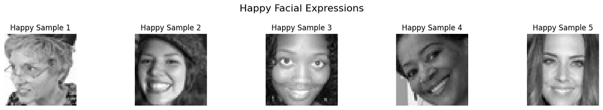

```python
# Path to happy emotion images
happy_path = '/content/drive/MyDrive/python_data_science/Facial_emotion_images/train/happy'
happy_images = os.listdir(happy_path)

print("Happy emotion - Total images: ",len(happy_images))

# Displaying first 5 happy images
plt.figure(figsize=(15, 2.5))
for i in range(5):
    img_path = os.path.join(happy_path, happy_images[i])
    img = Image.open(img_path)

    plt.subplot(1, 5, i+1)
    plt.imshow(img, cmap='gray' if img.mode == 'L' else None)
    plt.title(f'Happy Sample {i+1}')
    plt.axis('off')

plt.suptitle('Happy Facial Expressions', fontsize=16)
plt.tight_layout()
plt.show()
```

### **Sad**

```
Happy emotion - Total images:  3982
```

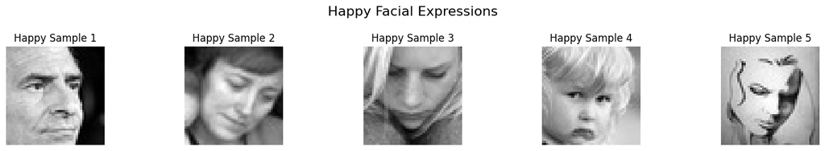

```python
# Path to sad emotion images
happy_path = '/content/drive/MyDrive/python_data_science/Facial_emotion_images/train/sad'
happy_images = os.listdir(happy_path)

print("Happy emotion - Total images: ",len(happy_images))

# Displaying first 5 sad images
plt.figure(figsize=(15, 2.5))
for i in range(5):
    img_path = os.path.join(happy_path, happy_images[i])
    img = Image.open(img_path)

    plt.subplot(1, 5, i+1)
    plt.imshow(img, cmap='gray' if img.mode == 'L' else None)
    plt.title(f'Happy Sample {i+1}')
    plt.axis('off')

plt.suptitle('Happy Facial Expressions', fontsize=16)
plt.tight_layout()
plt.show()
```

**Observations and Insights:__** 1.)People are usually not looking at the camera 2.)The lips are turned downwards. 3.)The eyes are also drooping a little and looking down 4.)The cheeks are flat with now visible lines

### **Neutral**

```
Happy emotion - Total images:  3978
```

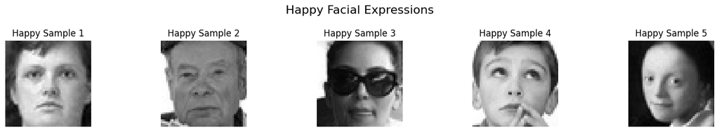

```python
# Path to neutral emotion images
happy_path = '/content/drive/MyDrive/python_data_science/Facial_emotion_images/train/neutral'
happy_images = os.listdir(happy_path)

print("Happy emotion - Total images: ",len(happy_images))

# Displaying first 5 neutral images
plt.figure(figsize=(15, 2.5))
for i in range(5):
    img_path = os.path.join(happy_path, happy_images[i])
    img = Image.open(img_path)

    plt.subplot(1, 5, i+1)
    plt.imshow(img, cmap='gray' if img.mode == 'L' else None)
    plt.title(f'Happy Sample {i+1}')
    plt.axis('off')

plt.suptitle('Happy Facial Expressions', fontsize=16)
plt.tight_layout()
plt.show()
```

**Observations and Insights:__** 1.)The lips look to be in a straight line 2.)The eyes are also in just a normal position 3.)The cheeks don't have any prominent line on them

### **Surprised**

```
Happy emotion - Total images:  3173
```

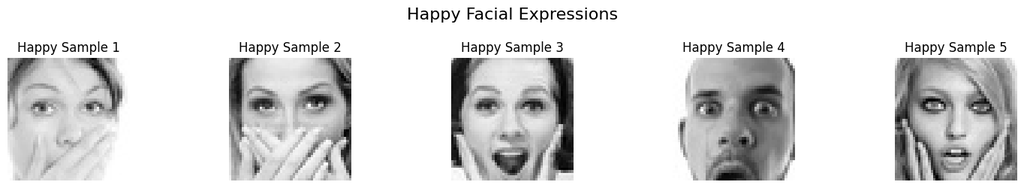

```python
# Path to surprise emotion images
happy_path = '/content/drive/MyDrive/python_data_science/Facial_emotion_images/train/surprise'
happy_images = os.listdir(happy_path)

print("Happy emotion - Total images: ",len(happy_images))

# Displaying first 5 surprised images
plt.figure(figsize=(15, 2.5))
for i in range(5):
    img_path = os.path.join(happy_path, happy_images[i])
    img = Image.open(img_path)

    plt.subplot(1, 5, i+1)
    plt.imshow(img, cmap='gray' if img.mode == 'L' else None)
    plt.title(f'Happy Sample {i+1}')
    plt.axis('off')

plt.suptitle('Happy Facial Expressions', fontsize=16)
plt.tight_layout()
plt.show()
```

**Observations and Insights:__** 1.)The mouth is wide open 2.)The eyes are also wide 3.)There is also hand on the face to show surprise. 4.)The eyebrows are raised

## **Checking Distribution of Classes**

```python
base_path = 'python_data_science/Facial_emotion_images/'
emotions = ['happy', 'sad', 'surprise', 'neutral']
splits = ['train', 'validation', 'test']

# Dictionary to store all counts
all_counts = {}
split_totals = {}
grand_total = 0

# Gathering all the data
for split in splits:
    split_path = os.path.join(base_path, split)
    split_total = 0
    all_counts[split] = {}

    for emotion in emotions:
        emotion_path = os.path.join(split_path, emotion)
        if os.path.exists(emotion_path):
            count = len(os.listdir(emotion_path))
            all_counts[split][emotion] = count
            split_total += count
        else:
            all_counts[split][emotion] = 0

    split_totals[split] = split_total
    grand_total += split_total

# Displaying class distribution for all classes
for split in splits:
    print(f"\n{split.upper()} SET:")
    print("-" * 40)

    split_total = split_totals[split]

    for emotion in emotions:
        count = all_counts[split][emotion]
        if split_total > 0:
            percentage = (count / split_total) * 100
            print(f"{emotion.capitalize()}: {count} images ({percentage:.1f}%)")
        else:
            print(f"{emotion.capitalize()}: {count} images")

    print(f"{'Total'}: {split_total} images")

# Percentage of data split between train,test and validation
print("-" * 40)
print(f"\nTotal dataset size: {grand_total} images")
print(f"\nData split percentages:")

for split in splits:
    split_total = split_totals[split]
    if grand_total > 0:
        split_percentage = (split_total / grand_total) * 100
        print(f"{split.capitalize()}: {split_total} images ({split_percentage:.1f}%)")
    else:
        print(f"{split.capitalize()}: {split_total} images")
```

```
TRAIN SET:
----------------------------------------
Happy: 3976 images (26.3%)
Sad: 3982 images (26.4%)
Surprise: 3173 images (21.0%)
Neutral: 3978 images (26.3%)
Total: 15109 images

VALIDATION SET:
----------------------------------------
Happy: 1825 images (36.7%)
Sad: 1139 images (22.9%)
Surprise: 797 images (16.0%)
Neutral: 1216 images (24.4%)
Total: 4977 images

TEST SET:
----------------------------------------
Happy: 32 images (25.0%)
Sad: 32 images (25.0%)
Surprise: 32 images (25.0%)
Neutral: 32 images (25.0%)
Total: 128 images
----------------------------------------

Total dataset size: 20214 images

Data split percentages:
Train: 15109 images (74.7%)
Validation: 4977 images (24.6%)
Test: 128 images (0.6%)
```

**Observations and Insights:__** 1.)We can see in train and test set, data is split equally between all 4 emotion almost 25% for each 2.)For validation set, there are more happy images when compared to rest which may cause issue in validation. 3.) The Trainin data is adequate at 74% but the split between the validation and test set could have been better as test set is only0.6 percent of the total data.

**Think About It:**

- Are the classes equally distributed? If not, do you think the imbalance is too high? Will it be a problem as we progress?
- Are there any Exploratory Data Analysis tasks that we can do here? Would they provide any meaningful insights?

## **Creating our Data Loaders**

In this section, we are creating data loaders that we will use as inputs to our Neural Network.

**You have two options for the color_mode. You can set it to color_mode = 'rgb' or color_mode = 'grayscale'. You will need to try out both and see for yourself which one gives better performance.**

GREYSCALE data loader

```python
# Image parameters
IMG_SIZE = (48, 48)
BATCH_SIZE = 32

# Creating grayscale data loaders
train_ds_gray = tf.keras.utils.image_dataset_from_directory(
    directory=f'{base_path}/train',
    labels='inferred',
    label_mode='categorical',
    class_names=['happy', 'sad', 'surprise', 'neutral'],
    color_mode='grayscale',
    batch_size=BATCH_SIZE,
    image_size=IMG_SIZE,
    shuffle=True,
    seed=42
)

validation_ds_gray = tf.keras.utils.image_dataset_from_directory(
    directory=f'{base_path}/validation',
    labels='inferred',
    label_mode='categorical',
    class_names=['happy', 'sad', 'surprise', 'neutral'],
    color_mode='grayscale',
    batch_size=BATCH_SIZE,
    image_size=IMG_SIZE,
    shuffle=False,
    seed=42
)

test_ds_gray = tf.keras.utils.image_dataset_from_directory(
    directory=f'{base_path}/test',
    labels='inferred',
    label_mode='categorical',
    class_names=['happy', 'sad', 'surprise', 'neutral'],
    color_mode='grayscale',
    batch_size=BATCH_SIZE,
    image_size=IMG_SIZE,
    shuffle=False,
    seed=42
)

print("Grayscale Data Loaders Created!")
print(f"Training batches: {len(train_ds_gray)}")
print(f"Validation batches: {len(validation_ds_gray)}")
print(f"Test batches: {len(test_ds_gray)}")

# Verifing input shape
for images, labels in train_ds_gray.take(1):
    print(f"Grayscale image shape: {images.shape}")
    print(f"Labels shape: {labels.shape}")
```

```
Found 15109 files belonging to 4 classes.
```

[output not shown]

```
Found 4977 files belonging to 4 classes.
Found 128 files belonging to 4 classes.
Grayscale Data Loaders Created!
Training batches: 473
Validation batches: 156
Test batches: 4
Grayscale image shape: (32, 48, 48, 1)
Labels shape: (32, 4)
```

RGB data loader

```python
# Creating RGB data loaders
train_ds_rgb = tf.keras.utils.image_dataset_from_directory(
    directory=f'{base_path}/train',
    labels='inferred',
    label_mode='categorical',
    class_names=['happy', 'sad', 'surprise', 'neutral'],
    color_mode='rgb',
    batch_size=BATCH_SIZE,
    image_size=IMG_SIZE,
    shuffle=True,
    seed=42
)

validation_ds_rgb = tf.keras.utils.image_dataset_from_directory(
    directory=f'{base_path}/validation',
    labels='inferred',
    label_mode='categorical',
    class_names=['happy', 'sad', 'surprise', 'neutral'],
    color_mode='rgb',
    batch_size=BATCH_SIZE,
    image_size=IMG_SIZE,
    shuffle=False,
    seed=42
)

test_ds_rgb = tf.keras.utils.image_dataset_from_directory(
    directory=f'{base_path}/test',
    labels='inferred',
    label_mode='categorical',
    class_names=['happy', 'sad', 'surprise', 'neutral'],
    color_mode='rgb',
    batch_size=BATCH_SIZE,
    image_size=IMG_SIZE,
    shuffle=False,
    seed=42
)

print("RGB Data Loaders Created!")
print(f"Training batches: {len(train_ds_rgb)}")
print(f"Validation batches: {len(validation_ds_rgb)}")
print(f"Test batches: {len(test_ds_rgb)}")

# Verify input shape
for images, labels in train_ds_rgb.take(1):
    print(f"RGB image shape: {images.shape}")
    print(f"Labels shape: {labels.shape}")
```

```
Found 15109 files belonging to 4 classes.
Found 4977 files belonging to 4 classes.
Found 128 files belonging to 4 classes.
RGB Data Loaders Created!
Training batches: 473
Validation batches: 156
Test batches: 4
RGB image shape: (32, 48, 48, 3)
Labels shape: (32, 4)
```

## **Model Building**

**Think About It:**

- Are Convolutional Neural Networks the right approach? Should we have gone with Artificial Neural Networks instead?
- What are the advantages of CNNs over ANNs and are they applicable here?

### **Creating the Base Neural Network**

```python
# Creating the base CNN model
def create_base_cnn(input_shape=(48, 48, 1), num_classes=4):
    model = Sequential([
        # Preprocessing layer and normalizing to [0,1]
        Rescaling(1./255, input_shape=input_shape),

        # First Convolutional Block
        Conv2D(32, (3, 3), activation='relu', padding='same', name='conv1'),
        BatchNormalization(name='bn1'),
        MaxPooling2D((2, 2), name='pool1'),
        Dropout(0.25, name='dropout1'),

        # Second Convolutional Block
        Conv2D(64, (3, 3), activation='relu', padding='same', name='conv2'),
        BatchNormalization(name='bn2'),
        MaxPooling2D((2, 2), name='pool2'),
        Dropout(0.25, name='dropout2'),

        # Third Convolutional Block
        Conv2D(128, (3, 3), activation='relu', padding='same', name='conv3'),
        BatchNormalization(name='bn3'),
        MaxPooling2D((2, 2), name='pool3'),
        Dropout(0.25, name='dropout3'),

        # Flatten and Dense layers
        Flatten(name='flatten'),
        Dense(512, activation='relu', name='dense1'),
        BatchNormalization(name='bn_dense'),
        Dropout(0.5, name='dropout_dense'),

        # Output layer
        Dense(num_classes, activation='softmax', name='output')
    ])

    return model

# Createing and compiling the model
base_cnn = create_base_cnn(input_shape=(48, 48, 1), num_classes=4)

# Displaying model architecture
base_cnn.summary()
```

```
Model: "sequential"
```

```
┏━━━━━━━━━━━━━━━━━━━━━━━━━━━━━━━━━┳━━━━━━━━━━━━━━━━━━━━━━━━┳━━━━━━━━━━━━━━━┓
┃ Layer (type)                    ┃ Output Shape           ┃       Param # ┃
┡━━━━━━━━━━━━━━━━━━━━━━━━━━━━━━━━━╇━━━━━━━━━━━━━━━━━━━━━━━━╇━━━━━━━━━━━━━━━┩
│ rescaling (Rescaling)           │ (None, 48, 48, 1)      │             0 │
├─────────────────────────────────┼────────────────────────┼───────────────┤
│ conv1 (Conv2D)                  │ (None, 48, 48, 32)     │           320 │
├─────────────────────────────────┼────────────────────────┼───────────────┤
│ bn1 (BatchNormalization)        │ (None, 48, 48, 32)     │           128 │
├─────────────────────────────────┼────────────────────────┼───────────────┤
│ pool1 (MaxPooling2D)            │ (None, 24, 24, 32)     │             0 │
├─────────────────────────────────┼────────────────────────┼───────────────┤
│ dropout1 (Dropout)              │ (None, 24, 24, 32)     │             0 │
├─────────────────────────────────┼────────────────────────┼───────────────┤
│ conv2 (Conv2D)                  │ (None, 24, 24, 64)     │        18,496 │
├─────────────────────────────────┼────────────────────────┼───────────────┤
│ bn2 (BatchNormalization)        │ (None, 24, 24, 64)     │           256 │
├─────────────────────────────────┼────────────────────────┼───────────────┤
│ pool2 (MaxPooling2D)            │ (None, 12, 12, 64)     │             0 │
├─────────────────────────────────┼────────────────────────┼───────────────┤
│ dropout2 (Dropout)              │ (None, 12, 12, 64)     │             0 │
├─────────────────────────────────┼────────────────────────┼───────────────┤
│ conv3 (Conv2D)                  │ (None, 12, 12, 128)    │        73,856 │
├─────────────────────────────────┼────────────────────────┼───────────────┤
│ bn3 (BatchNormalization)        │ (None, 12, 12, 128)    │           512 │
├─────────────────────────────────┼────────────────────────┼───────────────┤
│ pool3 (MaxPooling2D)            │ (None, 6, 6, 128)      │             0 │
├─────────────────────────────────┼────────────────────────┼───────────────┤
│ dropout3 (Dropout)              │ (None, 6, 6, 128)      │             0 │
├─────────────────────────────────┼────────────────────────┼───────────────┤
│ flatten (Flatten)               │ (None, 4608)           │             0 │
├─────────────────────────────────┼────────────────────────┼───────────────┤
│ dense1 (Dense)                  │ (None, 512)            │     2,359,808 │
├─────────────────────────────────┼────────────────────────┼───────────────┤
│ bn_dense (BatchNormalization)   │ (None, 512)            │         2,048 │
├─────────────────────────────────┼────────────────────────┼───────────────┤
│ dropout_dense (Dropout)         │ (None, 512)            │             0 │
├─────────────────────────────────┼────────────────────────┼───────────────┤
│ output (Dense)                  │ (None, 4)              │         2,052 │
└─────────────────────────────────┴────────────────────────┴───────────────┘
```

```
 Total params: 2,457,476 (9.37 MB)
```

```
 Trainable params: 2,456,004 (9.37 MB)
```

```
 Non-trainable params: 1,472 (5.75 KB)
```

### **Compiling and Training the Model with Grayscale data loader**

```
473/473 ━━━━━━━━━━━━━━━━━━━━ 140s 287ms/step - accuracy: 0.4466 - loss: 1.4135 - val_accuracy: 0.2688 - val_loss: 4.5522 - learning_rate: 0.0010
473/473 ━━━━━━━━━━━━━━━━━━━━ 90s 190ms/step - accuracy: 0.5560 - loss: 1.0376 - val_accuracy: 0.6430 - val_loss: 0.9040 - learning_rate: 0.0010
473/473 ━━━━━━━━━━━━━━━━━━━━ 88s 187ms/step - accuracy: 0.6118 - loss: 0.9241 - val_accuracy: 0.5365 - val_loss: 1.1763 - learning_rate: 0.0010
473/473 ━━━━━━━━━━━━━━━━━━━━ 89s 188ms/step - accuracy: 0.6353 - loss: 0.8670 - val_accuracy: 0.6721 - val_loss: 0.8094 - learning_rate: 0.0010
473/473 ━━━━━━━━━━━━━━━━━━━━ 90s 190ms/step - accuracy: 0.6556 - loss: 0.8264 - val_accuracy: 0.5489 - val_loss: 1.0955 - learning_rate: 0.0010
473/473 ━━━━━━━━━━━━━━━━━━━━ 93s 196ms/step - accuracy: 0.6669 - loss: 0.7974 - val_accuracy: 0.6510 - val_loss: 0.8643 - learning_rate: 0.0010
473/473 ━━━━━━━━━━━━━━━━━━━━ 0s 183ms/step - accuracy: 0.6868 - loss: 0.7576
Epoch 7: ReduceLROnPlateau reducing learning rate to 0.0005000000237487257.
473/473 ━━━━━━━━━━━━━━━━━━━━ 92s 194ms/step - accuracy: 0.6888 - loss: 0.7622 - val_accuracy: 0.6450 - val_loss: 0.8628 - learning_rate: 0.0010
473/473 ━━━━━━━━━━━━━━━━━━━━ 92s 194ms/step - accuracy: 0.7179 - loss: 0.6956 - val_accuracy: 0.7083 - val_loss: 0.7395 - learning_rate: 5.0000e-04
473/473 ━━━━━━━━━━━━━━━━━━━━ 90s 191ms/step - accuracy: 0.7221 - loss: 0.6834 - val_accuracy: 0.7306 - val_loss: 0.6940 - learning_rate: 5.0000e-04
473/473 ━━━━━━━━━━━━━━━━━━━━ 94s 198ms/step - accuracy: 0.7453 - loss: 0.6339 - val_accuracy: 0.7173 - val_loss: 0.7415 - learning_rate: 5.0000e-04
473/473 ━━━━━━━━━━━━━━━━━━━━ 90s 190ms/step - accuracy: 0.7423 - loss: 0.6268 - val_accuracy: 0.7109 - val_loss: 0.7780 - learning_rate: 5.0000e-04
473/473 ━━━━━━━━━━━━━━━━━━━━ 0s 174ms/step - accuracy: 0.7565 - loss: 0.6025
Epoch 12: ReduceLROnPlateau reducing learning rate to 0.0002500000118743628.
473/473 ━━━━━━━━━━━━━━━━━━━━ 87s 184ms/step - accuracy: 0.7576 - loss: 0.6015 - val_accuracy: 0.6924 - val_loss: 0.8410 - learning_rate: 5.0000e-04
473/473 ━━━━━━━━━━━━━━━━━━━━ 69s 145ms/step - accuracy: 0.7766 - loss: 0.5577 - val_accuracy: 0.7438 - val_loss: 0.6762 - learning_rate: 2.5000e-04
473/473 ━━━━━━━━━━━━━━━━━━━━ 65s 136ms/step - accuracy: 0.7901 - loss: 0.5301 - val_accuracy: 0.7352 - val_loss: 0.6980 - learning_rate: 2.5000e-04
473/473 ━━━━━━━━━━━━━━━━━━━━ 63s 134ms/step - accuracy: 0.7958 - loss: 0.5119 - val_accuracy: 0.7436 - val_loss: 0.6890 - learning_rate: 2.5000e-04
473/473 ━━━━━━━━━━━━━━━━━━━━ 0s 128ms/step - accuracy: 0.8118 - loss: 0.4843
Epoch 16: ReduceLROnPlateau reducing learning rate to 0.0001250000059371814.
473/473 ━━━━━━━━━━━━━━━━━━━━ 64s 135ms/step - accuracy: 0.8074 - loss: 0.4891 - val_accuracy: 0.7444 - val_loss: 0.6872 - learning_rate: 2.5000e-04
473/473 ━━━━━━━━━━━━━━━━━━━━ 65s 136ms/step - accuracy: 0.8155 - loss: 0.4621 - val_accuracy: 0.7422 - val_loss: 0.6892 - learning_rate: 1.2500e-04
473/473 ━━━━━━━━━━━━━━━━━━━━ 66s 139ms/step - accuracy: 0.8267 - loss: 0.4470 - val_accuracy: 0.7422 - val_loss: 0.7018 - learning_rate: 1.2500e-04
473/473 ━━━━━━━━━━━━━━━━━━━━ 0s 129ms/step - accuracy: 0.8259 - loss: 0.4420
Epoch 19: ReduceLROnPlateau reducing learning rate to 6.25000029685907e-05.
473/473 ━━━━━━━━━━━━━━━━━━━━ 64s 136ms/step - accuracy: 0.8282 - loss: 0.4414 - val_accuracy: 0.7511 - val_loss: 0.7015 - learning_rate: 1.2500e-04
473/473 ━━━━━━━━━━━━━━━━━━━━ 64s 135ms/step - accuracy: 0.8355 - loss: 0.4200 - val_accuracy: 0.7531 - val_loss: 0.7074 - learning_rate: 6.2500e-05
Restoring model weights from the end of the best epoch: 20.
```

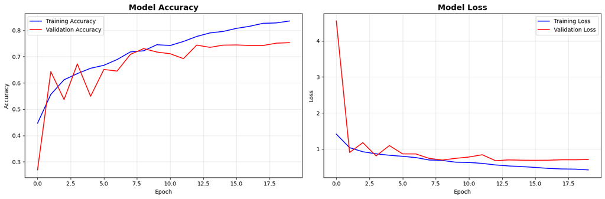

```
Final Training Accuracy: 0.8355
Final Validation Accuracy: 0.7531
```

```python
# Compiling the model
base_cnn.compile(
    optimizer='adam',
    loss='categorical_crossentropy',
    metrics=['accuracy']
)

# Training parameters
EPOCHS = 20

# Defining callbacks for better training
callbacks = [
    tf.keras.callbacks.EarlyStopping(
        monitor='val_accuracy',
        patience=5,
        restore_best_weights=True,
        verbose=1
    ),
    tf.keras.callbacks.ReduceLROnPlateau(
        monitor='val_loss',
        factor=0.5,
        patience=3,
        min_lr=1e-7,
        verbose=1
    )
]

# Training the model using grayscale data loader
history = base_cnn.fit(
    train_ds_gray,
    validation_data=validation_ds_gray,
    epochs=EPOCHS,
    callbacks=callbacks,
    verbose=1
)


# Plotting training history
import matplotlib.pyplot as plt

fig, (ax1, ax2) = plt.subplots(1, 2, figsize=(15, 5))

# Plotting accuracy
ax1.plot(history.history['accuracy'], label='Training Accuracy', color='blue')
ax1.plot(history.history['val_accuracy'], label='Validation Accuracy', color='red')
ax1.set_title('Model Accuracy', fontsize=14, fontweight='bold')
ax1.set_xlabel('Epoch')
ax1.set_ylabel('Accuracy')
ax1.legend()
ax1.grid(True, alpha=0.3)

# Plotting loss
ax2.plot(history.history['loss'], label='Training Loss', color='blue')
ax2.plot(history.history['val_loss'], label='Validation Loss', color='red')
ax2.set_title('Model Loss', fontsize=14, fontweight='bold')
ax2.set_xlabel('Epoch')
ax2.set_ylabel('Loss')
ax2.legend()
ax2.grid(True, alpha=0.3)

plt.tight_layout()
plt.show()

# Printing final metrics
final_train_acc = history.history['accuracy'][-1]
final_val_acc = history.history['val_accuracy'][-1]
print(f"Final Training Accuracy: {final_train_acc:.4f}")
print(f"Final Validation Accuracy: {final_val_acc:.4f}")
```

### **Evaluating the Model on the Test Set still using grayscale loader**

```python
# Evaluating the Base CNN model on test set
print("Evaluating Base CNN on test set...")
print("="*50)

# Getting test loss and accuracy
test_loss, test_accuracy = base_cnn.evaluate(test_ds_gray, verbose=1)

print(f"\nBASE CNN TEST RESULTS:")
print(f"{'='*30}")
print(f"Test Loss: {test_loss:.4f}")
print(f"Test Accuracy: {test_accuracy:.4f} ({test_accuracy*100:.2f}%)")

# Gettin detailed predictions for further analysis
print("\nGenerating predictions...")
test_predictions = base_cnn.predict(test_ds_gray)
predicted_classes = tf.argmax(test_predictions, axis=1)

# Getting true labels from test dataset
true_labels = []
for images, labels in test_ds_gray:
    true_labels.extend(tf.argmax(labels, axis=1).numpy())

# Converting to tensor and ensuring same data type
true_labels = tf.cast(tf.constant(true_labels), tf.int64)
predicted_classes = tf.cast(predicted_classes, tf.int64)

print(f"Total test samples: {len(true_labels)}")

# Calculating per-class accuracy
class_names = ['happy', 'sad', 'surprise', 'neutral']
print(f"\nPer-class performance:")
print("-" * 40)

for i, class_name in enumerate(class_names):
    class_mask = (true_labels == i)
    class_predictions = predicted_classes[class_mask]
    class_true = true_labels[class_mask]

    if len(class_true) > 0:
        class_accuracy = tf.reduce_mean(tf.cast(class_predictions == class_true, tf.float32))
        print(f"{class_name.capitalize()}: {class_accuracy:.4f} ({class_accuracy*100:.2f}%) - {len(class_true)} samples")
    else:
        print(f"{class_name.capitalize()}: No samples found")

# Additional metrics
from sklearn.metrics import classification_report
print(f"\nDetailed Classification Report:")
print("-" * 50)
print(classification_report(true_labels.numpy(), predicted_classes.numpy(),
                          target_names=class_names, digits=4))
```

```
Evaluating Base CNN on test set...
==================================================
4/4 ━━━━━━━━━━━━━━━━━━━━ 0s 28ms/step - accuracy: 0.7734 - loss: 0.6332

BASE CNN TEST RESULTS:
==============================
Test Loss: 0.6332
Test Accuracy: 0.7734 (77.34%)

Generating predictions...
4/4 ━━━━━━━━━━━━━━━━━━━━ 0s 25ms/step
Total test samples: 128

Per-class performance:
----------------------------------------
Happy: 0.8125 (81.25%) - 32 samples
Sad: 0.6562 (65.62%) - 32 samples
Surprise: 0.8750 (87.50%) - 32 samples
Neutral: 0.7500 (75.00%) - 32 samples

Detailed Classification Report:
--------------------------------------------------
              precision    recall  f1-score   support

       happy     0.8387    0.8125    0.8254        32
         sad     0.6774    0.6562    0.6667        32
    surprise     1.0000    0.8750    0.9333        32
     neutral     0.6316    0.7500    0.6857        32

    accuracy                         0.7734       128
   macro avg     0.7869    0.7734    0.7778       128
weighted avg     0.7869    0.7734    0.7778       128
```

### **Creating the Base Neural Network for RGB loader**

```python
# Creating the base CNN model for RGB images (48x48x3)
def create_base_cnn_rgb(input_shape=(48, 48, 3), num_classes=4):
    model = Sequential([
        # Preprocessing layer (normalize to [0,1])
        Rescaling(1./255, input_shape=input_shape),

        # First Convolutional Block
        Conv2D(32, (3, 3), activation='relu', padding='same', name='conv1'),
        BatchNormalization(name='bn1'),
        MaxPooling2D((2, 2), name='pool1'),
        Dropout(0.25, name='dropout1'),

        # Second Convolutional Block
        Conv2D(64, (3, 3), activation='relu', padding='same', name='conv2'),
        BatchNormalization(name='bn2'),
        MaxPooling2D((2, 2), name='pool2'),
        Dropout(0.25, name='dropout2'),

        # Third Convolutional Block
        Conv2D(128, (3, 3), activation='relu', padding='same', name='conv3'),
        BatchNormalization(name='bn3'),
        MaxPooling2D((2, 2), name='pool3'),
        Dropout(0.25, name='dropout3'),

        # Flatten and Dense layers
        Flatten(name='flatten'),
        Dense(512, activation='relu', name='dense1'),
        BatchNormalization(name='bn_dense'),
        Dropout(0.5, name='dropout_dense'),

        # Output layer
        Dense(num_classes, activation='softmax', name='output')
    ])

    return model

# Create and compile the RGB model
base_cnn_rgb = create_base_cnn_rgb(input_shape=(48, 48, 3), num_classes=4)

# Compile the model
base_cnn_rgb.compile(
    optimizer='adam',
    loss='categorical_crossentropy',
    metrics=['accuracy']
)

# Display model architecture
print("BASE CNN FOR RGB IMAGES")
print("="*50)
base_cnn_rgb.summary()
```

```
BASE CNN FOR RGB IMAGES
==================================================
```

```
Model: "sequential_3"
```

```
┏━━━━━━━━━━━━━━━━━━━━━━━━━━━━━━━━━┳━━━━━━━━━━━━━━━━━━━━━━━━┳━━━━━━━━━━━━━━━┓
┃ Layer (type)                    ┃ Output Shape           ┃       Param # ┃
┡━━━━━━━━━━━━━━━━━━━━━━━━━━━━━━━━━╇━━━━━━━━━━━━━━━━━━━━━━━━╇━━━━━━━━━━━━━━━┩
│ rescaling_3 (Rescaling)         │ (None, 48, 48, 3)      │             0 │
├─────────────────────────────────┼────────────────────────┼───────────────┤
│ conv1 (Conv2D)                  │ (None, 48, 48, 32)     │           896 │
├─────────────────────────────────┼────────────────────────┼───────────────┤
│ bn1 (BatchNormalization)        │ (None, 48, 48, 32)     │           128 │
├─────────────────────────────────┼────────────────────────┼───────────────┤
│ pool1 (MaxPooling2D)            │ (None, 24, 24, 32)     │             0 │
├─────────────────────────────────┼────────────────────────┼───────────────┤
│ dropout1 (Dropout)              │ (None, 24, 24, 32)     │             0 │
├─────────────────────────────────┼────────────────────────┼───────────────┤
│ conv2 (Conv2D)                  │ (None, 24, 24, 64)     │        18,496 │
├─────────────────────────────────┼────────────────────────┼───────────────┤
│ bn2 (BatchNormalization)        │ (None, 24, 24, 64)     │           256 │
├─────────────────────────────────┼────────────────────────┼───────────────┤
│ pool2 (MaxPooling2D)            │ (None, 12, 12, 64)     │             0 │
├─────────────────────────────────┼────────────────────────┼───────────────┤
│ dropout2 (Dropout)              │ (None, 12, 12, 64)     │             0 │
├─────────────────────────────────┼────────────────────────┼───────────────┤
│ conv3 (Conv2D)                  │ (None, 12, 12, 128)    │        73,856 │
├─────────────────────────────────┼────────────────────────┼───────────────┤
│ bn3 (BatchNormalization)        │ (None, 12, 12, 128)    │           512 │
├─────────────────────────────────┼────────────────────────┼───────────────┤
│ pool3 (MaxPooling2D)            │ (None, 6, 6, 128)      │             0 │
├─────────────────────────────────┼────────────────────────┼───────────────┤
│ dropout3 (Dropout)              │ (None, 6, 6, 128)      │             0 │
├─────────────────────────────────┼────────────────────────┼───────────────┤
│ flatten (Flatten)               │ (None, 4608)           │             0 │
├─────────────────────────────────┼────────────────────────┼───────────────┤
│ dense1 (Dense)                  │ (None, 512)            │     2,359,808 │
├─────────────────────────────────┼────────────────────────┼───────────────┤
│ bn_dense (BatchNormalization)   │ (None, 512)            │         2,048 │
├─────────────────────────────────┼────────────────────────┼───────────────┤
│ dropout_dense (Dropout)         │ (None, 512)            │             0 │
├─────────────────────────────────┼────────────────────────┼───────────────┤
│ output (Dense)                  │ (None, 4)              │         2,052 │
└─────────────────────────────────┴────────────────────────┴───────────────┘
```

```
 Total params: 2,458,052 (9.38 MB)
```

```
 Trainable params: 2,456,580 (9.37 MB)
```

```
 Non-trainable params: 1,472 (5.75 KB)
```

### **Compiling and Training the Model with rgb data loader**

[output not shown]

```
  7/473 ━━━━━━━━━━━━━━━━━━━━ 11s 25ms/step - accuracy: 0.1779 - loss: 2.8130
```

```
I0000 00:00:1755095345.672098     106 device_compiler.h:188] Compiled cluster using XLA!  This line is logged at most once for the lifetime of the process.
```

```
473/473 ━━━━━━━━━━━━━━━━━━━━ 45s 72ms/step - accuracy: 0.4010 - loss: 1.7019 - val_accuracy: 0.4276 - val_loss: 1.2995 - learning_rate: 0.0010
473/473 ━━━━━━━━━━━━━━━━━━━━ 4s 8ms/step - accuracy: 0.5545 - loss: 1.0554 - val_accuracy: 0.5682 - val_loss: 1.1418 - learning_rate: 0.0010
473/473 ━━━━━━━━━━━━━━━━━━━━ 4s 8ms/step - accuracy: 0.6067 - loss: 0.9273 - val_accuracy: 0.6438 - val_loss: 0.8601 - learning_rate: 0.0010
473/473 ━━━━━━━━━━━━━━━━━━━━ 4s 8ms/step - accuracy: 0.6358 - loss: 0.8668 - val_accuracy: 0.6466 - val_loss: 0.8352 - learning_rate: 0.0010
473/473 ━━━━━━━━━━━━━━━━━━━━ 4s 8ms/step - accuracy: 0.6560 - loss: 0.8356 - val_accuracy: 0.6207 - val_loss: 0.9299 - learning_rate: 0.0010
473/473 ━━━━━━━━━━━━━━━━━━━━ 4s 8ms/step - accuracy: 0.6745 - loss: 0.7894 - val_accuracy: 0.6677 - val_loss: 0.8395 - learning_rate: 0.0010
473/473 ━━━━━━━━━━━━━━━━━━━━ 4s 8ms/step - accuracy: 0.6841 - loss: 0.7662 - val_accuracy: 0.6622 - val_loss: 0.8171 - learning_rate: 0.0010
473/473 ━━━━━━━━━━━━━━━━━━━━ 4s 8ms/step - accuracy: 0.6917 - loss: 0.7575 - val_accuracy: 0.5941 - val_loss: 0.9594 - learning_rate: 0.0010
473/473 ━━━━━━━━━━━━━━━━━━━━ 4s 8ms/step - accuracy: 0.6862 - loss: 0.7579 - val_accuracy: 0.5600 - val_loss: 1.2599 - learning_rate: 0.0010
473/473 ━━━━━━━━━━━━━━━━━━━━ 4s 8ms/step - accuracy: 0.6997 - loss: 0.7509 - val_accuracy: 0.7040 - val_loss: 0.7508 - learning_rate: 0.0010
473/473 ━━━━━━━━━━━━━━━━━━━━ 4s 8ms/step - accuracy: 0.7179 - loss: 0.7024 - val_accuracy: 0.7077 - val_loss: 0.7476 - learning_rate: 0.0010
473/473 ━━━━━━━━━━━━━━━━━━━━ 4s 9ms/step - accuracy: 0.7234 - loss: 0.6789 - val_accuracy: 0.7083 - val_loss: 0.7540 - learning_rate: 0.0010
473/473 ━━━━━━━━━━━━━━━━━━━━ 4s 9ms/step - accuracy: 0.7297 - loss: 0.6674 - val_accuracy: 0.7095 - val_loss: 0.7371 - learning_rate: 0.0010
473/473 ━━━━━━━━━━━━━━━━━━━━ 4s 9ms/step - accuracy: 0.7468 - loss: 0.6308 - val_accuracy: 0.6978 - val_loss: 0.7897 - learning_rate: 0.0010
473/473 ━━━━━━━━━━━━━━━━━━━━ 4s 9ms/step - accuracy: 0.7452 - loss: 0.6335 - val_accuracy: 0.5554 - val_loss: 1.7151 - learning_rate: 0.0010
473/473 ━━━━━━━━━━━━━━━━━━━━ 4s 8ms/step - accuracy: 0.7458 - loss: 0.6314 - val_accuracy: 0.7125 - val_loss: 0.7362 - learning_rate: 0.0010
473/473 ━━━━━━━━━━━━━━━━━━━━ 4s 8ms/step - accuracy: 0.7703 - loss: 0.5793 - val_accuracy: 0.6803 - val_loss: 1.0349 - learning_rate: 0.0010
473/473 ━━━━━━━━━━━━━━━━━━━━ 4s 8ms/step - accuracy: 0.7657 - loss: 0.5822 - val_accuracy: 0.7237 - val_loss: 0.7401 - learning_rate: 0.0010
473/473 ━━━━━━━━━━━━━━━━━━━━ 0s 6ms/step - accuracy: 0.7817 - loss: 0.5451
Epoch 19: ReduceLROnPlateau reducing learning rate to 0.0005000000237487257.
473/473 ━━━━━━━━━━━━━━━━━━━━ 4s 8ms/step - accuracy: 0.7817 - loss: 0.5452 - val_accuracy: 0.6508 - val_loss: 1.0051 - learning_rate: 0.0010
473/473 ━━━━━━━━━━━━━━━━━━━━ 4s 8ms/step - accuracy: 0.7821 - loss: 0.5460 - val_accuracy: 0.7342 - val_loss: 0.7030 - learning_rate: 5.0000e-04
Restoring model weights from the end of the best epoch: 20.
```

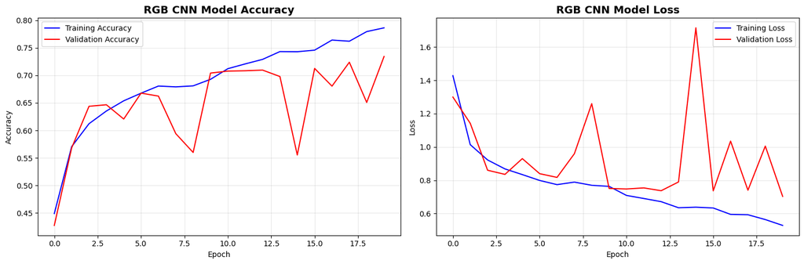

```
Final Training Accuracy: 0.7862
Final Validation Accuracy: 0.7342
```

```python
# Training parameters
EPOCHS = 20

# Define callbacks for better training
callbacks = [
    tf.keras.callbacks.EarlyStopping(
        monitor='val_accuracy',
        patience=5,
        restore_best_weights=True,
        verbose=1
    ),
    tf.keras.callbacks.ReduceLROnPlateau(
        monitor='val_loss',
        factor=0.5,
        patience=3,
        min_lr=1e-7,
        verbose=1
    )
]

# Training the model using RGB data loader
history_rgb = base_cnn_rgb.fit(
    train_ds_rgb,
    validation_data=validation_ds_rgb,
    epochs=EPOCHS,
    callbacks=callbacks,
    verbose=1
)

# Plotting training history
import matplotlib.pyplot as plt

fig, (ax1, ax2) = plt.subplots(1, 2, figsize=(15, 5))

# Plotting accuracy
ax1.plot(history_rgb.history['accuracy'], label='Training Accuracy', color='blue')
ax1.plot(history_rgb.history['val_accuracy'], label='Validation Accuracy', color='red')
ax1.set_title('RGB CNN Model Accuracy', fontsize=14, fontweight='bold')
ax1.set_xlabel('Epoch')
ax1.set_ylabel('Accuracy')
ax1.legend()
ax1.grid(True, alpha=0.3)

# Plotting loss
ax2.plot(history_rgb.history['loss'], label='Training Loss', color='blue')
ax2.plot(history_rgb.history['val_loss'], label='Validation Loss', color='red')
ax2.set_title('RGB CNN Model Loss', fontsize=14, fontweight='bold')
ax2.set_xlabel('Epoch')
ax2.set_ylabel('Loss')
ax2.legend()
ax2.grid(True, alpha=0.3)

plt.tight_layout()
plt.show()

# Print final metrics
final_train_acc = history_rgb.history['accuracy'][-1]
final_val_acc = history_rgb.history['val_accuracy'][-1]
print(f"Final Training Accuracy: {final_train_acc:.4f}")
print(f"Final Validation Accuracy: {final_val_acc:.4f}")
```

### **Evaluating the Model on the Test Set still using rgb loader**

```python
# Evaluate RGB Base CNN on test set
print("Evaluating RGB Base CNN on test set...")
print("="*60)
test_loss_rgb, test_accuracy_rgb = base_cnn_rgb.evaluate(test_ds_rgb, verbose=1)
print(f"\nRGB BASE CNN TEST RESULTS:")
print(f"Test Loss: {test_loss_rgb:.4f}")
print(f"Test Accuracy: {test_accuracy_rgb:.4f} ({test_accuracy_rgb*100:.2f}%)")

# Generate RGB Base CNN predictions for detailed analysis
test_predictions_rgb = base_cnn_rgb.predict(test_ds_rgb)
predicted_classes_rgb = tf.argmax(test_predictions_rgb, axis=1)

# Get true labels for RGB data
true_labels_rgb = []
for images, labels in test_ds_rgb:
    true_labels_rgb.extend(tf.argmax(labels, axis=1).numpy())

true_labels_rgb = tf.cast(tf.constant(true_labels_rgb), tf.int64)
predicted_classes_rgb = tf.cast(predicted_classes_rgb, tf.int64)

# Per-class accuracy for RGB Base CNN
print(f"\nRGB BASE CNN Per-class performance:")
print("-" * 45)
class_names = ['happy', 'sad', 'surprise', 'neutral']
for i, class_name in enumerate(class_names):
    class_mask = (true_labels_rgb == i)
    class_predictions = predicted_classes_rgb[class_mask]
    class_true = true_labels_rgb[class_mask]

    if len(class_true) > 0:
        class_accuracy = tf.reduce_mean(tf.cast(class_predictions == class_true, tf.float32))
        print(f"{class_name.capitalize()}: {class_accuracy:.4f} ({class_accuracy*100:.2f}%)")

# Additional metrics
from sklearn.metrics import classification_report, confusion_matrix
print(f"\nDetailed Classification Report:")
print("-" * 55)
print(classification_report(true_labels_rgb.numpy(), predicted_classes_rgb.numpy(),
                          target_names=class_names, digits=4))

# Summary of model performance
print(f"\n{'='*60}")
print("RGB BASE CNN PERFORMANCE SUMMARY")
print(f"{'='*60}")
print(f"Architecture: RGB Base CNN with 4 Conv Blocks")
print(f"Input: RGB images (48x48x3)")
print(f"Test Accuracy: {test_accuracy_rgb:.4f} ({test_accuracy_rgb*100:.2f}%)")
print(f"Parameters: {base_cnn_rgb.count_params():,}")
print(f"Training: RGB Base CNN trained epochs")
```

```
Evaluating RGB Base CNN on test set...
============================================================
4/4 ━━━━━━━━━━━━━━━━━━━━ 0s 57ms/step - accuracy: 0.7750 - loss: 0.6020

RGB BASE CNN TEST RESULTS:
Test Loss: 0.6662
Test Accuracy: 0.7422 (74.22%)
4/4 ━━━━━━━━━━━━━━━━━━━━ 1s 6ms/step

RGB BASE CNN Per-class performance:
---------------------------------------------
Happy: 0.8438 (84.38%)
Sad: 0.6875 (68.75%)
Surprise: 0.8125 (81.25%)
Neutral: 0.6250 (62.50%)

Detailed Classification Report:
-------------------------------------------------------
              precision    recall  f1-score   support

       happy     0.7941    0.8438    0.8182        32
         sad     0.6471    0.6875    0.6667        32
    surprise     1.0000    0.8125    0.8966        32
     neutral     0.5882    0.6250    0.6061        32

    accuracy                         0.7422       128
   macro avg     0.7574    0.7422    0.7469       128
weighted avg     0.7574    0.7422    0.7469       128


============================================================
RGB BASE CNN PERFORMANCE SUMMARY
============================================================
Architecture: RGB Base CNN with 4 Conv Blocks
Input: RGB images (48x48x3)
Test Accuracy: 0.7422 (74.22%)
Parameters: 2,458,052
Training: RGB Base CNN trained epochs
```

### **Creating the second Convolutional Neural Network for Grayscale Data loader**

- Try out a slightly larger architecture

```python
# creating second CNN model with larger architecture
def create_second_cnn(input_shape=(48, 48, 1), num_classes=4):
    model = Sequential([
        # Preprocessing layer and normalizing to [0,1]
        Rescaling(1./255, input_shape=input_shape),

        # First Convolutional Block
        Conv2D(64, (3, 3), activation='relu', padding='same', name='conv1'),
        BatchNormalization(name='bn1'),
        Conv2D(64, (3, 3), activation='relu', padding='same', name='conv1_2'),
        MaxPooling2D((2, 2), name='pool1'),
        Dropout(0.25, name='dropout1'),

        # Second Convolutional Block
        Conv2D(128, (3, 3), activation='relu', padding='same', name='conv2'),
        BatchNormalization(name='bn2'),
        Conv2D(128, (3, 3), activation='relu', padding='same', name='conv2_2'),
        MaxPooling2D((2, 2), name='pool2'),
        Dropout(0.25, name='dropout2'),

        # Third Convolutional Block
        Conv2D(256, (3, 3), activation='relu', padding='same', name='conv3'),
        BatchNormalization(name='bn3'),
        Conv2D(256, (3, 3), activation='relu', padding='same', name='conv3_2'),
        MaxPooling2D((2, 2), name='pool3'),
        Dropout(0.25, name='dropout3'),

        # Fourth Convolutional Block (Additional layer)
        Conv2D(512, (3, 3), activation='relu', padding='same', name='conv4'),
        BatchNormalization(name='bn4'),
        MaxPooling2D((2, 2), name='pool4'),
        Dropout(0.3, name='dropout4'),

        # Flatten and Dense layers
        Flatten(name='flatten'),
        Dense(1024, activation='relu', name='dense1'),
        BatchNormalization(name='bn_dense1'),
        Dropout(0.5, name='dropout_dense1'),

        Dense(512, activation='relu', name='dense2'),
        BatchNormalization(name='bn_dense2'),
        Dropout(0.5, name='dropout_dense2'),

        # Output layer
        Dense(num_classes, activation='softmax', name='output')
    ])

    return model

# Creating and compiling the second model
second_cnn = create_second_cnn(input_shape=(48, 48, 1), num_classes=4)

# Displaying model architecture
print("SECOND CNN - LARGER ARCHITECTURE")
print("="*50)
second_cnn.summary()
```

```
SECOND CNN - LARGER ARCHITECTURE
==================================================
```

```
Model: "sequential_1"
```

```
┏━━━━━━━━━━━━━━━━━━━━━━━━━━━━━━━━━━━━━━┳━━━━━━━━━━━━━━━━━━━━━━━━━━━━━┳━━━━━━━━━━━━━━━━━┓
┃ Layer (type)                         ┃ Output Shape                ┃         Param # ┃
┡━━━━━━━━━━━━━━━━━━━━━━━━━━━━━━━━━━━━━━╇━━━━━━━━━━━━━━━━━━━━━━━━━━━━━╇━━━━━━━━━━━━━━━━━┩
│ rescaling_1 (Rescaling)              │ (None, 48, 48, 1)           │               0 │
├──────────────────────────────────────┼─────────────────────────────┼─────────────────┤
│ conv1 (Conv2D)                       │ (None, 48, 48, 64)          │             640 │
├──────────────────────────────────────┼─────────────────────────────┼─────────────────┤
│ bn1 (BatchNormalization)             │ (None, 48, 48, 64)          │             256 │
├──────────────────────────────────────┼─────────────────────────────┼─────────────────┤
│ conv1_2 (Conv2D)                     │ (None, 48, 48, 64)          │          36,928 │
├──────────────────────────────────────┼─────────────────────────────┼─────────────────┤
│ pool1 (MaxPooling2D)                 │ (None, 24, 24, 64)          │               0 │
├──────────────────────────────────────┼─────────────────────────────┼─────────────────┤
│ dropout1 (Dropout)                   │ (None, 24, 24, 64)          │               0 │
├──────────────────────────────────────┼─────────────────────────────┼─────────────────┤
│ conv2 (Conv2D)                       │ (None, 24, 24, 128)         │          73,856 │
├──────────────────────────────────────┼─────────────────────────────┼─────────────────┤
│ bn2 (BatchNormalization)             │ (None, 24, 24, 128)         │             512 │
├──────────────────────────────────────┼─────────────────────────────┼─────────────────┤
│ conv2_2 (Conv2D)                     │ (None, 24, 24, 128)         │         147,584 │
├──────────────────────────────────────┼─────────────────────────────┼─────────────────┤
│ pool2 (MaxPooling2D)                 │ (None, 12, 12, 128)         │               0 │
├──────────────────────────────────────┼─────────────────────────────┼─────────────────┤
│ dropout2 (Dropout)                   │ (None, 12, 12, 128)         │               0 │
├──────────────────────────────────────┼─────────────────────────────┼─────────────────┤
│ conv3 (Conv2D)                       │ (None, 12, 12, 256)         │         295,168 │
├──────────────────────────────────────┼─────────────────────────────┼─────────────────┤
│ bn3 (BatchNormalization)             │ (None, 12, 12, 256)         │           1,024 │
├──────────────────────────────────────┼─────────────────────────────┼─────────────────┤
│ conv3_2 (Conv2D)                     │ (None, 12, 12, 256)         │         590,080 │
├──────────────────────────────────────┼─────────────────────────────┼─────────────────┤
│ pool3 (MaxPooling2D)                 │ (None, 6, 6, 256)           │               0 │
├──────────────────────────────────────┼─────────────────────────────┼─────────────────┤
│ dropout3 (Dropout)                   │ (None, 6, 6, 256)           │               0 │
├──────────────────────────────────────┼─────────────────────────────┼─────────────────┤
│ conv4 (Conv2D)                       │ (None, 6, 6, 512)           │       1,180,160 │
├──────────────────────────────────────┼─────────────────────────────┼─────────────────┤
│ bn4 (BatchNormalization)             │ (None, 6, 6, 512)           │           2,048 │
├──────────────────────────────────────┼─────────────────────────────┼─────────────────┤
│ pool4 (MaxPooling2D)                 │ (None, 3, 3, 512)           │               0 │
├──────────────────────────────────────┼─────────────────────────────┼─────────────────┤
│ dropout4 (Dropout)                   │ (None, 3, 3, 512)           │               0 │
├──────────────────────────────────────┼─────────────────────────────┼─────────────────┤
│ flatten (Flatten)                    │ (None, 4608)                │               0 │
├──────────────────────────────────────┼─────────────────────────────┼─────────────────┤
│ dense1 (Dense)                       │ (None, 1024)                │       4,719,616 │
├──────────────────────────────────────┼─────────────────────────────┼─────────────────┤
│ bn_dense1 (BatchNormalization)       │ (None, 1024)                │           4,096 │
├──────────────────────────────────────┼─────────────────────────────┼─────────────────┤
│ dropout_dense1 (Dropout)             │ (None, 1024)                │               0 │
├──────────────────────────────────────┼─────────────────────────────┼─────────────────┤
│ dense2 (Dense)                       │ (None, 512)                 │         524,800 │
├──────────────────────────────────────┼─────────────────────────────┼─────────────────┤
│ bn_dense2 (BatchNormalization)       │ (None, 512)                 │           2,048 │
├──────────────────────────────────────┼─────────────────────────────┼─────────────────┤
│ dropout_dense2 (Dropout)             │ (None, 512)                 │               0 │
├──────────────────────────────────────┼─────────────────────────────┼─────────────────┤
│ output (Dense)                       │ (None, 4)                   │           2,052 │
└──────────────────────────────────────┴─────────────────────────────┴─────────────────┘
```

```
 Total params: 7,580,868 (28.92 MB)
```

```
 Trainable params: 7,575,876 (28.90 MB)
```

```
 Non-trainable params: 4,992 (19.50 KB)
```

### **Compiling and Training the Model for Grayscale data loader**

```
Starting training of Second CNN (Larger Architecture)...
============================================================
473/473 ━━━━━━━━━━━━━━━━━━━━ 0s 639ms/step - accuracy: 0.3067 - loss: 1.9540
Epoch 1: val_accuracy improved from None to 0.36649, saving model to best_second_cnn.h5
```

```
WARNING:absl:You are saving your model as an HDF5 file via `model.save()` or `keras.saving.save_model(model)`. This file format is considered legacy. We recommend using instead the native Keras format, e.g. `model.save('my_model.keras')` or `keras.saving.save_model(model, 'my_model.keras')`.
```

```
473/473 ━━━━━━━━━━━━━━━━━━━━ 327s 681ms/step - accuracy: 0.3397 - loss: 1.6814 - val_accuracy: 0.3665 - val_loss: 1.3977 - learning_rate: 0.0010
473/473 ━━━━━━━━━━━━━━━━━━━━ 0s 504ms/step - accuracy: 0.4542 - loss: 1.2778
Epoch 2: val_accuracy improved from 0.36649 to 0.48443, saving model to best_second_cnn.h5
```

```
WARNING:absl:You are saving your model as an HDF5 file via `model.save()` or `keras.saving.save_model(model)`. This file format is considered legacy. We recommend using instead the native Keras format, e.g. `model.save('my_model.keras')` or `keras.saving.save_model(model, 'my_model.keras')`.
```

```
473/473 ━━━━━━━━━━━━━━━━━━━━ 257s 544ms/step - accuracy: 0.4782 - loss: 1.2106 - val_accuracy: 0.4844 - val_loss: 1.1670 - learning_rate: 0.0010
473/473 ━━━━━━━━━━━━━━━━━━━━ 0s 500ms/step - accuracy: 0.5655 - loss: 1.0063
Epoch 3: val_accuracy improved from 0.48443 to 0.63633, saving model to best_second_cnn.h5
```

```
WARNING:absl:You are saving your model as an HDF5 file via `model.save()` or `keras.saving.save_model(model)`. This file format is considered legacy. We recommend using instead the native Keras format, e.g. `model.save('my_model.keras')` or `keras.saving.save_model(model, 'my_model.keras')`.
```

```
473/473 ━━━━━━━━━━━━━━━━━━━━ 254s 537ms/step - accuracy: 0.5810 - loss: 0.9737 - val_accuracy: 0.6363 - val_loss: 0.8488 - learning_rate: 0.0010
473/473 ━━━━━━━━━━━━━━━━━━━━ 0s 500ms/step - accuracy: 0.6339 - loss: 0.8642
Epoch 4: val_accuracy improved from 0.63633 to 0.65963, saving model to best_second_cnn.h5
```

```
WARNING:absl:You are saving your model as an HDF5 file via `model.save()` or `keras.saving.save_model(model)`. This file format is considered legacy. We recommend using instead the native Keras format, e.g. `model.save('my_model.keras')` or `keras.saving.save_model(model, 'my_model.keras')`.
```

```
473/473 ━━━━━━━━━━━━━━━━━━━━ 255s 539ms/step - accuracy: 0.6420 - loss: 0.8507 - val_accuracy: 0.6596 - val_loss: 0.8122 - learning_rate: 0.0010
473/473 ━━━━━━━━━━━━━━━━━━━━ 0s 510ms/step - accuracy: 0.6718 - loss: 0.7827
Epoch 5: val_accuracy improved from 0.65963 to 0.67269, saving model to best_second_cnn.h5
```

```
WARNING:absl:You are saving your model as an HDF5 file via `model.save()` or `keras.saving.save_model(model)`. This file format is considered legacy. We recommend using instead the native Keras format, e.g. `model.save('my_model.keras')` or `keras.saving.save_model(model, 'my_model.keras')`.
```

```
473/473 ━━━━━━━━━━━━━━━━━━━━ 262s 555ms/step - accuracy: 0.6720 - loss: 0.7840 - val_accuracy: 0.6727 - val_loss: 0.8172 - learning_rate: 0.0010
473/473 ━━━━━━━━━━━━━━━━━━━━ 0s 513ms/step - accuracy: 0.6953 - loss: 0.7405
Epoch 6: val_accuracy improved from 0.67269 to 0.72132, saving model to best_second_cnn.h5
```

```
WARNING:absl:You are saving your model as an HDF5 file via `model.save()` or `keras.saving.save_model(model)`. This file format is considered legacy. We recommend using instead the native Keras format, e.g. `model.save('my_model.keras')` or `keras.saving.save_model(model, 'my_model.keras')`.
```

```
473/473 ━━━━━━━━━━━━━━━━━━━━ 260s 550ms/step - accuracy: 0.6946 - loss: 0.7392 - val_accuracy: 0.7213 - val_loss: 0.7159 - learning_rate: 0.0010
473/473 ━━━━━━━━━━━━━━━━━━━━ 0s 499ms/step - accuracy: 0.7169 - loss: 0.7023
Epoch 7: val_accuracy did not improve from 0.72132
473/473 ━━━━━━━━━━━━━━━━━━━━ 253s 536ms/step - accuracy: 0.7083 - loss: 0.7175 - val_accuracy: 0.6942 - val_loss: 0.7713 - learning_rate: 0.0010
473/473 ━━━━━━━━━━━━━━━━━━━━ 0s 501ms/step - accuracy: 0.7083 - loss: 0.7067
Epoch 8: val_accuracy did not improve from 0.72132
473/473 ━━━━━━━━━━━━━━━━━━━━ 254s 537ms/step - accuracy: 0.7135 - loss: 0.6999 - val_accuracy: 0.6635 - val_loss: 0.8377 - learning_rate: 0.0010
473/473 ━━━━━━━━━━━━━━━━━━━━ 0s 503ms/step - accuracy: 0.7299 - loss: 0.6734
Epoch 9: val_accuracy did not improve from 0.72132
473/473 ━━━━━━━━━━━━━━━━━━━━ 255s 540ms/step - accuracy: 0.7259 - loss: 0.6787 - val_accuracy: 0.6908 - val_loss: 0.7495 - learning_rate: 0.0010
473/473 ━━━━━━━━━━━━━━━━━━━━ 0s 500ms/step - accuracy: 0.7421 - loss: 0.6440
Epoch 10: ReduceLROnPlateau reducing learning rate to 0.0005000000237487257.

Epoch 10: val_accuracy did not improve from 0.72132
473/473 ━━━━━━━━━━━━━━━━━━━━ 255s 539ms/step - accuracy: 0.7431 - loss: 0.6446 - val_accuracy: 0.6948 - val_loss: 0.7815 - learning_rate: 0.0010
473/473 ━━━━━━━━━━━━━━━━━━━━ 0s 502ms/step - accuracy: 0.7736 - loss: 0.5711
Epoch 11: val_accuracy improved from 0.72132 to 0.74804, saving model to best_second_cnn.h5
```

```
WARNING:absl:You are saving your model as an HDF5 file via `model.save()` or `keras.saving.save_model(model)`. This file format is considered legacy. We recommend using instead the native Keras format, e.g. `model.save('my_model.keras')` or `keras.saving.save_model(model, 'my_model.keras')`.
```

```
473/473 ━━━━━━━━━━━━━━━━━━━━ 258s 544ms/step - accuracy: 0.7764 - loss: 0.5641 - val_accuracy: 0.7480 - val_loss: 0.6812 - learning_rate: 5.0000e-04
473/473 ━━━━━━━━━━━━━━━━━━━━ 0s 504ms/step - accuracy: 0.7887 - loss: 0.5201
Epoch 12: val_accuracy did not improve from 0.74804
473/473 ━━━━━━━━━━━━━━━━━━━━ 256s 541ms/step - accuracy: 0.7885 - loss: 0.5184 - val_accuracy: 0.7442 - val_loss: 0.6840 - learning_rate: 5.0000e-04
473/473 ━━━━━━━━━━━━━━━━━━━━ 0s 499ms/step - accuracy: 0.8109 - loss: 0.4819
Epoch 13: val_accuracy did not improve from 0.74804
473/473 ━━━━━━━━━━━━━━━━━━━━ 254s 536ms/step - accuracy: 0.8079 - loss: 0.4841 - val_accuracy: 0.7286 - val_loss: 0.7903 - learning_rate: 5.0000e-04
473/473 ━━━━━━━━━━━━━━━━━━━━ 0s 515ms/step - accuracy: 0.8156 - loss: 0.4614
Epoch 14: val_accuracy improved from 0.74804 to 0.76432, saving model to best_second_cnn.h5
```

```
WARNING:absl:You are saving your model as an HDF5 file via `model.save()` or `keras.saving.save_model(model)`. This file format is considered legacy. We recommend using instead the native Keras format, e.g. `model.save('my_model.keras')` or `keras.saving.save_model(model, 'my_model.keras')`.
```

```
473/473 ━━━━━━━━━━━━━━━━━━━━ 261s 552ms/step - accuracy: 0.8173 - loss: 0.4590 - val_accuracy: 0.7643 - val_loss: 0.6783 - learning_rate: 5.0000e-04
473/473 ━━━━━━━━━━━━━━━━━━━━ 0s 498ms/step - accuracy: 0.8345 - loss: 0.4286
Epoch 15: val_accuracy did not improve from 0.76432
473/473 ━━━━━━━━━━━━━━━━━━━━ 253s 535ms/step - accuracy: 0.8369 - loss: 0.4206 - val_accuracy: 0.7211 - val_loss: 0.8398 - learning_rate: 5.0000e-04
473/473 ━━━━━━━━━━━━━━━━━━━━ 0s 548ms/step - accuracy: 0.8457 - loss: 0.3945
Epoch 16: val_accuracy did not improve from 0.76432
473/473 ━━━━━━━━━━━━━━━━━━━━ 284s 600ms/step - accuracy: 0.8488 - loss: 0.3940 - val_accuracy: 0.7563 - val_loss: 0.7353 - learning_rate: 5.0000e-04
473/473 ━━━━━━━━━━━━━━━━━━━━ 0s 558ms/step - accuracy: 0.8551 - loss: 0.3695
Epoch 17: val_accuracy did not improve from 0.76432
473/473 ━━━━━━━━━━━━━━━━━━━━ 281s 595ms/step - accuracy: 0.8580 - loss: 0.3676 - val_accuracy: 0.7318 - val_loss: 0.8659 - learning_rate: 5.0000e-04
473/473 ━━━━━━━━━━━━━━━━━━━━ 0s 501ms/step - accuracy: 0.8681 - loss: 0.3338
Epoch 18: ReduceLROnPlateau reducing learning rate to 0.0002500000118743628.

Epoch 18: val_accuracy did not improve from 0.76432
473/473 ━━━━━━━━━━━━━━━━━━━━ 255s 539ms/step - accuracy: 0.8702 - loss: 0.3349 - val_accuracy: 0.7625 - val_loss: 0.7810 - learning_rate: 5.0000e-04
473/473 ━━━━━━━━━━━━━━━━━━━━ 0s 505ms/step - accuracy: 0.8966 - loss: 0.2712
Epoch 19: val_accuracy did not improve from 0.76432
473/473 ━━━━━━━━━━━━━━━━━━━━ 256s 542ms/step - accuracy: 0.9069 - loss: 0.2525 - val_accuracy: 0.7565 - val_loss: 0.8271 - learning_rate: 2.5000e-04
473/473 ━━━━━━━━━━━━━━━━━━━━ 0s 559ms/step - accuracy: 0.9181 - loss: 0.2199
Epoch 20: val_accuracy did not improve from 0.76432
473/473 ━━━━━━━━━━━━━━━━━━━━ 288s 608ms/step - accuracy: 0.9214 - loss: 0.2090 - val_accuracy: 0.7643 - val_loss: 0.9056 - learning_rate: 2.5000e-04
473/473 ━━━━━━━━━━━━━━━━━━━━ 0s 580ms/step - accuracy: 0.9273 - loss: 0.2006
Epoch 21: val_accuracy did not improve from 0.76432
473/473 ━━━━━━━━━━━━━━━━━━━━ 298s 629ms/step - accuracy: 0.9287 - loss: 0.1949 - val_accuracy: 0.7609 - val_loss: 0.9180 - learning_rate: 2.5000e-04
Epoch 21: early stopping
Restoring model weights from the end of the best epoch: 14.
```

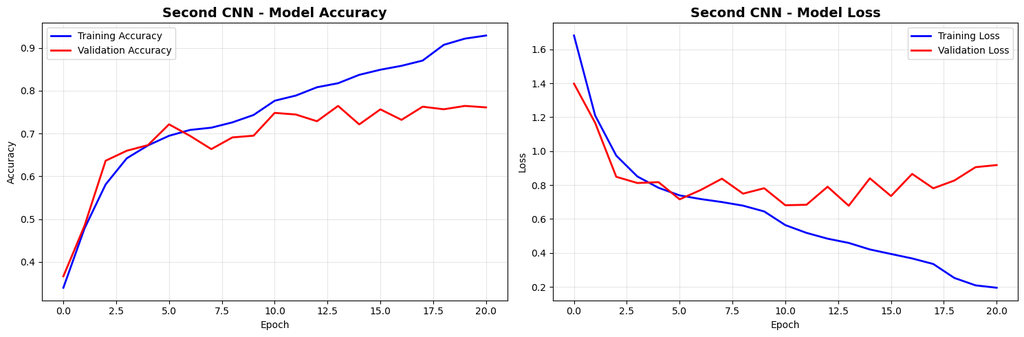

```
FINAL TRAINING METRICS:
Training Accuracy: 0.9287 (92.87%)
Validation Accuracy: 0.7609 (76.09%)
```

```python
# Compiling the model
second_cnn.compile(
    optimizer='adam',
    loss='categorical_crossentropy',
    metrics=['accuracy']
)

# Training parameters
EPOCHS = 25

# Defining callbacks for better training
callbacks = [
    tf.keras.callbacks.EarlyStopping(
        monitor='val_accuracy',
        patience=7,
        restore_best_weights=True,
        verbose=1
    ),
    tf.keras.callbacks.ReduceLROnPlateau(
        monitor='val_loss',
        factor=0.5,
        patience=4,
        min_lr=1e-7,
        verbose=1
    ),
    tf.keras.callbacks.ModelCheckpoint(
        filepath='best_second_cnn.h5',
        monitor='val_accuracy',
        save_best_only=True,
        verbose=1
    )
]

# Training the model using grayscale data loader
print("\nStarting training of Second CNN (Larger Architecture)...")
print("="*60)
history_second = second_cnn.fit(
    train_ds_gray,
    validation_data=validation_ds_gray,
    epochs=EPOCHS,
    callbacks=callbacks,
    verbose=1
)


# Plotting training history
import matplotlib.pyplot as plt

fig, (ax1, ax2) = plt.subplots(1, 2, figsize=(15, 5))

# Plotting Accuracy
ax1.plot(history_second.history['accuracy'], label='Training Accuracy', color='blue', linewidth=2)
ax1.plot(history_second.history['val_accuracy'], label='Validation Accuracy', color='red', linewidth=2)
ax1.set_title('Second CNN - Model Accuracy', fontsize=14, fontweight='bold')
ax1.set_xlabel('Epoch')
ax1.set_ylabel('Accuracy')
ax1.legend()
ax1.grid(True, alpha=0.3)

# Plotting Loss
ax2.plot(history_second.history['loss'], label='Training Loss', color='blue', linewidth=2)
ax2.plot(history_second.history['val_loss'], label='Validation Loss', color='red', linewidth=2)
ax2.set_title('Second CNN - Model Loss', fontsize=14, fontweight='bold')
ax2.set_xlabel('Epoch')
ax2.set_ylabel('Loss')
ax2.legend()
ax2.grid(True, alpha=0.3)

plt.tight_layout()
plt.show()

# Printing final metrics
final_train_acc = history_second.history['accuracy'][-1]
final_val_acc = history_second.history['val_accuracy'][-1]
print(f"\nFINAL TRAINING METRICS:")
print(f"Training Accuracy: {final_train_acc:.4f} ({final_train_acc*100:.2f}%)")
print(f"Validation Accuracy: {final_val_acc:.4f} ({final_val_acc*100:.2f}%)")
```

### **Evaluating the Model on the Test Set using GrayScale data loader**

```python
print("Evaluating Second CNN (Larger Architecture) on test set...")
print("="*60)

# Getting test loss and accuracy
test_loss_second, test_accuracy_second = second_cnn.evaluate(test_ds_gray, verbose=1)

print(f"\nSECOND CNN TEST RESULTS:")
print(f"{'='*35}")
print(f"Test Loss: {test_loss_second:.4f}")
print(f"Test Accuracy: {test_accuracy_second:.4f} ({test_accuracy_second*100:.2f}%)")

# Getting detailed predictions for further analysis
print("\nGenerating predictions...")
test_predictions_second = second_cnn.predict(test_ds_gray)
predicted_classes_second = tf.argmax(test_predictions_second, axis=1)

# Getting true labels from test dataset
true_labels = []
for images, labels in test_ds_gray:
    true_labels.extend(tf.argmax(labels, axis=1).numpy())

# Converting to tensor and ensure same data type
true_labels = tf.cast(tf.constant(true_labels), tf.int64)
predicted_classes_second = tf.cast(predicted_classes_second, tf.int64)

print(f"Total test samples: {len(true_labels)}")

# Calculating per-class accuracy
class_names = ['happy', 'sad', 'surprise', 'neutral']
print(f"\nPer-class performance:")
print("-" * 45)

for i, class_name in enumerate(class_names):
    class_mask = (true_labels == i)
    class_predictions = predicted_classes_second[class_mask]
    class_true = true_labels[class_mask]

    if len(class_true) > 0:
        class_accuracy = tf.reduce_mean(tf.cast(class_predictions == class_true, tf.float32))
        print(f"{class_name.capitalize()}: {class_accuracy:.4f} ({class_accuracy*100:.2f}%) - {len(class_true)} samples")
    else:
        print(f"{class_name.capitalize()}: No samples found")

# Additional metrics
from sklearn.metrics import classification_report, confusion_matrix
print(f"\nDetailed Classification Report:")
print("-" * 55)
print(classification_report(true_labels.numpy(), predicted_classes_second.numpy(),
                          target_names=class_names, digits=4))

# Summary of model performance
print(f"\n{'='*60}")
print("SECOND CNN PERFORMANCE SUMMARY")
print(f"{'='*60}")
print(f"Architecture: Larger CNN with 4 Conv Blocks + Double Conv Layers")
print(f"Input: Grayscale images (48x48x1)")
print(f"Test Accuracy: {test_accuracy_second:.4f} ({test_accuracy_second*100:.2f}%)")
print(f"Parameters: More complex than base CNN")
print(f"Training: {len(history_second.history['accuracy'])} epochs")
```

```
Evaluating Second CNN (Larger Architecture) on test set...
============================================================
4/4 ━━━━━━━━━━━━━━━━━━━━ 4s 583ms/step - accuracy: 0.7656 - loss: 0.7132

SECOND CNN TEST RESULTS:
===================================
Test Loss: 0.7132
Test Accuracy: 0.7656 (76.56%)

Generating predictions...
4/4 ━━━━━━━━━━━━━━━━━━━━ 9s 136ms/step
Total test samples: 128

Per-class performance:
---------------------------------------------
Happy: 0.8438 (84.38%) - 32 samples
Sad: 0.7188 (71.88%) - 32 samples
Surprise: 0.8750 (87.50%) - 32 samples
Neutral: 0.6250 (62.50%) - 32 samples

Detailed Classification Report:
-------------------------------------------------------
              precision    recall  f1-score   support

       happy     0.8182    0.8438    0.8308        32
         sad     0.6216    0.7188    0.6667        32
    surprise     0.9333    0.8750    0.9032        32
     neutral     0.7143    0.6250    0.6667        32

    accuracy                         0.7656       128
   macro avg     0.7719    0.7656    0.7668       128
weighted avg     0.7719    0.7656    0.7668       128


============================================================
SECOND CNN PERFORMANCE SUMMARY
============================================================
Architecture: Larger CNN with 4 Conv Blocks + Double Conv Layers
Input: Grayscale images (48x48x1)
Test Accuracy: 0.7656 (76.56%)
Parameters: More complex than base CNN
Training: 21 epochs
```

### **Creating the second Convolutional Neural Network for RGB Data loader**

```python
import tensorflow as tf
from tensorflow.keras.models import Sequential
from tensorflow.keras.layers import (
    Rescaling, Conv2D, BatchNormalization, MaxPooling2D,
    Dropout, GlobalAveragePooling2D, Dense
)
from tensorflow.keras.regularizers import l2

# Creating second CNN model for RGB data with reduced overfitting
def create_second_cnn_rgb(input_shape=(48, 48, 3), num_classes=4):
    model = Sequential([
        # Preprocessing layer (normalize to [0,1])
        Rescaling(1./255, input_shape=input_shape),

        # First Convolutional Block
        Conv2D(32, (3, 3), activation='relu', padding='same', kernel_regularizer=l2(1e-4), name='conv1'),
        BatchNormalization(name='bn1'),
        Conv2D(32, (3, 3), activation='relu', padding='same', kernel_regularizer=l2(1e-4), name='conv1_2'),
        MaxPooling2D((2, 2), name='pool1'),
        Dropout(0.3, name='dropout1'),

        # Second Convolutional Block
        Conv2D(64, (3, 3), activation='relu', padding='same', kernel_regularizer=l2(1e-4), name='conv2'),
        BatchNormalization(name='bn2'),
        Conv2D(64, (3, 3), activation='relu', padding='same', kernel_regularizer=l2(1e-4), name='conv2_2'),
        MaxPooling2D((2, 2), name='pool2'),
        Dropout(0.35, name='dropout2'),

        # Third Convolutional Block
        Conv2D(128, (3, 3), activation='relu', padding='same', kernel_regularizer=l2(1e-4), name='conv3'),
        BatchNormalization(name='bn3'),
        Conv2D(128, (3, 3), activation='relu', padding='same', kernel_regularizer=l2(1e-4), name='conv3_2'),
        MaxPooling2D((2, 2), name='pool3'),
        Dropout(0.4, name='dropout3'),

        # Fourth Convolutional Block (reduced filters)
        Conv2D(256, (3, 3), activation='relu', padding='same', kernel_regularizer=l2(1e-4), name='conv4'),
        BatchNormalization(name='bn4'),
        MaxPooling2D((2, 2), name='pool4'),
        Dropout(0.45, name='dropout4'),

        # Use GAP instead of Flatten to drastically cut parameters
        GlobalAveragePooling2D(name='gap'),

        # Dense layers with L2 and Dropout
        Dense(256, activation='relu', kernel_regularizer=l2(1e-4), name='dense1'),
        BatchNormalization(name='bn_dense1'),
        Dropout(0.5, name='dropout_dense1'),

        # Output layer
        Dense(num_classes, activation='softmax', name='output')
    ])

    return model


# Creating and compiling the reduced-overfitting CNN model
second_cnn_rgb = create_second_cnn_rgb(input_shape=(48, 48, 3), num_classes=4)

print("SECOND CNN - RGB VERSION")
print("="*50)
second_cnn_rgb.summary()

# Count parameters
total_params = second_cnn_rgb.count_params()
trainable_params = sum([tf.keras.backend.count_params(w) for w in second_cnn_rgb.trainable_weights])
non_trainable_params = total_params - trainable_params
print("\nMODEL PARAMETERS:")
print(f"Total parameters: {total_params:,}")
print(f"Trainable parameters: {trainable_params:,}")
print(f"Non-trainable parameters: {non_trainable_params:,}")
print("\nSecond CNN RGB model created successfully!")
```

```
SECOND CNN - RGB VERSION
==================================================
```

```
Model: "sequential_2"
```

```
┏━━━━━━━━━━━━━━━━━━━━━━━━━━━━━━━━━┳━━━━━━━━━━━━━━━━━━━━━━━━┳━━━━━━━━━━━━━━━┓
┃ Layer (type)                    ┃ Output Shape           ┃       Param # ┃
┡━━━━━━━━━━━━━━━━━━━━━━━━━━━━━━━━━╇━━━━━━━━━━━━━━━━━━━━━━━━╇━━━━━━━━━━━━━━━┩
│ rescaling_5 (Rescaling)         │ (None, 48, 48, 3)      │             0 │
├─────────────────────────────────┼────────────────────────┼───────────────┤
│ conv1 (Conv2D)                  │ (None, 48, 48, 32)     │           896 │
├─────────────────────────────────┼────────────────────────┼───────────────┤
│ bn1 (BatchNormalization)        │ (None, 48, 48, 32)     │           128 │
├─────────────────────────────────┼────────────────────────┼───────────────┤
│ conv1_2 (Conv2D)                │ (None, 48, 48, 32)     │         9,248 │
├─────────────────────────────────┼────────────────────────┼───────────────┤
│ pool1 (MaxPooling2D)            │ (None, 24, 24, 32)     │             0 │
├─────────────────────────────────┼────────────────────────┼───────────────┤
│ dropout1 (Dropout)              │ (None, 24, 24, 32)     │             0 │
├─────────────────────────────────┼────────────────────────┼───────────────┤
│ conv2 (Conv2D)                  │ (None, 24, 24, 64)     │        18,496 │
├─────────────────────────────────┼────────────────────────┼───────────────┤
│ bn2 (BatchNormalization)        │ (None, 24, 24, 64)     │           256 │
├─────────────────────────────────┼────────────────────────┼───────────────┤
│ conv2_2 (Conv2D)                │ (None, 24, 24, 64)     │        36,928 │
├─────────────────────────────────┼────────────────────────┼───────────────┤
│ pool2 (MaxPooling2D)            │ (None, 12, 12, 64)     │             0 │
├─────────────────────────────────┼────────────────────────┼───────────────┤
│ dropout2 (Dropout)              │ (None, 12, 12, 64)     │             0 │
├─────────────────────────────────┼────────────────────────┼───────────────┤
│ conv3 (Conv2D)                  │ (None, 12, 12, 128)    │        73,856 │
├─────────────────────────────────┼────────────────────────┼───────────────┤
│ bn3 (BatchNormalization)        │ (None, 12, 12, 128)    │           512 │
├─────────────────────────────────┼────────────────────────┼───────────────┤
│ conv3_2 (Conv2D)                │ (None, 12, 12, 128)    │       147,584 │
├─────────────────────────────────┼────────────────────────┼───────────────┤
│ pool3 (MaxPooling2D)            │ (None, 6, 6, 128)      │             0 │
├─────────────────────────────────┼────────────────────────┼───────────────┤
│ dropout3 (Dropout)              │ (None, 6, 6, 128)      │             0 │
├─────────────────────────────────┼────────────────────────┼───────────────┤
│ conv4 (Conv2D)                  │ (None, 6, 6, 256)      │       295,168 │
├─────────────────────────────────┼────────────────────────┼───────────────┤
│ bn4 (BatchNormalization)        │ (None, 6, 6, 256)      │         1,024 │
├─────────────────────────────────┼────────────────────────┼───────────────┤
│ pool4 (MaxPooling2D)            │ (None, 3, 3, 256)      │             0 │
├─────────────────────────────────┼────────────────────────┼───────────────┤
│ dropout4 (Dropout)              │ (None, 3, 3, 256)      │             0 │
├─────────────────────────────────┼────────────────────────┼───────────────┤
│ gap (GlobalAveragePooling2D)    │ (None, 256)            │             0 │
├─────────────────────────────────┼────────────────────────┼───────────────┤
│ dense1 (Dense)                  │ (None, 256)            │        65,792 │
├─────────────────────────────────┼────────────────────────┼───────────────┤
│ bn_dense1 (BatchNormalization)  │ (None, 256)            │         1,024 │
├─────────────────────────────────┼────────────────────────┼───────────────┤
│ dropout_dense1 (Dropout)        │ (None, 256)            │             0 │
├─────────────────────────────────┼────────────────────────┼───────────────┤
│ output (Dense)                  │ (None, 4)              │         1,028 │
└─────────────────────────────────┴────────────────────────┴───────────────┘
```

```
 Total params: 651,940 (2.49 MB)
```

```
 Trainable params: 650,468 (2.48 MB)
```

```
 Non-trainable params: 1,472 (5.75 KB)
```

```
MODEL PARAMETERS:
Total parameters: 651,940
Trainable parameters: 650,468
Non-trainable parameters: 1,472

Second CNN RGB model created successfully!
```

### **Compiling and Training the Model for RGB data loader**

```
Compiling Second CNN RGB Model...
============================================================
Second CNN RGB model compiled successfully!

Starting training of Second CNN RGB Model...
============================================================
```

[output not shown]

```
473/473 ━━━━━━━━━━━━━━━━━━━━ 0s 153ms/step - accuracy: 0.2893 - loss: 1.8202
Epoch 1: val_accuracy improved from -inf to 0.24533, saving model to best_second_cnn_rgb.h5
473/473 ━━━━━━━━━━━━━━━━━━━━ 113s 182ms/step - accuracy: 0.2893 - loss: 1.8199 - val_accuracy: 0.2453 - val_loss: 1.9114 - learning_rate: 0.0010
472/473 ━━━━━━━━━━━━━━━━━━━━ 0s 134ms/step - accuracy: 0.3176 - loss: 1.4996
Epoch 2: val_accuracy improved from 0.24533 to 0.35765, saving model to best_second_cnn_rgb.h5
473/473 ━━━━━━━━━━━━━━━━━━━━ 69s 146ms/step - accuracy: 0.3178 - loss: 1.4995 - val_accuracy: 0.3576 - val_loss: 2.0799 - learning_rate: 0.0010
472/473 ━━━━━━━━━━━━━━━━━━━━ 0s 132ms/step - accuracy: 0.3967 - loss: 1.3501
Epoch 3: val_accuracy did not improve from 0.35765
473/473 ━━━━━━━━━━━━━━━━━━━━ 68s 144ms/step - accuracy: 0.3968 - loss: 1.3499 - val_accuracy: 0.2351 - val_loss: 1.9010 - learning_rate: 0.0010
472/473 ━━━━━━━━━━━━━━━━━━━━ 0s 132ms/step - accuracy: 0.4707 - loss: 1.2405
Epoch 4: val_accuracy improved from 0.35765 to 0.42978, saving model to best_second_cnn_rgb.h5
473/473 ━━━━━━━━━━━━━━━━━━━━ 68s 143ms/step - accuracy: 0.4708 - loss: 1.2404 - val_accuracy: 0.4298 - val_loss: 1.4496 - learning_rate: 0.0010
472/473 ━━━━━━━━━━━━━━━━━━━━ 0s 132ms/step - accuracy: 0.5403 - loss: 1.1373
Epoch 5: val_accuracy did not improve from 0.42978
473/473 ━━━━━━━━━━━━━━━━━━━━ 68s 143ms/step - accuracy: 0.5403 - loss: 1.1373 - val_accuracy: 0.3681 - val_loss: 1.5351 - learning_rate: 0.0010
472/473 ━━━━━━━━━━━━━━━━━━━━ 0s 132ms/step - accuracy: 0.5792 - loss: 1.0675
Epoch 6: val_accuracy did not improve from 0.42978
473/473 ━━━━━━━━━━━━━━━━━━━━ 68s 143ms/step - accuracy: 0.5792 - loss: 1.0675 - val_accuracy: 0.4008 - val_loss: 1.5026 - learning_rate: 0.0010
472/473 ━━━━━━━━━━━━━━━━━━━━ 0s 132ms/step - accuracy: 0.6120 - loss: 1.0155
Epoch 7: val_accuracy improved from 0.42978 to 0.56560, saving model to best_second_cnn_rgb.h5
473/473 ━━━━━━━━━━━━━━━━━━━━ 68s 144ms/step - accuracy: 0.6120 - loss: 1.0155 - val_accuracy: 0.5656 - val_loss: 1.1459 - learning_rate: 0.0010
472/473 ━━━━━━━━━━━━━━━━━━━━ 0s 132ms/step - accuracy: 0.6174 - loss: 0.9894
Epoch 8: val_accuracy improved from 0.56560 to 0.56741, saving model to best_second_cnn_rgb.h5
473/473 ━━━━━━━━━━━━━━━━━━━━ 68s 143ms/step - accuracy: 0.6174 - loss: 0.9894 - val_accuracy: 0.5674 - val_loss: 1.1891 - learning_rate: 0.0010
472/473 ━━━━━━━━━━━━━━━━━━━━ 0s 132ms/step - accuracy: 0.6512 - loss: 0.9530
Epoch 9: val_accuracy improved from 0.56741 to 0.64336, saving model to best_second_cnn_rgb.h5
473/473 ━━━━━━━━━━━━━━━━━━━━ 68s 143ms/step - accuracy: 0.6512 - loss: 0.9531 - val_accuracy: 0.6434 - val_loss: 1.0273 - learning_rate: 0.0010
472/473 ━━━━━━━━━━━━━━━━━━━━ 0s 132ms/step - accuracy: 0.6525 - loss: 0.9437
Epoch 10: val_accuracy did not improve from 0.64336
473/473 ━━━━━━━━━━━━━━━━━━━━ 68s 143ms/step - accuracy: 0.6525 - loss: 0.9437 - val_accuracy: 0.6355 - val_loss: 1.0165 - learning_rate: 0.0010
472/473 ━━━━━━━━━━━━━━━━━━━━ 0s 132ms/step - accuracy: 0.6578 - loss: 0.9281
Epoch 11: val_accuracy did not improve from 0.64336
473/473 ━━━━━━━━━━━━━━━━━━━━ 68s 143ms/step - accuracy: 0.6578 - loss: 0.9282 - val_accuracy: 0.6078 - val_loss: 1.1019 - learning_rate: 0.0010
472/473 ━━━━━━━━━━━━━━━━━━━━ 0s 132ms/step - accuracy: 0.6664 - loss: 0.9169
Epoch 12: val_accuracy improved from 0.64336 to 0.66727, saving model to best_second_cnn_rgb.h5
473/473 ━━━━━━━━━━━━━━━━━━━━ 68s 143ms/step - accuracy: 0.6664 - loss: 0.9169 - val_accuracy: 0.6673 - val_loss: 0.9425 - learning_rate: 0.0010
472/473 ━━━━━━━━━━━━━━━━━━━━ 0s 132ms/step - accuracy: 0.6685 - loss: 0.9130
Epoch 13: val_accuracy did not improve from 0.66727
473/473 ━━━━━━━━━━━━━━━━━━━━ 68s 143ms/step - accuracy: 0.6685 - loss: 0.9130 - val_accuracy: 0.5441 - val_loss: 1.4244 - learning_rate: 0.0010
472/473 ━━━━━━━━━━━━━━━━━━━━ 0s 132ms/step - accuracy: 0.6767 - loss: 0.8990
```

[output cut: 27 more lines]

```
473/473 ━━━━━━━━━━━━━━━━━━━━ 68s 143ms/step - accuracy: 0.7339 - loss: 0.7740 - val_accuracy: 0.6910 - val_loss: 0.9389 - learning_rate: 5.0000e-04
472/473 ━━━━━━━━━━━━━━━━━━━━ 0s 132ms/step - accuracy: 0.7320 - loss: 0.7690
Epoch 23: val_accuracy did not improve from 0.69841
473/473 ━━━━━━━━━━━━━━━━━━━━ 68s 143ms/step - accuracy: 0.7319 - loss: 0.7691 - val_accuracy: 0.6335 - val_loss: 1.1016 - learning_rate: 5.0000e-04
472/473 ━━━━━━━━━━━━━━━━━━━━ 0s 132ms/step - accuracy: 0.7411 - loss: 0.7601
Epoch 24: val_accuracy did not improve from 0.69841
473/473 ━━━━━━━━━━━━━━━━━━━━ 68s 143ms/step - accuracy: 0.7411 - loss: 0.7601 - val_accuracy: 0.6703 - val_loss: 0.9752 - learning_rate: 5.0000e-04
472/473 ━━━━━━━━━━━━━━━━━━━━ 0s 132ms/step - accuracy: 0.7434 - loss: 0.7569
Epoch 25: val_accuracy did not improve from 0.69841

Epoch 25: ReduceLROnPlateau reducing learning rate to 0.0002500000118743628.
473/473 ━━━━━━━━━━━━━━━━━━━━ 68s 143ms/step - accuracy: 0.7434 - loss: 0.7570 - val_accuracy: 0.6938 - val_loss: 0.9467 - learning_rate: 5.0000e-04
Restoring model weights from the end of the best epoch: 21.

Plotting Training History...
```

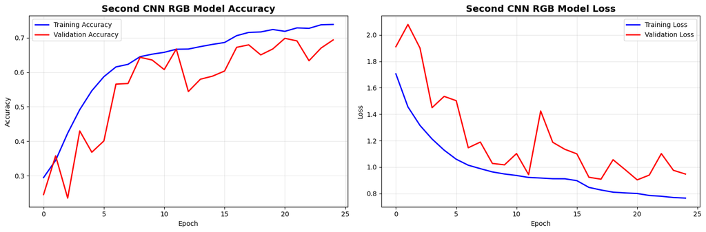

```
🎯 SECOND CNN RGB TRAINING COMPLETED!
==================================================
Final Training Accuracy: 0.7386 (73.86%)
Final Validation Accuracy: 0.6938 (69.38%)
```

```python
# Compile the Second CNN RGB model
print("Compiling Second CNN RGB Model...")
print("="*60)

second_cnn_rgb.compile(
    optimizer='adam',
    loss='categorical_crossentropy',
    metrics=['accuracy']
)

print("Second CNN RGB model compiled successfully!")

# Training parameters
EPOCHS = 25
print(f"\nStarting training of Second CNN RGB Model...")
print("="*60)

# Defining callbacks for better training
callbacks = [
    tf.keras.callbacks.ModelCheckpoint(
        'best_second_cnn_rgb.h5',
        monitor='val_accuracy',
        save_best_only=True,
        save_weights_only=False,
        verbose=1
    ),
    tf.keras.callbacks.EarlyStopping(
        monitor='val_accuracy',
        patience=7,
        restore_best_weights=True,
        verbose=1
    ),
    tf.keras.callbacks.ReduceLROnPlateau(
        monitor='val_loss',
        factor=0.5,
        patience=4,
        min_lr=1e-7,
        verbose=1
    )
]

# Training the Second CNN RGB model
history_second_rgb = second_cnn_rgb.fit(
    train_ds_rgb,
    validation_data=validation_ds_rgb,
    epochs=EPOCHS,
    callbacks=callbacks,
    verbose=1
)

# Plotting training history
print("\nPlotting Training History...")
fig, (ax1, ax2) = plt.subplots(1, 2, figsize=(15, 5))

# Plotting accuracy
ax1.plot(history_second_rgb.history['accuracy'], label='Training Accuracy', color='blue', linewidth=2)
ax1.plot(history_second_rgb.history['val_accuracy'], label='Validation Accuracy', color='red', linewidth=2)
ax1.set_title('Second CNN RGB Model Accuracy', fontsize=14, fontweight='bold')
ax1.set_xlabel('Epoch')
ax1.set_ylabel('Accuracy')
ax1.legend()
ax1.grid(True, alpha=0.3)

# Plotting loss
ax2.plot(history_second_rgb.history['loss'], label='Training Loss', color='blue', linewidth=2)
ax2.plot(history_second_rgb.history['val_loss'], label='Validation Loss', color='red', linewidth=2)
ax2.set_title('Second CNN RGB Model Loss', fontsize=14, fontweight='bold')
ax2.set_xlabel('Epoch')
ax2.set_ylabel('Loss')
ax2.legend()
ax2.grid(True, alpha=0.3)

plt.tight_layout()
plt.show()

# Print final training metrics
final_train_acc = history_second_rgb.history['accuracy'][-1]
final_val_acc = history_second_rgb.history['val_accuracy'][-1]

print(f"\n🎯 SECOND CNN RGB TRAINING COMPLETED!")
print("="*50)
print(f"Final Training Accuracy: {final_train_acc:.4f} ({final_train_acc*100:.2f}%)")
print(f"Final Validation Accuracy: {final_val_acc:.4f} ({final_val_acc*100:.2f}%)")
```

### **Evaluating the Model on the Test Set using rgb data loader**

```python
# Evaluate Second CNN RGB on test set
print("Evaluating Second CNN RGB on test set...")
print("="*60)
test_loss_second_rgb, test_accuracy_second_rgb = second_cnn_rgb.evaluate(test_ds_rgb, verbose=1)
print(f"\nSECOND CNN RGB TEST RESULTS:")
print(f"Test Loss: {test_loss_second_rgb:.4f}")
print(f"Test Accuracy: {test_accuracy_second_rgb:.4f} ({test_accuracy_second_rgb*100:.2f}%)")

# Generate Second CNN RGB predictions for detailed analysis
test_predictions_second_rgb = second_cnn_rgb.predict(test_ds_rgb)
predicted_classes_second_rgb = tf.argmax(test_predictions_second_rgb, axis=1)

# Get true labels for RGB data
true_labels_rgb = []
for images, labels in test_ds_rgb:
    true_labels_rgb.extend(tf.argmax(labels, axis=1).numpy())

true_labels_rgb = tf.cast(tf.constant(true_labels_rgb), tf.int64)
predicted_classes_second_rgb = tf.cast(predicted_classes_second_rgb, tf.int64)

# Per-class accuracy for Second CNN RGB
print(f"\nSECOND CNN RGB Per-class performance:")
print("-" * 45)
class_names = ['happy', 'sad', 'surprise', 'neutral']
for i, class_name in enumerate(class_names):
    class_mask = (true_labels_rgb == i)
    class_predictions = predicted_classes_second_rgb[class_mask]
    class_true = true_labels_rgb[class_mask]

    if len(class_true) > 0:
        class_accuracy = tf.reduce_mean(tf.cast(class_predictions == class_true, tf.float32))
        print(f"{class_name.capitalize()}: {class_accuracy:.4f} ({class_accuracy*100:.2f}%)")

# Additional metrics
from sklearn.metrics import classification_report, confusion_matrix
print(f"\nDetailed Classification Report:")
print("-" * 55)
print(classification_report(true_labels_rgb.numpy(), predicted_classes_second_rgb.numpy(),
                          target_names=class_names, digits=4))

# Summary of model performance
print(f"\n{'='*60}")
print("SECOND CNN RGB PERFORMANCE SUMMARY")
print(f"{'='*60}")
print(f"Architecture: Second CNN RGB with 4 Conv Blocks + Double Conv Layers")
print(f"Input: RGB images (48x48x3)")
print(f"Test Accuracy: {test_accuracy_second_rgb:.4f} ({test_accuracy_second_rgb*100:.2f}%)")
print(f"Parameters: {second_cnn_rgb.count_params():,}")
print(f"Training: {len(history_second_rgb.history['accuracy'])} epochs")
```

```
Evaluating Second CNN RGB on test set...
============================================================
4/4 ━━━━━━━━━━━━━━━━━━━━ 0s 47ms/step - accuracy: 0.6719 - loss: 0.9176

SECOND CNN RGB TEST RESULTS:
Test Loss: 0.8737
Test Accuracy: 0.6719 (67.19%)
4/4 ━━━━━━━━━━━━━━━━━━━━ 1s 34ms/step

SECOND CNN RGB Per-class performance:
---------------------------------------------
Happy: 0.6562 (65.62%)
Sad: 0.6875 (68.75%)
Surprise: 0.7188 (71.88%)
Neutral: 0.6250 (62.50%)

Detailed Classification Report:
-------------------------------------------------------
              precision    recall  f1-score   support

       happy     0.7500    0.6562    0.7000        32
         sad     0.5366    0.6875    0.6027        32
    surprise     1.0000    0.7188    0.8364        32
     neutral     0.5556    0.6250    0.5882        32

    accuracy                         0.6719       128
   macro avg     0.7105    0.6719    0.6818       128
weighted avg     0.7105    0.6719    0.6818       128


============================================================
SECOND CNN RGB PERFORMANCE SUMMARY
============================================================
Architecture: Second CNN RGB with 4 Conv Blocks + Double Conv Layers
Input: RGB images (48x48x3)
Test Accuracy: 0.6719 (67.19%)
Parameters: 651,940
Training: 25 epochs
```

## **Think About It:**

- Did the models have a satisfactory performance? If not, then what are the possible reasons?
- Which Color mode showed better overall performance? What are the possible reasons? Do you think having 'rgb' color mode is needed because the images are already black and white?

## **Transfer Learning Architectures**

In this section, we will create several Transfer Learning architectures. For the pre-trained models, we will select three popular architectures namely, VGG16, ResNet v2, and Efficient Net. The difference between these architectures and the previous architectures is that these will require 3 input channels while the earlier ones worked on 'grayscale' images. Therefore, we need to create new DataLoaders.

### **Creating our Data Loaders for Transfer Learning Architectures**

In this section, we are creating data loaders that we will use as inputs to our Neural Network. We will have to go with color_mode = 'rgb' as this is the required format for the transfer learning architectures.

```python
# Set paths
base_path = '/kaggle/input/facial-emotions/Facial_emotion_images'

# Image parameters for transfer learning models
IMG_SIZE = (224, 224)  # Standard input size for most pre-trained models
BATCH_SIZE = 32

print("Creating RGB Data Loaders for Transfer Learning...")
print("="*60)

# Createing RGB data loaders for transfer learning
train_ds_rgb = tf.keras.utils.image_dataset_from_directory(
    directory=f'{base_path}/train',
    labels='inferred',
    label_mode='categorical',
    class_names=['happy', 'sad', 'surprise', 'neutral'],
    color_mode='rgb',  # Required for transfer learning models
    batch_size=BATCH_SIZE,
    image_size=IMG_SIZE,  # 224x224 for most pre-trained models
    shuffle=True,
    seed=42
)

validation_ds_rgb = tf.keras.utils.image_dataset_from_directory(
    directory=f'{base_path}/validation',
    labels='inferred',
    label_mode='categorical',
    class_names=['happy', 'sad', 'surprise', 'neutral'],
    color_mode='rgb',
    batch_size=BATCH_SIZE,
    image_size=IMG_SIZE,
    shuffle=False,
    seed=42
)

test_ds_rgb = tf.keras.utils.image_dataset_from_directory(
    directory=f'{base_path}/test',
    labels='inferred',
    label_mode='categorical',
    class_names=['happy', 'sad', 'surprise', 'neutral'],
    color_mode='rgb',
    batch_size=BATCH_SIZE,
    image_size=IMG_SIZE,
    shuffle=False,
    seed=42
)

print("RGB Data Loaders Created Successfully!")
print(f"Training batches: {len(train_ds_rgb)}")
print(f"Validation batches: {len(validation_ds_rgb)}")
print(f"Test batches: {len(test_ds_rgb)}")

# Verifing input shape
for images, labels in train_ds_rgb.take(1):
    print(f"RGB image shape: {images.shape}")
    print(f"Labels shape: {labels.shape}")
    print(f"Expected input for transfer learning: (batch_size, 224, 224, 3)")

# Performance optimization
AUTOTUNE = tf.data.AUTOTUNE

def optimize_dataset(dataset):
    """Optimizing dataset for better performance"""
    return dataset.cache().prefetch(buffer_size=AUTOTUNE)

# Optimizing RGB datasets for transfer learning
train_ds_rgb = optimize_dataset(train_ds_rgb)
validation_ds_rgb = optimize_dataset(validation_ds_rgb)
test_ds_rgb = optimize_dataset(test_ds_rgb)

print("All RGB datasets optimized for performance!")

# Preprocessing for different transfer learning models
def preprocess_for_vgg(image, label):
    """Preprocessing images for VGG16 models"""
    # VGG expects inputs in range [0, 255] but with specific preprocessing
    from tensorflow.keras.applications.vgg16 import preprocess_input
    return preprocess_input(image), label

def preprocess_for_resnet(image, label):
    """Preprocessing images for ResNet models"""
    from tensorflow.keras.applications.resnet_v2 import preprocess_input
    return preprocess_input(image), label

def preprocess_for_efficientnet(image, label):
    """Preprocessing images for EfficientNet models"""
    from tensorflow.keras.applications.efficientnet import preprocess_input
    return preprocess_input(image), label

# Creating preprocessed datasets for different architectures
print("\nCreating model-specific preprocessed datasets...")

# For VGG16
train_ds_vgg = train_ds_rgb.map(preprocess_for_vgg, num_parallel_calls=AUTOTUNE)
validation_ds_vgg = validation_ds_rgb.map(preprocess_for_vgg, num_parallel_calls=AUTOTUNE)
test_ds_vgg = test_ds_rgb.map(preprocess_for_vgg, num_parallel_calls=AUTOTUNE)

# For ResNet
train_ds_resnet = train_ds_rgb.map(preprocess_for_resnet, num_parallel_calls=AUTOTUNE)
validation_ds_resnet = validation_ds_rgb.map(preprocess_for_resnet, num_parallel_calls=AUTOTUNE)
test_ds_resnet = test_ds_rgb.map(preprocess_for_resnet, num_parallel_calls=AUTOTUNE)

# For EfficientNet
train_ds_efficientnet = train_ds_rgb.map(preprocess_for_efficientnet, num_parallel_calls=AUTOTUNE)
validation_ds_efficientnet = validation_ds_rgb.map(preprocess_for_efficientnet, num_parallel_calls=AUTOTUNE)
test_ds_efficientnet = test_ds_rgb.map(preprocess_for_efficientnet, num_parallel_calls=AUTOTUNE)

print("Model-specific preprocessed datasets created!")
print("\nAvailable datasets:")
print("- train_ds_vgg, validation_ds_vgg, test_ds_vgg (for VGG16)")
print("- train_ds_resnet, validation_ds_resnet, test_ds_resnet (for ResNet)")
print("- train_ds_efficientnet, validation_ds_efficientnet, test_ds_efficientnet (for EfficientNet)")
```

```
Creating RGB Data Loaders for Transfer Learning...
============================================================
Found 15109 files belonging to 4 classes.
```

```
I0000 00:00:1755111271.719232      36 gpu_device.cc:2022] Created device /job:localhost/replica:0/task:0/device:GPU:0 with 13942 MB memory:  -> device: 0, name: Tesla T4, pci bus id: 0000:00:04.0, compute capability: 7.5
I0000 00:00:1755111271.719892      36 gpu_device.cc:2022] Created device /job:localhost/replica:0/task:0/device:GPU:1 with 13942 MB memory:  -> device: 1, name: Tesla T4, pci bus id: 0000:00:05.0, compute capability: 7.5
```

```
Found 4977 files belonging to 4 classes.
Found 128 files belonging to 4 classes.
RGB Data Loaders Created Successfully!
Training batches: 473
Validation batches: 156
Test batches: 4
RGB image shape: (32, 224, 224, 3)
Labels shape: (32, 4)
Expected input for transfer learning: (batch_size, 224, 224, 3)
All RGB datasets optimized for performance!

Creating model-specific preprocessed datasets...
Model-specific preprocessed datasets created!

Available datasets:
- train_ds_vgg, validation_ds_vgg, test_ds_vgg (for VGG16)
- train_ds_resnet, validation_ds_resnet, test_ds_resnet (for ResNet)
- train_ds_efficientnet, validation_ds_efficientnet, test_ds_efficientnet (for EfficientNet)
```

## **VGG16 Model**

### **Importing the VGG16 Architecture**

```python
from tensorflow.keras.applications import VGG16
```

### **Model Building**

- Import VGG16 upto the layer of your choice and add Fully Connected layers on top of it.

```python
# Creating VGG16 model for facial emotion detection
def create_vgg16_emotion_model(num_classes=4):
    # Import VGG16 base model (pre-trained on ImageNet)
    vgg16_base = VGG16(
        weights='imagenet',
        include_top=False,
        input_shape=(224, 224, 3),
        pooling=None
    )

    # Freezing the base model layers
    vgg16_base.trainable = False

    # Building the complete model
    model = Sequential([
        # VGG16 base model
        vgg16_base,

        # Global Average Pooling
        GlobalAveragePooling2D(name='global_avg_pool'),

        # Custom fully connected layers
        Dense(1024, activation='relu', name='fc1'),
        BatchNormalization(name='bn1'),
        Dropout(0.5, name='dropout1'),

        Dense(512, activation='relu', name='fc2'),
        BatchNormalization(name='bn2'),
        Dropout(0.5, name='dropout2'),

        Dense(256, activation='relu', name='fc3'),
        BatchNormalization(name='bn3'),
        Dropout(0.3, name='dropout3'),

        # Output layer for 4 emotions
        Dense(num_classes, activation='softmax', name='predictions')
    ])

    return model

# Creating the VGG16 model
print("Creating VGG16 Model for Facial Emotion Detection...")
print("="*60)

vgg16_model = create_vgg16_emotion_model(num_classes=4)

# Compiling the model
vgg16_model.compile(
    optimizer=Adam(learning_rate=0.0001),
    loss='categorical_crossentropy',
    metrics=['accuracy']
)

# Displaying model architecture
print("\nVGG16 Model Architecture:")
vgg16_model.summary()

print("VGG16 model created and compiled successfully!")
```

```
Creating VGG16 Model for Facial Emotion Detection...
============================================================
Downloading data from https://storage.googleapis.com/tensorflow/keras-applications/vgg16/vgg16_weights_tf_dim_ordering_tf_kernels_notop.h5
58889256/58889256 ━━━━━━━━━━━━━━━━━━━━ 0s 0us/step

VGG16 Model Architecture:
```

```
Model: "sequential"
```

```
┏━━━━━━━━━━━━━━━━━━━━━━━━━━━━━━━━━┳━━━━━━━━━━━━━━━━━━━━━━━━┳━━━━━━━━━━━━━━━┓
┃ Layer (type)                    ┃ Output Shape           ┃       Param # ┃
┡━━━━━━━━━━━━━━━━━━━━━━━━━━━━━━━━━╇━━━━━━━━━━━━━━━━━━━━━━━━╇━━━━━━━━━━━━━━━┩
│ vgg16 (Functional)              │ (None, 7, 7, 512)      │    14,714,688 │
├─────────────────────────────────┼────────────────────────┼───────────────┤
│ global_avg_pool                 │ (None, 512)            │             0 │
│ (GlobalAveragePooling2D)        │                        │               │
├─────────────────────────────────┼────────────────────────┼───────────────┤
│ fc1 (Dense)                     │ (None, 1024)           │       525,312 │
├─────────────────────────────────┼────────────────────────┼───────────────┤
│ bn1 (BatchNormalization)        │ (None, 1024)           │         4,096 │
├─────────────────────────────────┼────────────────────────┼───────────────┤
│ dropout1 (Dropout)              │ (None, 1024)           │             0 │
├─────────────────────────────────┼────────────────────────┼───────────────┤
│ fc2 (Dense)                     │ (None, 512)            │       524,800 │
├─────────────────────────────────┼────────────────────────┼───────────────┤
│ bn2 (BatchNormalization)        │ (None, 512)            │         2,048 │
├─────────────────────────────────┼────────────────────────┼───────────────┤
│ dropout2 (Dropout)              │ (None, 512)            │             0 │
├─────────────────────────────────┼────────────────────────┼───────────────┤
│ fc3 (Dense)                     │ (None, 256)            │       131,328 │
├─────────────────────────────────┼────────────────────────┼───────────────┤
│ bn3 (BatchNormalization)        │ (None, 256)            │         1,024 │
├─────────────────────────────────┼────────────────────────┼───────────────┤
│ dropout3 (Dropout)              │ (None, 256)            │             0 │
├─────────────────────────────────┼────────────────────────┼───────────────┤
│ predictions (Dense)             │ (None, 4)              │         1,028 │
└─────────────────────────────────┴────────────────────────┴───────────────┘
```

```
 Total params: 15,904,324 (60.67 MB)
```

```
 Trainable params: 1,186,052 (4.52 MB)
```

```
 Non-trainable params: 14,718,272 (56.15 MB)
```

```
VGG16 model created and compiled successfully!
```

### **Compiling and Training the VGG16 Model**

```
Starting VGG16 training...
============================================================
473/473 ━━━━━━━━━━━━━━━━━━━━ 0s 248ms/step - accuracy: 0.3752 - loss: 1.7100
Epoch 1: val_accuracy improved from -inf to 0.59634, saving model to best_vgg16_emotion_model.keras
473/473 ━━━━━━━━━━━━━━━━━━━━ 164s 347ms/step - accuracy: 0.3753 - loss: 1.7097 - val_accuracy: 0.5963 - val_loss: 1.0034 - learning_rate: 1.0000e-04
472/473 ━━━━━━━━━━━━━━━━━━━━ 0s 220ms/step - accuracy: 0.4957 - loss: 1.3021
Epoch 2: val_accuracy improved from 0.59634 to 0.63050, saving model to best_vgg16_emotion_model.keras
473/473 ━━━━━━━━━━━━━━━━━━━━ 137s 291ms/step - accuracy: 0.4957 - loss: 1.3021 - val_accuracy: 0.6305 - val_loss: 0.9281 - learning_rate: 1.0000e-04
472/473 ━━━━━━━━━━━━━━━━━━━━ 0s 221ms/step - accuracy: 0.5327 - loss: 1.1930
Epoch 3: val_accuracy improved from 0.63050 to 0.64095, saving model to best_vgg16_emotion_model.keras
473/473 ━━━━━━━━━━━━━━━━━━━━ 138s 293ms/step - accuracy: 0.5327 - loss: 1.1930 - val_accuracy: 0.6409 - val_loss: 0.8867 - learning_rate: 1.0000e-04
472/473 ━━━━━━━━━━━━━━━━━━━━ 0s 222ms/step - accuracy: 0.5530 - loss: 1.1304
Epoch 4: val_accuracy improved from 0.64095 to 0.64838, saving model to best_vgg16_emotion_model.keras
473/473 ━━━━━━━━━━━━━━━━━━━━ 139s 294ms/step - accuracy: 0.5530 - loss: 1.1304 - val_accuracy: 0.6484 - val_loss: 0.8690 - learning_rate: 1.0000e-04
472/473 ━━━━━━━━━━━━━━━━━━━━ 0s 219ms/step - accuracy: 0.5728 - loss: 1.0608
Epoch 5: val_accuracy improved from 0.64838 to 0.64999, saving model to best_vgg16_emotion_model.keras
473/473 ━━━━━━━━━━━━━━━━━━━━ 137s 289ms/step - accuracy: 0.5728 - loss: 1.0608 - val_accuracy: 0.6500 - val_loss: 0.8575 - learning_rate: 1.0000e-04
472/473 ━━━━━━━━━━━━━━━━━━━━ 0s 218ms/step - accuracy: 0.5834 - loss: 1.0254
Epoch 6: val_accuracy improved from 0.64999 to 0.65622, saving model to best_vgg16_emotion_model.keras
473/473 ━━━━━━━━━━━━━━━━━━━━ 136s 288ms/step - accuracy: 0.5834 - loss: 1.0254 - val_accuracy: 0.6562 - val_loss: 0.8422 - learning_rate: 1.0000e-04
472/473 ━━━━━━━━━━━━━━━━━━━━ 0s 222ms/step - accuracy: 0.5994 - loss: 0.9885
Epoch 7: val_accuracy improved from 0.65622 to 0.66064, saving model to best_vgg16_emotion_model.keras
473/473 ━━━━━━━━━━━━━━━━━━━━ 139s 293ms/step - accuracy: 0.5994 - loss: 0.9885 - val_accuracy: 0.6606 - val_loss: 0.8356 - learning_rate: 1.0000e-04
472/473 ━━━━━━━━━━━━━━━━━━━━ 0s 222ms/step - accuracy: 0.6053 - loss: 0.9518
Epoch 8: val_accuracy improved from 0.66064 to 0.66426, saving model to best_vgg16_emotion_model.keras
473/473 ━━━━━━━━━━━━━━━━━━━━ 138s 293ms/step - accuracy: 0.6053 - loss: 0.9518 - val_accuracy: 0.6643 - val_loss: 0.8269 - learning_rate: 1.0000e-04
472/473 ━━━━━━━━━━━━━━━━━━━━ 0s 222ms/step - accuracy: 0.6155 - loss: 0.9257
Epoch 9: val_accuracy improved from 0.66426 to 0.67048, saving model to best_vgg16_emotion_model.keras
473/473 ━━━━━━━━━━━━━━━━━━━━ 139s 293ms/step - accuracy: 0.6155 - loss: 0.9257 - val_accuracy: 0.6705 - val_loss: 0.8156 - learning_rate: 1.0000e-04
472/473 ━━━━━━━━━━━━━━━━━━━━ 0s 219ms/step - accuracy: 0.6354 - loss: 0.9038
Epoch 10: val_accuracy improved from 0.67048 to 0.67189, saving model to best_vgg16_emotion_model.keras
473/473 ━━━━━━━━━━━━━━━━━━━━ 137s 289ms/step - accuracy: 0.6354 - loss: 0.9039 - val_accuracy: 0.6719 - val_loss: 0.8158 - learning_rate: 1.0000e-04
472/473 ━━━━━━━━━━━━━━━━━━━━ 0s 221ms/step - accuracy: 0.6328 - loss: 0.8835
Epoch 11: val_accuracy improved from 0.67189 to 0.67370, saving model to best_vgg16_emotion_model.keras
473/473 ━━━━━━━━━━━━━━━━━━━━ 138s 292ms/step - accuracy: 0.6328 - loss: 0.8835 - val_accuracy: 0.6737 - val_loss: 0.8112 - learning_rate: 1.0000e-04
472/473 ━━━━━━━━━━━━━━━━━━━━ 0s 221ms/step - accuracy: 0.6496 - loss: 0.8724
Epoch 12: val_accuracy improved from 0.67370 to 0.67450, saving model to best_vgg16_emotion_model.keras
473/473 ━━━━━━━━━━━━━━━━━━━━ 138s 292ms/step - accuracy: 0.6495 - loss: 0.8724 - val_accuracy: 0.6745 - val_loss: 0.8021 - learning_rate: 1.0000e-04
472/473 ━━━━━━━━━━━━━━━━━━━━ 0s 219ms/step - accuracy: 0.6523 - loss: 0.8449
Epoch 13: val_accuracy did not improve from 0.67450
```

[output cut: 26 more lines]

```
Epoch 22: val_accuracy did not improve from 0.68314
473/473 ━━━━━━━━━━━━━━━━━━━━ 136s 289ms/step - accuracy: 0.7090 - loss: 0.7122 - val_accuracy: 0.6829 - val_loss: 0.7952 - learning_rate: 1.0000e-04
472/473 ━━━━━━━━━━━━━━━━━━━━ 0s 222ms/step - accuracy: 0.7165 - loss: 0.7055
Epoch 23: val_accuracy did not improve from 0.68314
473/473 ━━━━━━━━━━━━━━━━━━━━ 138s 292ms/step - accuracy: 0.7165 - loss: 0.7055 - val_accuracy: 0.6829 - val_loss: 0.7945 - learning_rate: 1.0000e-04
472/473 ━━━━━━━━━━━━━━━━━━━━ 0s 222ms/step - accuracy: 0.7182 - loss: 0.6970
Epoch 24: ReduceLROnPlateau reducing learning rate to 2.9999999242136255e-05.

Epoch 24: val_accuracy improved from 0.68314 to 0.68535, saving model to best_vgg16_emotion_model.keras
473/473 ━━━━━━━━━━━━━━━━━━━━ 139s 294ms/step - accuracy: 0.7182 - loss: 0.6970 - val_accuracy: 0.6854 - val_loss: 0.7985 - learning_rate: 1.0000e-04
472/473 ━━━━━━━━━━━━━━━━━━━━ 0s 222ms/step - accuracy: 0.7307 - loss: 0.6731
Epoch 25: val_accuracy improved from 0.68535 to 0.68917, saving model to best_vgg16_emotion_model.keras
473/473 ━━━━━━━━━━━━━━━━━━━━ 139s 294ms/step - accuracy: 0.7307 - loss: 0.6731 - val_accuracy: 0.6892 - val_loss: 0.7914 - learning_rate: 3.0000e-05
Restoring model weights from the end of the best epoch: 25.
VGG16 training completed!
```

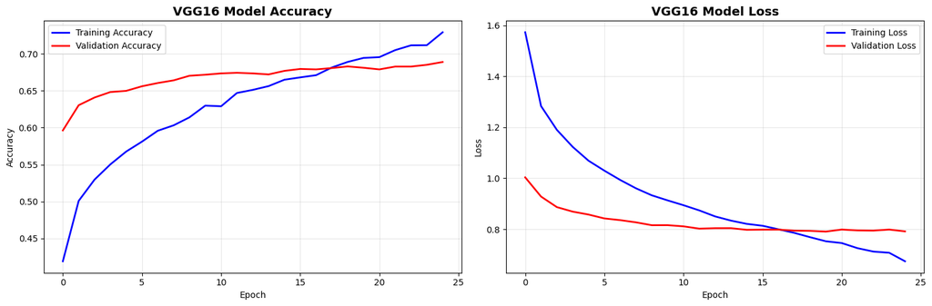

```
VGG16 FINAL TRAINING METRICS:
Training Accuracy: 0.7295 (72.95%)
Validation Accuracy: 0.6892 (68.92%)
```

```python
# Training parameters for VGG16
EPOCHS_VGG = 25

# Defining callbacks for VGG16 training
callbacks_vgg = [
    tf.keras.callbacks.EarlyStopping(
        monitor='val_accuracy',
        patience=7,
        restore_best_weights=True,
        verbose=1,
        mode='max'
    ),
    tf.keras.callbacks.ReduceLROnPlateau(
        monitor='val_loss',
        factor=0.3,
        patience=4,
        min_lr=1e-7,
        verbose=1
    ),
    tf.keras.callbacks.ModelCheckpoint(
        filepath='best_vgg16_emotion_model.keras',
        monitor='val_accuracy',
        save_best_only=True,
        verbose=1,
        mode='max'
    )
]

# Training the VGG16 model
print("Starting VGG16 training...")
print("="*60)

history_vgg16 = vgg16_model.fit(
    train_ds_rgb,
    validation_data=validation_ds_rgb,
    epochs=EPOCHS_VGG,
    callbacks=callbacks_vgg,
    verbose=1
)

print("VGG16 training completed!")

# Plotting Accuracy
fig, (ax1, ax2) = plt.subplots(1, 2, figsize=(15, 5))

ax1.plot(history_vgg16.history['accuracy'], label='Training Accuracy', color='blue', linewidth=2)
ax1.plot(history_vgg16.history['val_accuracy'], label='Validation Accuracy', color='red', linewidth=2)
ax1.set_title('VGG16 Model Accuracy', fontsize=14, fontweight='bold')
ax1.set_xlabel('Epoch')
ax1.set_ylabel('Accuracy')
ax1.legend()
ax1.grid(True, alpha=0.3)
# Plotting loss
ax2.plot(history_vgg16.history['loss'], label='Training Loss', color='blue', linewidth=2)
ax2.plot(history_vgg16.history['val_loss'], label='Validation Loss', color='red', linewidth=2)
ax2.set_title('VGG16 Model Loss', fontsize=14, fontweight='bold')
ax2.set_xlabel('Epoch')
ax2.set_ylabel('Loss')
ax2.legend()
ax2.grid(True, alpha=0.3)

plt.tight_layout()
plt.show()

# Print final metrics
final_train_acc_vgg16 = history_vgg16.history['accuracy'][-1]
final_val_acc_vgg16 = history_vgg16.history['val_accuracy'][-1]

print(f"\nVGG16 FINAL TRAINING METRICS:")
print(f"Training Accuracy: {final_train_acc_vgg16:.4f} ({final_train_acc_vgg16*100:.2f}%)")
print(f"Validation Accuracy: {final_val_acc_vgg16:.4f} ({final_val_acc_vgg16*100:.2f}%)")
```

### **Evaluating the VGG16 model**

```python
# Evaluating VGG16 on test set
print("Evaluating VGG16 on test set...")
print("="*60)

test_loss_vgg16, test_accuracy_vgg16 = vgg16_model.evaluate(test_ds_vgg, verbose=1)

print(f"\nVGG16 TEST RESULTS:")
print(f"Test Loss: {test_loss_vgg16:.4f}")
print(f"Test Accuracy: {test_accuracy_vgg16:.4f} ({test_accuracy_vgg16*100:.2f}%)")

# Generating VGG16 predictions for detailed analysis
test_predictions_vgg16 = vgg16_model.predict(test_ds_vgg)
predicted_classes_vgg16 = tf.argmax(test_predictions_vgg16, axis=1)

# Getting true labels for RGB data
true_labels_rgb = []
for images, labels in test_ds_vgg:
    true_labels_rgb.extend(tf.argmax(labels, axis=1).numpy())

true_labels_rgb = tf.cast(tf.constant(true_labels_rgb), tf.int64)
predicted_classes_vgg16 = tf.cast(predicted_classes_vgg16, tf.int64)

# Per-class accuracy for VGG16
print(f"\nVGG16 Per-class performance:")
print("-" * 45)
class_names = ['happy', 'sad', 'surprise', 'neutral']

for i, class_name in enumerate(class_names):
    class_mask = (true_labels_rgb == i)
    class_predictions = predicted_classes_vgg16[class_mask]
    class_true = true_labels_rgb[class_mask]

    if len(class_true) > 0:
        class_accuracy = tf.reduce_mean(tf.cast(class_predictions == class_true, tf.float32))
        print(f"{class_name.capitalize()}: {class_accuracy:.4f} ({class_accuracy*100:.2f}%)")
# Additional metrics
from sklearn.metrics import classification_report, confusion_matrix
print(f"\nDetailed Classification Report:")
print("-" * 55)
print(classification_report(true_labels_rgb.numpy(), predicted_classes_vgg16.numpy(),
                          target_names=class_names, digits=4))

# Summary of model performance
print(f"\n{'='*60}")
print("SECOND CNN PERFORMANCE SUMMARY")
print(f"{'='*60}")
print(f"Architecture: Larger CNN with 4 Conv Blocks + Double Conv Layers")
print(f"Input: Grayscale images (48x48x1)")
print(f"Test Accuracy: {test_accuracy_vgg16:.4f} ({test_accuracy_vgg16*100:.2f}%)")
print(f"Parameters: More complex than base CNN")
print(f"Training: {len(history_vgg16.history['accuracy'])} epochs")
```

[output not shown]

**Think About It:**

- What do you infer from the general trend in the training performance?
- Is the training accuracy consistently improving?
- Is the validation accuracy also improving similarly?

**Note: You can even go back and build your own architecture on top of the VGG16 Transfer layer and see if you can improve the performance**

## **ResNet V2 Model**

```python
from tensorflow.keras.applications import ResNet50V2
```

### **Model Building**

- Import Resnet v2 upto the layer of your choice and add Fully Connected layers on top of it.

```python
# Creating ResNet V2 model for facial emotion detection
def create_resnet_v2_emotion_model(num_classes=4):
    # Import ResNet50V2 base model (pre-trained on ImageNet)
    resnet_base = ResNet50V2(
        weights='imagenet',
        include_top=False,
        input_shape=(224, 224, 3),
        pooling=None
    )

    # Freezing the base model layers
    resnet_base.trainable = False

    # Building the complete model
    model = Sequential([
        # ResNet V2 base model
        resnet_base,

        # Global Average Pooling
        GlobalAveragePooling2D(name='global_avg_pool'),

        # Custom fully connected layers
        Dense(1024, activation='relu', name='fc1'),
        BatchNormalization(name='bn1'),
        Dropout(0.5, name='dropout1'),

        Dense(512, activation='relu', name='fc2'),
        BatchNormalization(name='bn2'),
        Dropout(0.5, name='dropout2'),

        Dense(256, activation='relu', name='fc3'),
        BatchNormalization(name='bn3'),
        Dropout(0.3, name='dropout3'),

        # Output layer for 4 emotions
        Dense(num_classes, activation='softmax', name='predictions')
    ])

    return model

# Creating the ResNet V2 model
print("Creating ResNet V2 Model for Facial Emotion Detection...")
print("="*60)

resnet_model = create_resnet_v2_emotion_model(num_classes=4)


# Displaying model architecture
print("\nResNet V2 Model Architecture:")
resnet_model.summary()

print("ResNet V2 model created successfully!")
```

```
Creating ResNet V2 Model for Facial Emotion Detection...
============================================================

ResNet V2 Model Architecture:
```

```
Model: "sequential_5"
```

```
┏━━━━━━━━━━━━━━━━━━━━━━━━━━━━━━━━━┳━━━━━━━━━━━━━━━━━━━━━━━━┳━━━━━━━━━━━━━━━┓
┃ Layer (type)                    ┃ Output Shape           ┃       Param # ┃
┡━━━━━━━━━━━━━━━━━━━━━━━━━━━━━━━━━╇━━━━━━━━━━━━━━━━━━━━━━━━╇━━━━━━━━━━━━━━━┩
│ resnet50v2 (Functional)         │ (None, 7, 7, 2048)     │    23,564,800 │
├─────────────────────────────────┼────────────────────────┼───────────────┤
│ global_avg_pool                 │ (None, 2048)           │             0 │
│ (GlobalAveragePooling2D)        │                        │               │
├─────────────────────────────────┼────────────────────────┼───────────────┤
│ fc1 (Dense)                     │ (None, 1024)           │     2,098,176 │
├─────────────────────────────────┼────────────────────────┼───────────────┤
│ bn1 (BatchNormalization)        │ (None, 1024)           │         4,096 │
├─────────────────────────────────┼────────────────────────┼───────────────┤
│ dropout1 (Dropout)              │ (None, 1024)           │             0 │
├─────────────────────────────────┼────────────────────────┼───────────────┤
│ fc2 (Dense)                     │ (None, 512)            │       524,800 │
├─────────────────────────────────┼────────────────────────┼───────────────┤
│ bn2 (BatchNormalization)        │ (None, 512)            │         2,048 │
├─────────────────────────────────┼────────────────────────┼───────────────┤
│ dropout2 (Dropout)              │ (None, 512)            │             0 │
├─────────────────────────────────┼────────────────────────┼───────────────┤
│ fc3 (Dense)                     │ (None, 256)            │       131,328 │
├─────────────────────────────────┼────────────────────────┼───────────────┤
│ bn3 (BatchNormalization)        │ (None, 256)            │         1,024 │
├─────────────────────────────────┼────────────────────────┼───────────────┤
│ dropout3 (Dropout)              │ (None, 256)            │             0 │
├─────────────────────────────────┼────────────────────────┼───────────────┤
│ predictions (Dense)             │ (None, 4)              │         1,028 │
└─────────────────────────────────┴────────────────────────┴───────────────┘
```

```
 Total params: 26,327,300 (100.43 MB)
```

```
 Trainable params: 2,758,916 (10.52 MB)
```

```
 Non-trainable params: 23,568,384 (89.91 MB)
```

```
ResNet V2 model created successfully!
```

### **Compiling and Training the Model**

```
Compiling ResNet V2 Model...
============================================================
ResNet V2 model compiled successfully!

Starting training of ResNet V2 Model...
============================================================
473/473 ━━━━━━━━━━━━━━━━━━━━ 0s 88ms/step - accuracy: 0.3905 - loss: 1.7160
Epoch 1: val_accuracy improved from -inf to 0.59152, saving model to best_resnet_model.h5
473/473 ━━━━━━━━━━━━━━━━━━━━ 79s 130ms/step - accuracy: 0.3906 - loss: 1.7157 - val_accuracy: 0.5915 - val_loss: 1.0327 - learning_rate: 1.0000e-04
472/473 ━━━━━━━━━━━━━━━━━━━━ 0s 73ms/step - accuracy: 0.5345 - loss: 1.2537
Epoch 2: val_accuracy improved from 0.59152 to 0.63854, saving model to best_resnet_model.h5
473/473 ━━━━━━━━━━━━━━━━━━━━ 46s 98ms/step - accuracy: 0.5345 - loss: 1.2536 - val_accuracy: 0.6385 - val_loss: 0.9175 - learning_rate: 1.0000e-04
472/473 ━━━━━━━━━━━━━━━━━━━━ 0s 72ms/step - accuracy: 0.5651 - loss: 1.1222
Epoch 3: val_accuracy improved from 0.63854 to 0.65541, saving model to best_resnet_model.h5
473/473 ━━━━━━━━━━━━━━━━━━━━ 46s 96ms/step - accuracy: 0.5651 - loss: 1.1222 - val_accuracy: 0.6554 - val_loss: 0.8790 - learning_rate: 1.0000e-04
472/473 ━━━━━━━━━━━━━━━━━━━━ 0s 72ms/step - accuracy: 0.5893 - loss: 1.0455
Epoch 4: val_accuracy improved from 0.65541 to 0.66667, saving model to best_resnet_model.h5
473/473 ━━━━━━━━━━━━━━━━━━━━ 46s 97ms/step - accuracy: 0.5893 - loss: 1.0456 - val_accuracy: 0.6667 - val_loss: 0.8446 - learning_rate: 1.0000e-04
472/473 ━━━━━━━━━━━━━━━━━━━━ 0s 72ms/step - accuracy: 0.6138 - loss: 0.9811
Epoch 5: val_accuracy improved from 0.66667 to 0.67089, saving model to best_resnet_model.h5
473/473 ━━━━━━━━━━━━━━━━━━━━ 46s 97ms/step - accuracy: 0.6138 - loss: 0.9811 - val_accuracy: 0.6709 - val_loss: 0.8286 - learning_rate: 1.0000e-04
472/473 ━━━━━━━━━━━━━━━━━━━━ 0s 72ms/step - accuracy: 0.6307 - loss: 0.9267
Epoch 6: val_accuracy improved from 0.67089 to 0.67973, saving model to best_resnet_model.h5
473/473 ━━━━━━━━━━━━━━━━━━━━ 46s 96ms/step - accuracy: 0.6306 - loss: 0.9268 - val_accuracy: 0.6797 - val_loss: 0.8080 - learning_rate: 1.0000e-04
472/473 ━━━━━━━━━━━━━━━━━━━━ 0s 72ms/step - accuracy: 0.6380 - loss: 0.8919
Epoch 7: val_accuracy improved from 0.67973 to 0.69078, saving model to best_resnet_model.h5
473/473 ━━━━━━━━━━━━━━━━━━━━ 46s 96ms/step - accuracy: 0.6380 - loss: 0.8919 - val_accuracy: 0.6908 - val_loss: 0.7862 - learning_rate: 1.0000e-04
472/473 ━━━━━━━━━━━━━━━━━━━━ 0s 72ms/step - accuracy: 0.6587 - loss: 0.8537
Epoch 8: val_accuracy improved from 0.69078 to 0.69218, saving model to best_resnet_model.h5
473/473 ━━━━━━━━━━━━━━━━━━━━ 46s 97ms/step - accuracy: 0.6587 - loss: 0.8538 - val_accuracy: 0.6922 - val_loss: 0.7726 - learning_rate: 1.0000e-04
472/473 ━━━━━━━━━━━━━━━━━━━━ 0s 72ms/step - accuracy: 0.6657 - loss: 0.8322
Epoch 9: val_accuracy improved from 0.69218 to 0.69379, saving model to best_resnet_model.h5
473/473 ━━━━━━━━━━━━━━━━━━━━ 46s 97ms/step - accuracy: 0.6657 - loss: 0.8322 - val_accuracy: 0.6938 - val_loss: 0.7737 - learning_rate: 1.0000e-04
472/473 ━━━━━━━━━━━━━━━━━━━━ 0s 72ms/step - accuracy: 0.6784 - loss: 0.7942
Epoch 10: val_accuracy improved from 0.69379 to 0.69982, saving model to best_resnet_model.h5
473/473 ━━━━━━━━━━━━━━━━━━━━ 46s 97ms/step - accuracy: 0.6784 - loss: 0.7942 - val_accuracy: 0.6998 - val_loss: 0.7622 - learning_rate: 1.0000e-04
472/473 ━━━━━━━━━━━━━━━━━━━━ 0s 72ms/step - accuracy: 0.6890 - loss: 0.7704
Epoch 11: val_accuracy did not improve from 0.69982
473/473 ━━━━━━━━━━━━━━━━━━━━ 45s 95ms/step - accuracy: 0.6890 - loss: 0.7704 - val_accuracy: 0.6996 - val_loss: 0.7616 - learning_rate: 1.0000e-04
472/473 ━━━━━━━━━━━━━━━━━━━━ 0s 72ms/step - accuracy: 0.6934 - loss: 0.7491
```

[output cut: 35 more lines]

```
473/473 ━━━━━━━━━━━━━━━━━━━━ 45s 95ms/step - accuracy: 0.7975 - loss: 0.5136 - val_accuracy: 0.7177 - val_loss: 0.7562 - learning_rate: 2.5000e-05
472/473 ━━━━━━━━━━━━━━━━━━━━ 0s 72ms/step - accuracy: 0.8054 - loss: 0.4932
Epoch 23: val_accuracy improved from 0.72011 to 0.72272, saving model to best_resnet_model.h5
473/473 ━━━━━━━━━━━━━━━━━━━━ 46s 97ms/step - accuracy: 0.8054 - loss: 0.4932 - val_accuracy: 0.7227 - val_loss: 0.7542 - learning_rate: 2.5000e-05
472/473 ━━━━━━━━━━━━━━━━━━━━ 0s 73ms/step - accuracy: 0.8111 - loss: 0.4794
Epoch 24: val_accuracy did not improve from 0.72272
473/473 ━━━━━━━━━━━━━━━━━━━━ 45s 96ms/step - accuracy: 0.8111 - loss: 0.4794 - val_accuracy: 0.7197 - val_loss: 0.7591 - learning_rate: 2.5000e-05
472/473 ━━━━━━━━━━━━━━━━━━━━ 0s 72ms/step - accuracy: 0.8161 - loss: 0.4732
Epoch 25: val_accuracy did not improve from 0.72272

Epoch 25: ReduceLROnPlateau reducing learning rate to 1.249999968422344e-05.
473/473 ━━━━━━━━━━━━━━━━━━━━ 45s 95ms/step - accuracy: 0.8161 - loss: 0.4732 - val_accuracy: 0.7207 - val_loss: 0.7657 - learning_rate: 2.5000e-05
Restoring model weights from the end of the best epoch: 23.

Plotting Training History...
```

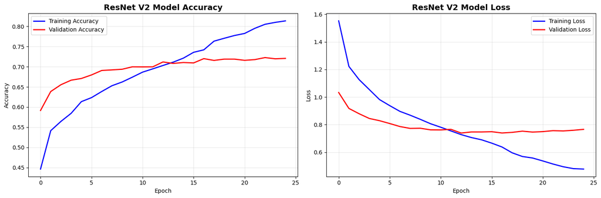

```
RESNET V2 TRAINING COMPLETED!
==================================================
Final Training Accuracy: 0.8138 (81.38%)
Final Validation Accuracy: 0.7207 (72.07%)
```

```python
# Compiling the ResNet V2 model
print("Compiling ResNet V2 Model...")
print("="*60)

resnet_model.compile(
    optimizer=Adam(learning_rate=0.0001),
    loss='categorical_crossentropy',
    metrics=['accuracy']
)

print("ResNet V2 model compiled successfully!")

# Training parameters
EPOCHS = 25
print(f"\nStarting training of ResNet V2 Model...")
print("="*60)

# Defining callbacks for better training
callbacks = [
    tf.keras.callbacks.ModelCheckpoint(
        'best_resnet_model.h5',
        monitor='val_accuracy',
        save_best_only=True,
        save_weights_only=False,
        verbose=1
    ),
    tf.keras.callbacks.EarlyStopping(
        monitor='val_accuracy',
        patience=7,
        restore_best_weights=True,
        verbose=1
    ),
    tf.keras.callbacks.ReduceLROnPlateau(
        monitor='val_loss',
        factor=0.5,
        patience=4,
        min_lr=1e-7,
        verbose=1
    )
]

# Training the ResNet V2 model
history_resnet = resnet_model.fit(
    train_ds_resnet,
    validation_data=validation_ds_resnet,
    epochs=EPOCHS,
    callbacks=callbacks,
    verbose=1
)

# Plotting training history
print("\nPlotting Training History...")
fig, (ax1, ax2) = plt.subplots(1, 2, figsize=(15, 5))

# Plotting accuracy
ax1.plot(history_resnet.history['accuracy'], label='Training Accuracy', color='blue', linewidth=2)
ax1.plot(history_resnet.history['val_accuracy'], label='Validation Accuracy', color='red', linewidth=2)
ax1.set_title('ResNet V2 Model Accuracy', fontsize=14, fontweight='bold')
ax1.set_xlabel('Epoch')
ax1.set_ylabel('Accuracy')
ax1.legend()
ax1.grid(True, alpha=0.3)

# Plotting loss
ax2.plot(history_resnet.history['loss'], label='Training Loss', color='blue', linewidth=2)
ax2.plot(history_resnet.history['val_loss'], label='Validation Loss', color='red', linewidth=2)
ax2.set_title('ResNet V2 Model Loss', fontsize=14, fontweight='bold')
ax2.set_xlabel('Epoch')
ax2.set_ylabel('Loss')
ax2.legend()
ax2.grid(True, alpha=0.3)

plt.tight_layout()
plt.show()

# Printing final training metrics
final_train_acc = history_resnet.history['accuracy'][-1]
final_val_acc = history_resnet.history['val_accuracy'][-1]

print(f"\nRESNET V2 TRAINING COMPLETED!")
print("="*50)
print(f"Final Training Accuracy: {final_train_acc:.4f} ({final_train_acc*100:.2f}%)")
print(f"Final Validation Accuracy: {final_val_acc:.4f} ({final_val_acc*100:.2f}%)")
```

### **Evaluating the ResNet Model**

```python
# Evaluate ResNet V2 on test set
print("Evaluating ResNet V2 on test set...")
print("="*60)
test_loss_resnet, test_accuracy_resnet = resnet_model.evaluate(test_ds_resnet, verbose=1)
print(f"\nRESNET V2 TEST RESULTS:")
print(f"Test Loss: {test_loss_resnet:.4f}")
print(f"Test Accuracy: {test_accuracy_resnet:.4f} ({test_accuracy_resnet*100:.2f}%)")

# Generate ResNet V2 predictions for detailed analysis
test_predictions_resnet = resnet_model.predict(test_ds_resnet)
predicted_classes_resnet = tf.argmax(test_predictions_resnet, axis=1)

# Get true labels for RGB data
true_labels_rgb = []
for images, labels in test_ds_resnet:
    true_labels_rgb.extend(tf.argmax(labels, axis=1).numpy())

true_labels_rgb = tf.cast(tf.constant(true_labels_rgb), tf.int64)
predicted_classes_resnet = tf.cast(predicted_classes_resnet, tf.int64)

# Per-class accuracy for ResNet V2
print(f"\nRESNET V2 Per-class performance:")
print("-" * 45)
class_names = ['happy', 'sad', 'surprise', 'neutral']
for i, class_name in enumerate(class_names):
    class_mask = (true_labels_rgb == i)
    class_predictions = predicted_classes_resnet[class_mask]
    class_true = true_labels_rgb[class_mask]

    if len(class_true) > 0:
        class_accuracy = tf.reduce_mean(tf.cast(class_predictions == class_true, tf.float32))
        print(f"{class_name.capitalize()}: {class_accuracy:.4f} ({class_accuracy*100:.2f}%)")

# Additional metrics
from sklearn.metrics import classification_report, confusion_matrix
print(f"\nDetailed Classification Report:")
print("-" * 55)
print(classification_report(true_labels_rgb.numpy(), predicted_classes_resnet.numpy(),
                          target_names=class_names, digits=4))

# Summary of model performance
print(f"\n{'='*60}")
print("RESNET V2 PERFORMANCE SUMMARY")
print(f"{'='*60}")
print(f"Architecture: ResNet50V2 Transfer Learning")
print(f"Input: RGB images (224x224x3)")
print(f"Test Accuracy: {test_accuracy_resnet:.4f} ({test_accuracy_resnet*100:.2f}%)")
print(f"Parameters: Pre-trained ResNet50V2 + Custom FC layers")
print(f"Training: ResNet V2 model trained epochs")
```

```
Evaluating ResNet V2 on test set...
============================================================
4/4 ━━━━━━━━━━━━━━━━━━━━ 0s 91ms/step - accuracy: 0.7000 - loss: 0.8401

RESNET V2 TEST RESULTS:
Test Loss: 0.7816
Test Accuracy: 0.7109 (71.09%)
4/4 ━━━━━━━━━━━━━━━━━━━━ 5s 81ms/step

RESNET V2 Per-class performance:
---------------------------------------------
Happy: 0.6875 (68.75%)
Sad: 0.6562 (65.62%)
Surprise: 0.8125 (81.25%)
Neutral: 0.6875 (68.75%)

Detailed Classification Report:
-------------------------------------------------------
              precision    recall  f1-score   support

       happy     0.8148    0.6875    0.7458        32
         sad     0.6774    0.6562    0.6667        32
    surprise     0.8387    0.8125    0.8254        32
     neutral     0.5641    0.6875    0.6197        32

    accuracy                         0.7109       128
   macro avg     0.7238    0.7109    0.7144       128
weighted avg     0.7238    0.7109    0.7144       128


============================================================
RESNET V2 PERFORMANCE SUMMARY
============================================================
Architecture: ResNet50V2 Transfer Learning
Input: RGB images (224x224x3)
Test Accuracy: 0.7109 (71.09%)
Parameters: Pre-trained ResNet50V2 + Custom FC layers
Training: ResNet V2 model trained epochs
```

**Observations and Insights:__** 1.) The training accuracy is 81.38% and validation accuracy is 72.07% there is a gap of 9.3%, so there is overfitting 2.)The test accuracy is 71.09% which is very close to validation accuracy which means validation set is reasonably close representative of the test set. 3.)Also indicates the model's generalization capability is stable.

**Note: You can even go back and build your own architecture on top of the ResNet Transfer layer and see if you can improve the performance.**

## **EfficientNet Model**

```python
from tensorflow.keras.applications import EfficientNetB0
```

### **Model Building**

- Import EfficientNet upto the layer of your choice and add Fully Connected layers on top of it.

```python
# Creating EfficientNet Model for Facial Emotion Detection
def create_efficientnet_emotion_model(num_classes=4, dropout_rate=0.4):
    # Importing EfficientNetB0 base model (pretrained on ImageNet)
    efficientnet_base = EfficientNetB0(
        weights='imagenet',
        include_top=False,
        input_shape=(224, 224, 3)
    )

    # Freezing the base model layers for initial training phase
    efficientnet_base.trainable = False

    # Model architecture (lighter head than before for better generalization)
    inputs = tf.keras.Input(shape=(224, 224, 3))

    # Preprocessing inside the model to match EfficientNet training requirements
    x = tf.keras.applications.efficientnet.preprocess_input(inputs)

    # Pass through base model in inference mode while frozen
    x = efficientnet_base(x, training=False)

    # Global average pooling to reduce spatial dimensions
    x = GlobalAveragePooling2D(name='global_avg_pool')(x)

    # Fully connected head
    x = Dense(256, activation='relu', name='fc')(x)
    x = Dropout(dropout_rate, name='dropout')(x)

    # Output layer for emotion classes
    outputs = Dense(num_classes, activation='softmax', name='predictions')(x)

    # Final model
    model = Model(inputs, outputs, name="EfficientNetB0_Emotion")
    return model, efficientnet_base


# Helper function to unfreeze top blocks for fine-tuning
def unfreeze_top_blocks(base_model, blocks=('block6', 'block7'), freeze_batchnorm=True):
    base_model.trainable = True
    for layer in base_model.layers:
        # Only unfreeze layers from specified top blocks
        train_this = any(b in layer.name for b in blocks)
        layer.trainable = train_this
        # Keep BatchNorm frozen to prevent statistics drift
        if freeze_batchnorm and isinstance(layer, tf.keras.layers.BatchNormalization):
            layer.trainable = False


# Create the model
print("Creating EfficientNet Model for Facial Emotion Detection...")
print("="*60)
efficientnet_model, base_model = create_efficientnet_emotion_model(num_classes=4, dropout_rate=0.4)

# Display model architecture
print("\nEfficientNet Model Architecture:")
efficientnet_model.summary()
print("EfficientNet model created successfully!")
```

```
Creating EfficientNet Model for Facial Emotion Detection...
============================================================

EfficientNet Model Architecture:
```

```
Model: "EfficientNetB0_Emotion"
```

```
┏━━━━━━━━━━━━━━━━━━━━━━━━━━━━━━━━━┳━━━━━━━━━━━━━━━━━━━━━━━━┳━━━━━━━━━━━━━━━┓
┃ Layer (type)                    ┃ Output Shape           ┃       Param # ┃
┡━━━━━━━━━━━━━━━━━━━━━━━━━━━━━━━━━╇━━━━━━━━━━━━━━━━━━━━━━━━╇━━━━━━━━━━━━━━━┩
│ input_layer_3 (InputLayer)      │ (None, 224, 224, 3)    │             0 │
├─────────────────────────────────┼────────────────────────┼───────────────┤
│ efficientnetb0 (Functional)     │ (None, 7, 7, 1280)     │     4,049,571 │
├─────────────────────────────────┼────────────────────────┼───────────────┤
│ global_avg_pool                 │ (None, 1280)           │             0 │
│ (GlobalAveragePooling2D)        │                        │               │
├─────────────────────────────────┼────────────────────────┼───────────────┤
│ fc (Dense)                      │ (None, 256)            │       327,936 │
├─────────────────────────────────┼────────────────────────┼───────────────┤
│ dropout (Dropout)               │ (None, 256)            │             0 │
├─────────────────────────────────┼────────────────────────┼───────────────┤
│ predictions (Dense)             │ (None, 4)              │         1,028 │
└─────────────────────────────────┴────────────────────────┴───────────────┘
```

```
 Total params: 4,378,535 (16.70 MB)
```

```
 Trainable params: 328,964 (1.25 MB)
```

```
 Non-trainable params: 4,049,571 (15.45 MB)
```

```
EfficientNet model created successfully!
```

### **Compiling and Training the Model**

```
Compiling EfficientNet Model...
============================================================
EfficientNet model compiled successfully!

Starting training of EfficientNet Model...
============================================================
```

[output not shown]

```
  3/473 ━━━━━━━━━━━━━━━━━━━━ 20s 45ms/step - accuracy: 0.1997 - loss: 1.5268
```

```
I0000 00:00:1755111659.388541     105 device_compiler.h:188] Compiled cluster using XLA!  This line is logged at most once for the lifetime of the process.
```

```
473/473 ━━━━━━━━━━━━━━━━━━━━ 0s 85ms/step - accuracy: 0.4322 - loss: 1.2392
Epoch 1: val_accuracy improved from -inf to 0.63191, saving model to best_efficientnet_model.h5
473/473 ━━━━━━━━━━━━━━━━━━━━ 87s 125ms/step - accuracy: 0.4323 - loss: 1.2390 - val_accuracy: 0.6319 - val_loss: 0.9422 - learning_rate: 1.0000e-04
471/473 ━━━━━━━━━━━━━━━━━━━━ 0s 32ms/step - accuracy: 0.5816 - loss: 0.9898
Epoch 2: val_accuracy improved from 0.63191 to 0.66687, saving model to best_efficientnet_model.h5
473/473 ━━━━━━━━━━━━━━━━━━━━ 20s 43ms/step - accuracy: 0.5816 - loss: 0.9897 - val_accuracy: 0.6669 - val_loss: 0.8656 - learning_rate: 1.0000e-04
471/473 ━━━━━━━━━━━━━━━━━━━━ 0s 31ms/step - accuracy: 0.6269 - loss: 0.9172
Epoch 3: val_accuracy improved from 0.66687 to 0.67812, saving model to best_efficientnet_model.h5
473/473 ━━━━━━━━━━━━━━━━━━━━ 20s 42ms/step - accuracy: 0.6269 - loss: 0.9172 - val_accuracy: 0.6781 - val_loss: 0.8301 - learning_rate: 1.0000e-04
471/473 ━━━━━━━━━━━━━━━━━━━━ 0s 31ms/step - accuracy: 0.6409 - loss: 0.8779
Epoch 4: val_accuracy improved from 0.67812 to 0.68696, saving model to best_efficientnet_model.h5
473/473 ━━━━━━━━━━━━━━━━━━━━ 20s 42ms/step - accuracy: 0.6410 - loss: 0.8779 - val_accuracy: 0.6870 - val_loss: 0.7965 - learning_rate: 1.0000e-04
471/473 ━━━━━━━━━━━━━━━━━━━━ 0s 31ms/step - accuracy: 0.6524 - loss: 0.8511
Epoch 5: val_accuracy improved from 0.68696 to 0.69841, saving model to best_efficientnet_model.h5
473/473 ━━━━━━━━━━━━━━━━━━━━ 20s 42ms/step - accuracy: 0.6524 - loss: 0.8511 - val_accuracy: 0.6984 - val_loss: 0.7835 - learning_rate: 1.0000e-04
471/473 ━━━━━━━━━━━━━━━━━━━━ 0s 31ms/step - accuracy: 0.6695 - loss: 0.8192
Epoch 6: val_accuracy improved from 0.69841 to 0.70042, saving model to best_efficientnet_model.h5
473/473 ━━━━━━━━━━━━━━━━━━━━ 20s 42ms/step - accuracy: 0.6695 - loss: 0.8193 - val_accuracy: 0.7004 - val_loss: 0.7658 - learning_rate: 1.0000e-04
471/473 ━━━━━━━━━━━━━━━━━━━━ 0s 31ms/step - accuracy: 0.6760 - loss: 0.7994
Epoch 7: val_accuracy improved from 0.70042 to 0.70323, saving model to best_efficientnet_model.h5
473/473 ━━━━━━━━━━━━━━━━━━━━ 20s 42ms/step - accuracy: 0.6760 - loss: 0.7994 - val_accuracy: 0.7032 - val_loss: 0.7551 - learning_rate: 1.0000e-04
471/473 ━━━━━━━━━━━━━━━━━━━━ 0s 31ms/step - accuracy: 0.6837 - loss: 0.7823
Epoch 8: val_accuracy improved from 0.70323 to 0.70605, saving model to best_efficientnet_model.h5
473/473 ━━━━━━━━━━━━━━━━━━━━ 20s 42ms/step - accuracy: 0.6837 - loss: 0.7823 - val_accuracy: 0.7060 - val_loss: 0.7461 - learning_rate: 1.0000e-04
471/473 ━━━━━━━━━━━━━━━━━━━━ 0s 31ms/step - accuracy: 0.6927 - loss: 0.7644
Epoch 9: val_accuracy improved from 0.70605 to 0.71067, saving model to best_efficientnet_model.h5
473/473 ━━━━━━━━━━━━━━━━━━━━ 20s 42ms/step - accuracy: 0.6927 - loss: 0.7645 - val_accuracy: 0.7107 - val_loss: 0.7385 - learning_rate: 1.0000e-04
471/473 ━━━━━━━━━━━━━━━━━━━━ 0s 31ms/step - accuracy: 0.6947 - loss: 0.7591
Epoch 10: val_accuracy did not improve from 0.71067
473/473 ━━━━━━━━━━━━━━━━━━━━ 19s 41ms/step - accuracy: 0.6947 - loss: 0.7591 - val_accuracy: 0.7087 - val_loss: 0.7357 - learning_rate: 1.0000e-04
471/473 ━━━━━━━━━━━━━━━━━━━━ 0s 31ms/step - accuracy: 0.7004 - loss: 0.7415
Epoch 11: val_accuracy improved from 0.71067 to 0.71308, saving model to best_efficientnet_model.h5
473/473 ━━━━━━━━━━━━━━━━━━━━ 20s 42ms/step - accuracy: 0.7004 - loss: 0.7416 - val_accuracy: 0.7131 - val_loss: 0.7305 - learning_rate: 1.0000e-04
471/473 ━━━━━━━━━━━━━━━━━━━━ 0s 31ms/step - accuracy: 0.7092 - loss: 0.7312
Epoch 12: val_accuracy improved from 0.71308 to 0.71650, saving model to best_efficientnet_model.h5
473/473 ━━━━━━━━━━━━━━━━━━━━ 20s 42ms/step - accuracy: 0.7092 - loss: 0.7312 - val_accuracy: 0.7165 - val_loss: 0.7202 - learning_rate: 1.0000e-04
471/473 ━━━━━━━━━━━━━━━━━━━━ 0s 31ms/step - accuracy: 0.7144 - loss: 0.7212
Epoch 13: val_accuracy improved from 0.71650 to 0.71810, saving model to best_efficientnet_model.h5
473/473 ━━━━━━━━━━━━━━━━━━━━ 20s 42ms/step - accuracy: 0.7144 - loss: 0.7212 - val_accuracy: 0.7181 - val_loss: 0.7216 - learning_rate: 1.0000e-04
471/473 ━━━━━━━━━━━━━━━━━━━━ 0s 31ms/step - accuracy: 0.7230 - loss: 0.7100
```

[output cut: 23 more lines]

```
471/473 ━━━━━━━━━━━━━━━━━━━━ 0s 31ms/step - accuracy: 0.7470 - loss: 0.6434
Epoch 22: val_accuracy did not improve from 0.72855
473/473 ━━━━━━━━━━━━━━━━━━━━ 19s 41ms/step - accuracy: 0.7470 - loss: 0.6435 - val_accuracy: 0.7284 - val_loss: 0.6925 - learning_rate: 1.0000e-04
471/473 ━━━━━━━━━━━━━━━━━━━━ 0s 31ms/step - accuracy: 0.7510 - loss: 0.6406
Epoch 23: val_accuracy improved from 0.72855 to 0.73096, saving model to best_efficientnet_model.h5
473/473 ━━━━━━━━━━━━━━━━━━━━ 20s 42ms/step - accuracy: 0.7510 - loss: 0.6407 - val_accuracy: 0.7310 - val_loss: 0.6953 - learning_rate: 1.0000e-04
471/473 ━━━━━━━━━━━━━━━━━━━━ 0s 31ms/step - accuracy: 0.7595 - loss: 0.6226
Epoch 24: val_accuracy did not improve from 0.73096
473/473 ━━━━━━━━━━━━━━━━━━━━ 19s 41ms/step - accuracy: 0.7595 - loss: 0.6227 - val_accuracy: 0.7277 - val_loss: 0.6893 - learning_rate: 1.0000e-04
471/473 ━━━━━━━━━━━━━━━━━━━━ 0s 31ms/step - accuracy: 0.7576 - loss: 0.6187
Epoch 25: val_accuracy did not improve from 0.73096
473/473 ━━━━━━━━━━━━━━━━━━━━ 19s 41ms/step - accuracy: 0.7576 - loss: 0.6188 - val_accuracy: 0.7286 - val_loss: 0.6912 - learning_rate: 1.0000e-04
Restoring model weights from the end of the best epoch: 23.

Plotting Training History...
```

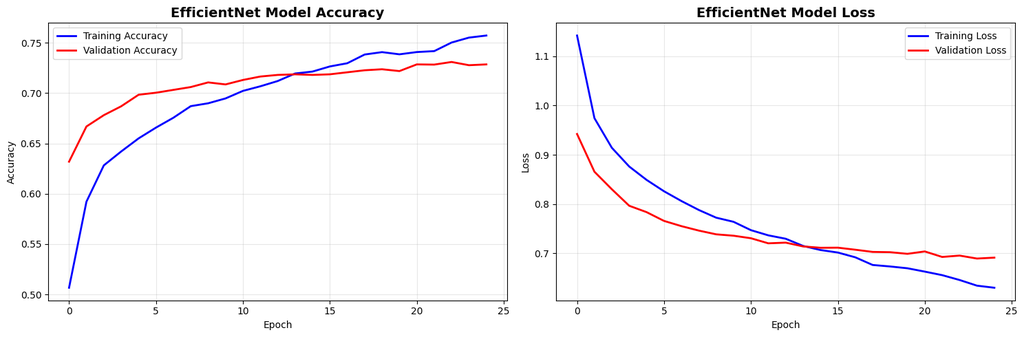

```
EFFICIENTNET TRAINING COMPLETED!
==================================================
Final Training Accuracy: 0.7572 (75.72%)
Final Validation Accuracy: 0.7286 (72.86%)
```

```python
# Compiling the EfficientNet model
print("Compiling EfficientNet Model...")
print("="*60)

efficientnet_model.compile(
    optimizer=Adam(learning_rate=0.0001),
    loss='categorical_crossentropy',
    metrics=['accuracy']
)

print("EfficientNet model compiled successfully!")

# Training parameters
EPOCHS = 25
print(f"\nStarting training of EfficientNet Model...")
print("="*60)

# Defining callbacks for better training
callbacks = [
    tf.keras.callbacks.ModelCheckpoint(
        'best_efficientnet_model.h5',
        monitor='val_accuracy',
        save_best_only=True,
        save_weights_only=False,
        verbose=1
    ),
    tf.keras.callbacks.EarlyStopping(
        monitor='val_accuracy',
        patience=7,
        restore_best_weights=True,
        verbose=1
    ),
    tf.keras.callbacks.ReduceLROnPlateau(
        monitor='val_loss',
        factor=0.5,
        patience=4,
        min_lr=1e-7,
        verbose=1
    )
]

# Training the EfficientNet model
history_efficientnet = efficientnet_model.fit(
    train_ds_efficientnet,
    validation_data=validation_ds_efficientnet,
    epochs=EPOCHS,
    callbacks=callbacks,
    verbose=1
)

# Plotting training history
print("\nPlotting Training History...")
fig, (ax1, ax2) = plt.subplots(1, 2, figsize=(15, 5))

# Plotting accuracy
ax1.plot(history_efficientnet.history['accuracy'], label='Training Accuracy', color='blue', linewidth=2)
ax1.plot(history_efficientnet.history['val_accuracy'], label='Validation Accuracy', color='red', linewidth=2)
ax1.set_title('EfficientNet Model Accuracy', fontsize=14, fontweight='bold')
ax1.set_xlabel('Epoch')
ax1.set_ylabel('Accuracy')
ax1.legend()
ax1.grid(True, alpha=0.3)

# Plotting loss
ax2.plot(history_efficientnet.history['loss'], label='Training Loss', color='blue', linewidth=2)
ax2.plot(history_efficientnet.history['val_loss'], label='Validation Loss', color='red', linewidth=2)
ax2.set_title('EfficientNet Model Loss', fontsize=14, fontweight='bold')
ax2.set_xlabel('Epoch')
ax2.set_ylabel('Loss')
ax2.legend()
ax2.grid(True, alpha=0.3)

plt.tight_layout()
plt.show()

# Printing final training metrics
final_train_acc = history_efficientnet.history['accuracy'][-1]
final_val_acc = history_efficientnet.history['val_accuracy'][-1]

print(f"\nEFFICIENTNET TRAINING COMPLETED!")
print("="*50)
print(f"Final Training Accuracy: {final_train_acc:.4f} ({final_train_acc*100:.2f}%)")
print(f"Final Validation Accuracy: {final_val_acc:.4f} ({final_val_acc*100:.2f}%)")
```

### **Evaluating the EfficientnetNet Model**

```python
# Evaluating EfficientNet on test set
print("Evaluating EfficientNet on test set...")
print("="*60)
test_loss_efficientnet, test_accuracy_efficientnet = efficientnet_model.evaluate(test_ds_efficientnet, verbose=1)
print(f"\nEFFICIENTNET TEST RESULTS:")
print(f"Test Loss: {test_loss_efficientnet:.4f}")
print(f"Test Accuracy: {test_accuracy_efficientnet:.4f} ({test_accuracy_efficientnet*100:.2f}%)")

# Generating EfficientNet predictions for detailed analysis
test_predictions_efficientnet = efficientnet_model.predict(test_ds_efficientnet)
predicted_classes_efficientnet = tf.argmax(test_predictions_efficientnet, axis=1)

# Getting true labels for RGB data
true_labels_rgb = []
for images, labels in test_ds_efficientnet:
    true_labels_rgb.extend(tf.argmax(labels, axis=1).numpy())

true_labels_rgb = tf.cast(tf.constant(true_labels_rgb), tf.int64)
predicted_classes_efficientnet = tf.cast(predicted_classes_efficientnet, tf.int64)

# Per-class accuracy for EfficientNet
print(f"\nEFFICIENTNET Per-class performance:")
print("-" * 45)
class_names = ['happy', 'sad', 'surprise', 'neutral']
for i, class_name in enumerate(class_names):
    class_mask = (true_labels_rgb == i)
    class_predictions = predicted_classes_efficientnet[class_mask]
    class_true = true_labels_rgb[class_mask]

    if len(class_true) > 0:
        class_accuracy = tf.reduce_mean(tf.cast(class_predictions == class_true, tf.float32))
        print(f"{class_name.capitalize()}: {class_accuracy:.4f} ({class_accuracy*100:.2f}%)")

# Additional metrics
from sklearn.metrics import classification_report, confusion_matrix
print(f"\nDetailed Classification Report:")
print("-" * 55)
print(classification_report(true_labels_rgb.numpy(), predicted_classes_efficientnet.numpy(),
                          target_names=class_names, digits=4))

# Summary of model performance
print(f"\n{'='*60}")
print("EFFICIENTNET PERFORMANCE SUMMARY")
print(f"{'='*60}")
print(f"Architecture: EfficientNetB0 Transfer Learning")
print(f"Input: RGB images (224x224x3)")
print(f"Test Accuracy: {test_accuracy_efficientnet:.4f} ({test_accuracy_efficientnet*100:.2f}%)")
print(f"Parameters: Pre-trained EfficientNetB0 + Custom FC layers")
print(f"Training: EfficientNet model trained epochs")
```

```
Evaluating EfficientNet on test set...
============================================================
4/4 ━━━━━━━━━━━━━━━━━━━━ 0s 55ms/step - accuracy: 0.7781 - loss: 0.5804

EFFICIENTNET TEST RESULTS:
Test Loss: 0.6037
Test Accuracy: 0.7734 (77.34%)
4/4 ━━━━━━━━━━━━━━━━━━━━ 7s 42ms/step

EFFICIENTNET Per-class performance:
---------------------------------------------
Happy: 0.8125 (81.25%)
Sad: 0.6875 (68.75%)
Surprise: 0.8438 (84.38%)
Neutral: 0.7500 (75.00%)

Detailed Classification Report:
-------------------------------------------------------
              precision    recall  f1-score   support

       happy     0.7879    0.8125    0.8000        32
         sad     0.7097    0.6875    0.6984        32
    surprise     0.9310    0.8438    0.8852        32
     neutral     0.6857    0.7500    0.7164        32

    accuracy                         0.7734       128
   macro avg     0.7786    0.7734    0.7750       128
weighted avg     0.7786    0.7734    0.7750       128


============================================================
EFFICIENTNET PERFORMANCE SUMMARY
============================================================
Architecture: EfficientNetB0 Transfer Learning
Input: RGB images (224x224x3)
Test Accuracy: 0.7734 (77.34%)
Parameters: Pre-trained EfficientNetB0 + Custom FC layers
Training: EfficientNet model trained epochs
```

**Note: You can even go back and build your own architecture on top of the VGG16 Transfer layer and see if you can improve the performance.**

**Think About It:**

- What is your overall performance of these Transfer Learning Architectures? Can we draw a comparison of these models' performances. Are we satisfied with the accuracies that we have received?
- Do you think our issue lies with 'rgb' color_mode?

Now that we have tried multiple pre-trained models, let's build a complex CNN architecture and see if we can get better performance.

## **Building a Complex Neural Network Architecture**

In this section, we will build a more complex Convolutional Neural Network Model that has close to as many parameters as we had in our Transfer Learning Models. However, we will have only 1 input channel for our input images.

## **Creating our Data Loaders**

In this section, we are creating data loaders which we will use as inputs to the more Complicated Convolutional Neural Network. We will go ahead with color_mode = 'grayscale'.

```python
# Creating Grayscale Data Loaders for More Complicated CNN
print("Creating Grayscale Data Loaders for More Complicated CNN...")
print("="*60)

# Image parameters
IMG_SIZE = (48, 48)  # Keep consistent with previous models
BATCH_SIZE = 32

# Creating grayscale data loaders
train_ds_gray_complex = tf.keras.utils.image_dataset_from_directory(
    directory=f'{base_path}/train',
    labels='inferred',
    label_mode='categorical',
    class_names=['happy', 'sad', 'surprise', 'neutral'],
    color_mode='grayscale',  # Using grayscale as specified
    batch_size=BATCH_SIZE,
    image_size=IMG_SIZE,
    shuffle=True,
    seed=42
)

validation_ds_gray_complex = tf.keras.utils.image_dataset_from_directory(
    directory=f'{base_path}/validation',
    labels='inferred',
    label_mode='categorical',
    class_names=['happy', 'sad', 'surprise', 'neutral'],
    color_mode='grayscale',
    batch_size=BATCH_SIZE,
    image_size=IMG_SIZE,
    shuffle=False,
    seed=42
)

test_ds_gray_complex = tf.keras.utils.image_dataset_from_directory(
    directory=f'{base_path}/test',
    labels='inferred',
    label_mode='categorical',
    class_names=['happy', 'sad', 'surprise', 'neutral'],
    color_mode='grayscale',
    batch_size=BATCH_SIZE,
    image_size=IMG_SIZE,
    shuffle=False,
    seed=42
)

print("Grayscale Data Loaders for Complex CNN Created Successfully!")
print(f"Training batches: {len(train_ds_gray_complex)}")
print(f"Validation batches: {len(validation_ds_gray_complex)}")
print(f"Test batches: {len(test_ds_gray_complex)}")

# Optimizing datasets for performance
train_ds_gray_complex = train_ds_gray_complex.cache().prefetch(tf.data.AUTOTUNE)
validation_ds_gray_complex = validation_ds_gray_complex.cache().prefetch(tf.data.AUTOTUNE)
test_ds_gray_complex = test_ds_gray_complex.cache().prefetch(tf.data.AUTOTUNE)
```

```
Creating Grayscale Data Loaders for More Complicated CNN...
============================================================
Found 15109 files belonging to 4 classes.
Found 4977 files belonging to 4 classes.
Found 128 files belonging to 4 classes.
Grayscale Data Loaders for Complex CNN Created Successfully!
Training batches: 473
Validation batches: 156
Test batches: 4
```

### **Model Building**

- Try building a layer with 5 Convolutional Blocks and see if performance increases.

```python
from tensorflow.keras.regularizers import l2

# Creating a complex CNN model with 5 Convolutional Blocks (reduced overfitting)
def create_complex_cnn(input_shape=(48, 48, 1), num_classes=4, weight_decay=1e-4):
    model = Sequential([
        # Preprocessing layer and normalize to [0,1]
        Rescaling(1./255, input_shape=input_shape),

        # First Convolutional Block
        Conv2D(32, (3, 3), activation='relu', padding='same', kernel_regularizer=l2(weight_decay), name='conv1_1'),
        BatchNormalization(name='bn1_1'),
        Conv2D(32, (3, 3), activation='relu', padding='same', kernel_regularizer=l2(weight_decay), name='conv1_2'),
        BatchNormalization(name='bn1_2'),
        MaxPooling2D((2, 2), name='pool1'),
        Dropout(0.25, name='dropout1'),

        # Second Convolutional Block
        Conv2D(64, (3, 3), activation='relu', padding='same', kernel_regularizer=l2(weight_decay), name='conv2_1'),
        BatchNormalization(name='bn2_1'),
        Conv2D(64, (3, 3), activation='relu', padding='same', kernel_regularizer=l2(weight_decay), name='conv2_2'),
        BatchNormalization(name='bn2_2'),
        MaxPooling2D((2, 2), name='pool2'),
        Dropout(0.3, name='dropout2'),

        # Third Convolutional Block
        Conv2D(128, (3, 3), activation='relu', padding='same', kernel_regularizer=l2(weight_decay), name='conv3_1'),
        BatchNormalization(name='bn3_1'),
        Conv2D(128, (3, 3), activation='relu', padding='same', kernel_regularizer=l2(weight_decay), name='conv3_2'),
        BatchNormalization(name='bn3_2'),
        MaxPooling2D((2, 2), name='pool3'),
        Dropout(0.35, name='dropout3'),

        # Fourth Convolutional Block
        Conv2D(192, (3, 3), activation='relu', padding='same', kernel_regularizer=l2(weight_decay), name='conv4_1'),
        BatchNormalization(name='bn4_1'),
        Conv2D(192, (3, 3), activation='relu', padding='same', kernel_regularizer=l2(weight_decay), name='conv4_2'),
        BatchNormalization(name='bn4_2'),
        MaxPooling2D((2, 2), name='pool4'),
        Dropout(0.4, name='dropout4'),

        # Fifth Convolutional Block
        Conv2D(256, (3, 3), activation='relu', padding='same', kernel_regularizer=l2(weight_decay), name='conv5_1'),
        BatchNormalization(name='bn5_1'),
        Conv2D(256, (3, 3), activation='relu', padding='same', kernel_regularizer=l2(weight_decay), name='conv5_2'),
        BatchNormalization(name='bn5_2'),
        MaxPooling2D((2, 2), name='pool5'),
        Dropout(0.5, name='dropout5'),

        # Global Average Pooling
        GlobalAveragePooling2D(name='global_avg_pool'),

        # Dense head
        Dense(256, activation='relu', kernel_regularizer=l2(weight_decay), name='dense1'),
        BatchNormalization(name='bn_dense1'),
        Dropout(0.5, name='dropout_dense1'),

        # Output layer
        Dense(num_classes, activation='softmax', name='predictions')
    ])

    return model

# Creating the complex CNN model
print("COMPLEX CNN - 5 CONVOLUTIONAL BLOCKS")
print("="*60)
complex_cnn = create_complex_cnn(input_shape=(48, 48, 1), num_classes=4)
# Displaying model architecture
complex_cnn.summary()
print("\nComplex CNN model with 5 convolutional blocks created successfully!")
```

```
COMPLEX CNN - 5 CONVOLUTIONAL BLOCKS
============================================================
```

```
Model: "sequential_3"
```

```
┏━━━━━━━━━━━━━━━━━━━━━━━━━━━━━━━━━┳━━━━━━━━━━━━━━━━━━━━━━━━┳━━━━━━━━━━━━━━━┓
┃ Layer (type)                    ┃ Output Shape           ┃       Param # ┃
┡━━━━━━━━━━━━━━━━━━━━━━━━━━━━━━━━━╇━━━━━━━━━━━━━━━━━━━━━━━━╇━━━━━━━━━━━━━━━┩
│ rescaling_6 (Rescaling)         │ (None, 48, 48, 1)      │             0 │
├─────────────────────────────────┼────────────────────────┼───────────────┤
│ conv1_1 (Conv2D)                │ (None, 48, 48, 32)     │           320 │
├─────────────────────────────────┼────────────────────────┼───────────────┤
│ bn1_1 (BatchNormalization)      │ (None, 48, 48, 32)     │           128 │
├─────────────────────────────────┼────────────────────────┼───────────────┤
│ conv1_2 (Conv2D)                │ (None, 48, 48, 32)     │         9,248 │
├─────────────────────────────────┼────────────────────────┼───────────────┤
│ bn1_2 (BatchNormalization)      │ (None, 48, 48, 32)     │           128 │
├─────────────────────────────────┼────────────────────────┼───────────────┤
│ pool1 (MaxPooling2D)            │ (None, 24, 24, 32)     │             0 │
├─────────────────────────────────┼────────────────────────┼───────────────┤
│ dropout1 (Dropout)              │ (None, 24, 24, 32)     │             0 │
├─────────────────────────────────┼────────────────────────┼───────────────┤
│ conv2_1 (Conv2D)                │ (None, 24, 24, 64)     │        18,496 │
├─────────────────────────────────┼────────────────────────┼───────────────┤
│ bn2_1 (BatchNormalization)      │ (None, 24, 24, 64)     │           256 │
├─────────────────────────────────┼────────────────────────┼───────────────┤
│ conv2_2 (Conv2D)                │ (None, 24, 24, 64)     │        36,928 │
├─────────────────────────────────┼────────────────────────┼───────────────┤
│ bn2_2 (BatchNormalization)      │ (None, 24, 24, 64)     │           256 │
├─────────────────────────────────┼────────────────────────┼───────────────┤
│ pool2 (MaxPooling2D)            │ (None, 12, 12, 64)     │             0 │
├─────────────────────────────────┼────────────────────────┼───────────────┤
│ dropout2 (Dropout)              │ (None, 12, 12, 64)     │             0 │
├─────────────────────────────────┼────────────────────────┼───────────────┤
│ conv3_1 (Conv2D)                │ (None, 12, 12, 128)    │        73,856 │
├─────────────────────────────────┼────────────────────────┼───────────────┤
│ bn3_1 (BatchNormalization)      │ (None, 12, 12, 128)    │           512 │
├─────────────────────────────────┼────────────────────────┼───────────────┤
│ conv3_2 (Conv2D)                │ (None, 12, 12, 128)    │       147,584 │
├─────────────────────────────────┼────────────────────────┼───────────────┤
│ bn3_2 (BatchNormalization)      │ (None, 12, 12, 128)    │           512 │
├─────────────────────────────────┼────────────────────────┼───────────────┤
│ pool3 (MaxPooling2D)            │ (None, 6, 6, 128)      │             0 │
├─────────────────────────────────┼────────────────────────┼───────────────┤
│ dropout3 (Dropout)              │ (None, 6, 6, 128)      │             0 │
```

[output cut: 21 more lines]

```
│ pool5 (MaxPooling2D)            │ (None, 1, 1, 256)      │             0 │
├─────────────────────────────────┼────────────────────────┼───────────────┤
│ dropout5 (Dropout)              │ (None, 1, 1, 256)      │             0 │
├─────────────────────────────────┼────────────────────────┼───────────────┤
│ global_avg_pool                 │ (None, 256)            │             0 │
│ (GlobalAveragePooling2D)        │                        │               │
├─────────────────────────────────┼────────────────────────┼───────────────┤
│ dense1 (Dense)                  │ (None, 256)            │        65,792 │
├─────────────────────────────────┼────────────────────────┼───────────────┤
│ bn_dense1 (BatchNormalization)  │ (None, 256)            │         1,024 │
├─────────────────────────────────┼────────────────────────┼───────────────┤
│ dropout_dense1 (Dropout)        │ (None, 256)            │             0 │
├─────────────────────────────────┼────────────────────────┼───────────────┤
│ predictions (Dense)             │ (None, 4)              │         1,028 │
└─────────────────────────────────┴────────────────────────┴───────────────┘
```

```
 Total params: 1,945,700 (7.42 MB)
```

```
 Trainable params: 1,942,500 (7.41 MB)
```

```
 Non-trainable params: 3,200 (12.50 KB)
```

```
Complex CNN model with 5 convolutional blocks created successfully!
```

### **Compiling and Training the Model**

```
Compiling Complex CNN Model...
============================================================
Complex CNN model compiled successfully!

Starting training of Complex CNN Model...
============================================================
473/473 ━━━━━━━━━━━━━━━━━━━━ 0s 31ms/step - accuracy: 0.2741 - loss: 2.3609
Epoch 1: val_accuracy improved from -inf to 0.23689, saving model to best_complex_cnn.h5
473/473 ━━━━━━━━━━━━━━━━━━━━ 41s 43ms/step - accuracy: 0.2741 - loss: 2.3607 - val_accuracy: 0.2369 - val_loss: 1.6516 - learning_rate: 1.0000e-04
471/473 ━━━━━━━━━━━━━━━━━━━━ 0s 12ms/step - accuracy: 0.2901 - loss: 2.0721
Epoch 2: val_accuracy improved from 0.23689 to 0.27808, saving model to best_complex_cnn.h5
473/473 ━━━━━━━━━━━━━━━━━━━━ 6s 14ms/step - accuracy: 0.2901 - loss: 2.0719 - val_accuracy: 0.2781 - val_loss: 1.5272 - learning_rate: 1.0000e-04
470/473 ━━━━━━━━━━━━━━━━━━━━ 0s 12ms/step - accuracy: 0.3064 - loss: 1.9196
Epoch 3: val_accuracy improved from 0.27808 to 0.36287, saving model to best_complex_cnn.h5
473/473 ━━━━━━━━━━━━━━━━━━━━ 6s 14ms/step - accuracy: 0.3064 - loss: 1.9195 - val_accuracy: 0.3629 - val_loss: 1.5107 - learning_rate: 1.0000e-04
473/473 ━━━━━━━━━━━━━━━━━━━━ 0s 12ms/step - accuracy: 0.3110 - loss: 1.8155
Epoch 4: val_accuracy did not improve from 0.36287
473/473 ━━━━━━━━━━━━━━━━━━━━ 6s 13ms/step - accuracy: 0.3110 - loss: 1.8155 - val_accuracy: 0.3414 - val_loss: 1.5294 - learning_rate: 1.0000e-04
471/473 ━━━━━━━━━━━━━━━━━━━━ 0s 12ms/step - accuracy: 0.3274 - loss: 1.7344
Epoch 5: val_accuracy did not improve from 0.36287
473/473 ━━━━━━━━━━━━━━━━━━━━ 6s 13ms/step - accuracy: 0.3274 - loss: 1.7342 - val_accuracy: 0.3607 - val_loss: 1.5251 - learning_rate: 1.0000e-04
469/473 ━━━━━━━━━━━━━━━━━━━━ 0s 12ms/step - accuracy: 0.3640 - loss: 1.6286
Epoch 6: val_accuracy improved from 0.36287 to 0.44465, saving model to best_complex_cnn.h5
473/473 ━━━━━━━━━━━━━━━━━━━━ 6s 14ms/step - accuracy: 0.3641 - loss: 1.6284 - val_accuracy: 0.4446 - val_loss: 1.4355 - learning_rate: 1.0000e-04
470/473 ━━━━━━━━━━━━━━━━━━━━ 0s 12ms/step - accuracy: 0.4009 - loss: 1.5132
Epoch 7: val_accuracy improved from 0.44465 to 0.45349, saving model to best_complex_cnn.h5
473/473 ━━━━━━━━━━━━━━━━━━━━ 6s 13ms/step - accuracy: 0.4010 - loss: 1.5131 - val_accuracy: 0.4535 - val_loss: 1.4749 - learning_rate: 1.0000e-04
471/473 ━━━━━━━━━━━━━━━━━━━━ 0s 12ms/step - accuracy: 0.4540 - loss: 1.4202
Epoch 8: val_accuracy improved from 0.45349 to 0.52059, saving model to best_complex_cnn.h5
473/473 ━━━━━━━━━━━━━━━━━━━━ 6s 13ms/step - accuracy: 0.4540 - loss: 1.4201 - val_accuracy: 0.5206 - val_loss: 1.2698 - learning_rate: 1.0000e-04
469/473 ━━━━━━━━━━━━━━━━━━━━ 0s 12ms/step - accuracy: 0.4954 - loss: 1.3217
Epoch 9: val_accuracy improved from 0.52059 to 0.55556, saving model to best_complex_cnn.h5
473/473 ━━━━━━━━━━━━━━━━━━━━ 6s 14ms/step - accuracy: 0.4955 - loss: 1.3216 - val_accuracy: 0.5556 - val_loss: 1.2015 - learning_rate: 1.0000e-04
471/473 ━━━━━━━━━━━━━━━━━━━━ 0s 12ms/step - accuracy: 0.5169 - loss: 1.2549
Epoch 10: val_accuracy improved from 0.55556 to 0.59373, saving model to best_complex_cnn.h5
473/473 ━━━━━━━━━━━━━━━━━━━━ 6s 14ms/step - accuracy: 0.5169 - loss: 1.2549 - val_accuracy: 0.5937 - val_loss: 1.1208 - learning_rate: 1.0000e-04
471/473 ━━━━━━━━━━━━━━━━━━━━ 0s 12ms/step - accuracy: 0.5440 - loss: 1.2105
Epoch 11: val_accuracy improved from 0.59373 to 0.61885, saving model to best_complex_cnn.h5
473/473 ━━━━━━━━━━━━━━━━━━━━ 6s 13ms/step - accuracy: 0.5440 - loss: 1.2104 - val_accuracy: 0.6188 - val_loss: 1.0563 - learning_rate: 1.0000e-04
471/473 ━━━━━━━━━━━━━━━━━━━━ 0s 12ms/step - accuracy: 0.5672 - loss: 1.1501
```

[output cut: 44 more lines]

```
471/473 ━━━━━━━━━━━━━━━━━━━━ 0s 12ms/step - accuracy: 0.7449 - loss: 0.7782
Epoch 27: val_accuracy did not improve from 0.74704
473/473 ━━━━━━━━━━━━━━━━━━━━ 6s 13ms/step - accuracy: 0.7449 - loss: 0.7783 - val_accuracy: 0.7394 - val_loss: 0.8246 - learning_rate: 1.0000e-04
470/473 ━━━━━━━━━━━━━━━━━━━━ 0s 12ms/step - accuracy: 0.7536 - loss: 0.7678
Epoch 28: val_accuracy improved from 0.74704 to 0.75990, saving model to best_complex_cnn.h5
473/473 ━━━━━━━━━━━━━━━━━━━━ 6s 14ms/step - accuracy: 0.7536 - loss: 0.7678 - val_accuracy: 0.7599 - val_loss: 0.7739 - learning_rate: 1.0000e-04
471/473 ━━━━━━━━━━━━━━━━━━━━ 0s 12ms/step - accuracy: 0.7580 - loss: 0.7493
Epoch 29: val_accuracy did not improve from 0.75990
473/473 ━━━━━━━━━━━━━━━━━━━━ 6s 13ms/step - accuracy: 0.7580 - loss: 0.7493 - val_accuracy: 0.7533 - val_loss: 0.7874 - learning_rate: 1.0000e-04
471/473 ━━━━━━━━━━━━━━━━━━━━ 0s 12ms/step - accuracy: 0.7671 - loss: 0.7197
Epoch 30: val_accuracy did not improve from 0.75990
473/473 ━━━━━━━━━━━━━━━━━━━━ 6s 13ms/step - accuracy: 0.7671 - loss: 0.7197 - val_accuracy: 0.7468 - val_loss: 0.8089 - learning_rate: 1.0000e-04
Restoring model weights from the end of the best epoch: 28.

Plotting Training History...
```

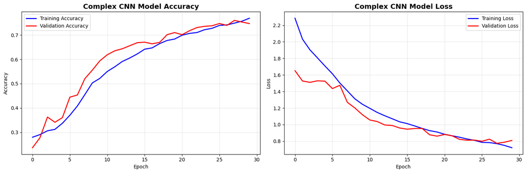

```
 COMPLEX CNN TRAINING COMPLETED!
==================================================
Final Training Accuracy: 0.7687 (76.87%)
Final Validation Accuracy: 0.7468 (74.68%)
```

```python
# Compiling the Complex CNN model
print("Compiling Complex CNN Model...")
print("="*60)

complex_cnn.compile(
    optimizer=Adam(learning_rate=0.0001),  # Lower learning rate for complex model
    loss='categorical_crossentropy',
    metrics=['accuracy']
)

print("Complex CNN model compiled successfully!")

# Training parameters
EPOCHS = 30  # More epochs for complex model
print(f"\nStarting training of Complex CNN Model...")
print("="*60)

# Defining callbacks for better training
callbacks = [
    tf.keras.callbacks.ModelCheckpoint(
        'best_complex_cnn.h5',
        monitor='val_accuracy',
        save_best_only=True,
        save_weights_only=False,
        verbose=1
    ),
    tf.keras.callbacks.EarlyStopping(
        monitor='val_accuracy',
        patience=10,  # More patience for complex model
        restore_best_weights=True,
        verbose=1
    ),
    tf.keras.callbacks.ReduceLROnPlateau(
        monitor='val_loss',
        factor=0.5,
        patience=5,
        min_lr=1e-8,
        verbose=1
    )
]

# Training the Complex CNN model
history_complex = complex_cnn.fit(
    train_ds_gray_complex,
    validation_data=validation_ds_gray_complex,
    epochs=EPOCHS,
    callbacks=callbacks,
    verbose=1
)

# Plotting training history
print("\nPlotting Training History...")
fig, (ax1, ax2) = plt.subplots(1, 2, figsize=(15, 5))

# Plotting accuracy
ax1.plot(history_complex.history['accuracy'], label='Training Accuracy', color='blue', linewidth=2)
ax1.plot(history_complex.history['val_accuracy'], label='Validation Accuracy', color='red', linewidth=2)
ax1.set_title('Complex CNN Model Accuracy', fontsize=14, fontweight='bold')
ax1.set_xlabel('Epoch')
ax1.set_ylabel('Accuracy')
ax1.legend()
ax1.grid(True, alpha=0.3)

# Plotting loss
ax2.plot(history_complex.history['loss'], label='Training Loss', color='blue', linewidth=2)
ax2.plot(history_complex.history['val_loss'], label='Validation Loss', color='red', linewidth=2)
ax2.set_title('Complex CNN Model Loss', fontsize=14, fontweight='bold')
ax2.set_xlabel('Epoch')
ax2.set_ylabel('Loss')
ax2.legend()
ax2.grid(True, alpha=0.3)

plt.tight_layout()
plt.show()

# Printing final training metrics
final_train_acc = history_complex.history['accuracy'][-1]
final_val_acc = history_complex.history['val_accuracy'][-1]

print(f"\n COMPLEX CNN TRAINING COMPLETED!")
print("="*50)
print(f"Final Training Accuracy: {final_train_acc:.4f} ({final_train_acc*100:.2f}%)")
print(f"Final Validation Accuracy: {final_val_acc:.4f} ({final_val_acc*100:.2f}%)")
```

### **Evaluating the Model on Test Set**

```python
# Evaluating Complex CNN on test set
print("Evaluating Complex CNN on test set...")
print("="*60)

test_loss_complex, test_accuracy_complex = complex_cnn.evaluate(test_ds_gray_complex, verbose=1)
print(f"\nCOMPLEX CNN TEST RESULTS:")
print(f"Test Loss: {test_loss_complex:.4f}")
print(f"Test Accuracy: {test_accuracy_complex:.4f} ({test_accuracy_complex*100:.2f}%)")

# Generating Complex CNN predictions for detailed analysis
test_predictions_complex = complex_cnn.predict(test_ds_gray_complex)
predicted_classes_complex = tf.argmax(test_predictions_complex, axis=1)

# Getting true labels for grayscale data
true_labels_gray = []
for images, labels in test_ds_gray_complex:
    true_labels_gray.extend(tf.argmax(labels, axis=1).numpy())

true_labels_gray = tf.cast(tf.constant(true_labels_gray), tf.int64)
predicted_classes_complex = tf.cast(predicted_classes_complex, tf.int64)

# Per-class accuracy for Complex CNN
print(f"\nCOMPLEX CNN Per-class performance:")
print("-" * 45)
class_names = ['happy', 'sad', 'surprise', 'neutral']
for i, class_name in enumerate(class_names):
    class_mask = (true_labels_gray == i)
    class_predictions = predicted_classes_complex[class_mask]
    class_true = true_labels_gray[class_mask]

    if len(class_true) > 0:
        class_accuracy = tf.reduce_mean(tf.cast(class_predictions == class_true, tf.float32))
        print(f"{class_name.capitalize()}: {class_accuracy:.4f} ({class_accuracy*100:.2f}%)")

# Additional metrics
from sklearn.metrics import classification_report, confusion_matrix
print(f"\nDetailed Classification Report:")
print("-" * 55)
print(classification_report(true_labels_gray.numpy(), predicted_classes_complex.numpy(),
                          target_names=class_names, digits=4))

# Summary of model performance
print(f"\n{'='*60}")
print("COMPLEX CNN PERFORMANCE SUMMARY")
print(f"{'='*60}")
print(f"Architecture: Complex CNN with 5 Convolutional Blocks")
print(f"Input: Grayscale images (48x48x1)")
print(f"Test Accuracy: {test_accuracy_complex:.4f} ({test_accuracy_complex*100:.2f}%)")
print(f"Parameters: {complex_cnn.count_params():,} (comparable to transfer learning models)")
print(f"Training: {len(history_complex.history['accuracy'])} epochs")
```

```
Evaluating Complex CNN on test set...
============================================================
4/4 ━━━━━━━━━━━━━━━━━━━━ 0s 8ms/step - accuracy: 0.7812 - loss: 0.7619

COMPLEX CNN TEST RESULTS:
Test Loss: 0.7904
Test Accuracy: 0.7656 (76.56%)
4/4 ━━━━━━━━━━━━━━━━━━━━ 1s 7ms/step

COMPLEX CNN Per-class performance:
---------------------------------------------
Happy: 0.8125 (81.25%)
Sad: 0.7500 (75.00%)
Surprise: 0.7812 (78.12%)
Neutral: 0.7188 (71.88%)

Detailed Classification Report:
-------------------------------------------------------
              precision    recall  f1-score   support

       happy     0.7879    0.8125    0.8000        32
         sad     0.7059    0.7500    0.7273        32
    surprise     0.9259    0.7812    0.8475        32
     neutral     0.6765    0.7188    0.6970        32

    accuracy                         0.7656       128
   macro avg     0.7740    0.7656    0.7679       128
weighted avg     0.7740    0.7656    0.7679       128


============================================================
COMPLEX CNN PERFORMANCE SUMMARY
============================================================
Architecture: Complex CNN with 5 Convolutional Blocks
Input: Grayscale images (48x48x1)
Test Accuracy: 0.7656 (76.56%)
Parameters: 1,945,700 (comparable to transfer learning models)
Training: 30 epochs
```

**Observations and Insights:__** 1.) The training accuracy is 76.87% while the validaion accuracy is 74.68% meaning there is almost no overfitting which is good and the model is good at finding patterns in data. 2.)the test accuacy in 76.56% which is near the validation accuracy which suggests both splits are resonably representitive. 3.) This is a very robust model.

### **Plotting the Confusion Matrix for the chosen final model**

```
Confusion Matrix (counts):
-------------------------------------------------------
[[26  1  2  3]
 [ 2 24  0  6]
 [ 3  2 25  2]
 [ 2  7  0 23]]

Confusion Matrix (row-normalized):
-------------------------------------------------------
[[0.812 0.031 0.062 0.094]
 [0.062 0.75  0.    0.188]
 [0.094 0.062 0.781 0.062]
 [0.062 0.219 0.    0.719]]
```

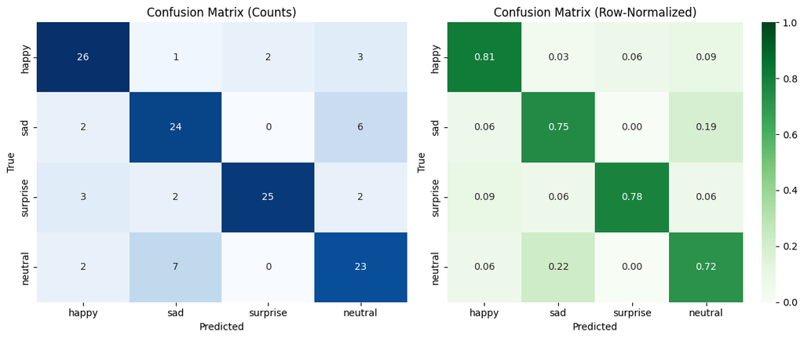

```python
# Ensure predicted and true labels are numpy arrays
y_true = true_labels_gray.numpy()
y_pred = predicted_classes_complex.numpy()
labels = list(range(len(class_names)))  # [0, 1, 2, 3]

# 1) Compute confusion matrix
cm = confusion_matrix(y_true, y_pred, labels=labels)

print("\nConfusion Matrix (counts):")
print("-" * 55)
print(cm)

# 2) Normalize by true class (row-wise) for readability
cm_norm = cm.astype('float') / cm.sum(axis=1, keepdims=True)
cm_norm = np.nan_to_num(cm_norm)  # handle division by zero if any class absent

print("\nConfusion Matrix (row-normalized):")
print("-" * 55)
np.set_printoptions(precision=3, suppress=True)
print(cm_norm)

# 3) Plot heatmaps (counts and normalized)
fig, axes = plt.subplots(1, 2, figsize=(12, 5))

sns.heatmap(cm, annot=True, fmt='d', cmap='Blues', cbar=False,
            xticklabels=class_names, yticklabels=class_names, ax=axes[0])
axes[0].set_title('Confusion Matrix (Counts)')
axes[0].set_xlabel('Predicted')
axes[0].set_ylabel('True')

sns.heatmap(cm_norm, annot=True, fmt='.2f', cmap='Greens', cbar=True,
            xticklabels=class_names, yticklabels=class_names, ax=axes[1], vmin=0, vmax=1)
axes[1].set_title('Confusion Matrix (Row-Normalized)')
axes[1].set_xlabel('Predicted')
axes[1].set_ylabel('True')

plt.tight_layout()
plt.show()
```

**Observations and Insights:__** 1.)Sad and neutral are the expressions that are most difficult to differentiate, since when we even look at the example pictures there is less difference there than other picture. 2.)rest out of 32 samples for each we are getting good amount of recognition.

## **Conclusion:____________**

The complex CNN with 5 convolutional block with training accuracy 76.87% and validaion accuracy 74.68% is giving the best robust and generalize performace with almost no overfitting, So that is the most generalized and robust model with the best chances to predict unscene data. It also has the least per class disrepancy so it is good on the test data with an accuracy of 76.56%

Since the test data split is very less 0.6% the main reason for chosing this model is that it is the most generalized and robust.

### **Refined insights**:

- What are the most meaningful insights from the data relevant to the problem? The data shows that it is generalized enough though the test data split is very small to consider it in choosing a model. The happy and surprise faces have very distinct feature but identifying sad and neutral is a bit difficult so maybe more data on them would have helped

### **Comparison of various techniques and their relative performance**:

- How do different techniques perform? Which one is performing relatively better? Is there scope to improve the performance further?
- The different techniques are all giving different results with various amounts of bias and variance. the complex CNN with 5 convolutional blocks is peerforming the best.yes there maybe scope to improve the performance better since I have done that by creating and experimenting with models but with the available datraset there is not a very large scope.

### **Proposal for the final solution design**:

- What model do you propose to be adopted? Why is this the best solution to adopt?
- The complex CNN with 5 convolutional block with training accuracy 76.87% and validaion accuracy 74.68% is giving the best robust and generalize performace with almost no overfitting, So that is the most generalized and robust model with the best chances to predict unscene data. It also has the least per class disrepancy so it is good on the test data with an accuracy of 76.56%

Since the test data split is very less 0.6% the main reason for chosing this model is that it is the most generalized and robust.

### **(A) What are the most important findings from the analysis done in Milestone**

- 1.) The CNN's were a better choice than ANN for this project since they maintain 2d structure of the images, can learn hierarchical features (edges, shapes, objects) without manual engineering and focus on nearby pixel regions rather than connecting every neuron.
- 2.)After seeing the perdormance metric of all the models created for this project it can be clearly seen that model selection can't be done just based on the Test accuracy percentage, since her in are dataset we have a very small split on test dataset, only 0.6% so it can not tell much about the model, rather the training and validation accuracy tell more about how good and generalized the model can be, So while chossing the model, we also have to look at the dataset splits between test, train and validation
- 3.)If we use the Graycale data loader for a pretty simple CNN or even a little more complex we get higher accuracy but also more overfitting, implying the we may need more data, especially with complex architecture, while the rgb data loader provide less accuracy but also limitted over fitting since we have less relecvant color information. -4)The transfer learning architectures give us an easier way to configure a CNN model, though it does not necessarily mean that they will give better results than the CNN model's that can be created manually. -5) while choosing a model we have to see accuracy values the give the least overfitting or underfitting while giving accuracy in ate least above or very close to 75% to get the best model.

### **Problem and solution summary**

### **(A) Summary of the problem**

- we are given a dataset of human face immages with 4 expression happy, sad, surprised and neytral, we have to use DeepLearning andArtificial Intelligence techniques to create a computer vision model that can accurately detect these facial emotions

### **(B)Explain the reason for the proposed solution design**

- The proposed solution design was used for the following reasons :
- 1.Hierarchical Feature Learning for Facial Expressions
- The 5-block progressive architecture (32→64→128→192→256 filters) perfectly aligns with how facial emotions are structured:
- Early blocks will capture basic facial features (edges, textures, facial contours)
- Deeper blocks will learn complex emotion-specific patterns (smile curves, frown lines, eye crinkles)- Middle blocks detect facial components (eyes, mouth, eyebrows) -2. we are optimizung input size for bet results
- The 48×48×1 input shape is specifically chosen for facial emotion recognition:
- Grayscale processing will focus on facial structure rather than skin color variations
- and it will be computationally efficient while preserving essential facial details -3. we are using a Multi-Layer Regularization Strategy
- Given that facial emotion datasets are typically small and prone to overfitting, this model has:
- L2 regularization (1e-4) on all trainable layers
- Progressive dropout (0.25→0.50) - increases with network depth
- Batch normalization after every layer for stable training
- Global Average Pooling instead of flatten to reduce parameters dramatically
- 4. we are using preprocessing methods so as to provide seamless real world integration
- The model has Built-in rescaling (1/255) handles raw image inputs directly
- The Standardized input format used is compatible with webcam/image capture systems
- Efficient inference suitable for real-time emotion detection applications

### **(C)How it would affect the problem/business?**

- The proposed CNN model addresses the critical need for emotionally intelligent AI by accurately detecting facial emotions in real-time, enabling machines to interpret 55% of human communication that occurs through facial expressions.
- It has applications in various fields like :
- Customer service optimization (chatbots, virtual assistants) : by detecting the emotion on the customers face, we can optimize the response of the chatbots or virtual assistants based on the customer's mood.
- Mental health monitoring and therapy support : by detecting the emotion on the patient's face in an initial assessment , the therapist/doctor can get a quick idea of the patients mood before the patient even meets with them
- Retail intelligence and marketing campaign optimization : each markieting campaign or new retail products can get a real time feddback based on the people's emotion to better change both,
- Quality assurance in human-computer interactions : it will just generally improve human and computer conversations to make them more life like.

### **Recommendations for implementation**

### **(A)What are some key recommendations to implement the solutions?**

- need to do a pilot deployment with small dataset validation before full rollout, we need to Start small to minimize risk and validate accuracy before scaling to big projects and infrastructures
- need to setup a cloud-native infrastructure with auto-scaling and edge computing for real-time processing, This will Ensure that the system can handle varying loads while maintaining sub-second response times
- Integration with existing systems(CRM, customer service platforms) should be done in phases, since Gradual rollout prevents business disruption and allows for iterative improvements -Staff training programs for interpreting emotion insights will need to be created, since Human expertise is essential to translate AI insights into actionable business decisions
- Robust data pipeline with privacy compliance (GDPR, HIPAA) will need to be created, since Data quality and regulatory compliance are non-negotiable for sustainable deployment

### **(B)What are the key actionables for stakeholders? What is the expected benefit and/or costs?**

- The key actionable items for various stake holders would be :
- For the Technical Team: They need to work on Model optimization, API development, security implementation and the Benefits from tech team would be: Significant cost savings through automation, high accuracy emotion detection, substantially faster processing than manual methods
- for the Business Team: they need to identify pilot customers, develop pricing models based on market standards, create go-to-market strategy Benefits from business team would be : Multi-million revenue potential, meaningful customer satisfaction improvement, competitive market positioning
- for Privacy Team: a very important step for an such project rollout is Data governance, compliance audits, consent management. Costs involved would be: Moderate initial setup investment, ongoing annual compliance maintenance expenses
- for achieving Customer Success: we need to create emotion-based journey mapping, response protocols, and give team trainings to handle customer greviance. The Benefit6s would be : Notable churn reduction, improved first-call resolution rates, enhanced customer experience quality

### **(C)What are the key risks and challenges?**

- Technical Risks Model bias across demographics: CNN may perform inconsistently across different age groups, ethnicities, and genders, leading to different outcomes Environmental variations: Lighting conditions, camera angles, and image quality can significantly impact model accuracy and reliability Real-time performance issues: High computational demands may cause latency problems during peak usage, affecting user experience
- Business Risks Privacy concerns: Facial data collection raises serious privacy implications and potential regulatory scrutiny over surveillance Customer acceptance: Users may resist emotion monitoring technology due to perceived invasiveness or cultural differences Integration complexity: Legacy systems may require expensive custom development for compatibility with emotion AI Competition from tech giants: Large companies have superior resources and market presence, making competition difficult
- Operational Challenges Data quality management: Inconsistent image quality and dataset availability require continuous monitoring and validation processes Scalability bottlenecks: System architecture may struggle under high concurrent loads, requiring expensive infrastructure upgrades False positives affecting customer experience: Misidentified emotions could trigger inappropriate responses, damaging customer relationships
- Financial Risks High infrastructure costs: Cloud computing and processing requirements for real-time detection can be substantial during scaling Ongoing computational expenses: Continuous inference, storage, and maintenance create recurring costs that may exceed early revenue Potential litigation costs: Privacy violations or discrimination claims could result in expensive legal battles and fines

### **(D)What further analysis needs to be done or what other associated problems need to be solved?**

- Additional Analysis Needed Cross-cultural emotion validation studies: The model accuracy need to be tested across different cultural backgrounds since emotional expressions vary significantly between cultures (e.g., smiling frequency, eye contact patterns), ensuring global applicability ROI modeling for different industries: industry-specific business cases need to be devloped for industries like healthcare, retail, education, or finance to quantify value proposition and justify investment for each sector Competitive landscape analysis: we need to map existing emotion AI solutions, pricing strategies, and market positioning to identify differentiation opportunities and potential partnership or acquisition targets Edge case testing for unusual expressions: need to validate performance on medical conditions affecting facial expressions, extreme emotions, partial face coverage, and non-standard facial features to ensure robust real-world deployment
- Associated Problems to Solve Multi-modal emotion recognition (voice + facial): we can Integrate audio sentiment analysis with facial detection to improve accuracy and handle scenarios where visual data alone is insufficient or ambiguous Algorithmic fairness across demographic groups: we need Implement bias detection and mitigation strategies to ensure equal performance across age, gender, ethnicity, and disability status while maintaining overall accuracy Legacy system integration challenges: need to Develop standardized APIs, data format converters, and middleware solutions to enable seamless integration with existing CRM, customer service, and analytics platforms Real-time personalized emotion baselines: need to Create individual user profiles that account for personal emotional expression patterns, cultural background, and baseline expressions to improve accuracy for repeat interactions